# FDA Project - Walmart Store Sales Forecasting

17MIS1137 | 17MIS1194

# **INTRODUCTION**

## Objectives

- To perform exploratory analysis on the dataset
- To build a time series model
- To Predict the department-wide-sales for each store

## Dataset description

The Kaggle dataset contains historical sales data for 45 Walmart stores located in different regions. Each store contains a number of departments, and we have to predict the department-wide sales for each store.The datasets included information about :

- **train** dataset
  - *Store* - the store number
  - *Dept* - the department number
  - *Date* - the week
  - *Weekly_Sales* - sales for the given department in the given store and department
  - *IsHoliday* - whether the week was a special holiday week

Additional data related to the store, department, and regional promotional activity for the given dates were available in the dataset *features*. The variables included in this dataset are shown below.

- **features** dataset
  - *Store* - the store number
  - *Date* - the week
  - *Temperature*- average temperature in the region
  - *Fuel Price* - cost of fuel in the region
  - *MarkDown 1-5* - anonymised data related to promotional markdowns that Walmart was running
  - *CPI* - consumer price index
  - *Unemployment* - the unemployment rate
  - *IsHoliday* - whether the week was a special holiday week

Anonymised information about the 45 stores, indicating the type and size of store, were also available in the dataset *stores*.

- **stores** dataset
  - *Store* - the store number
  - *Type* - type of the store (A, B, C)
  - *Size* - size of the store

### Installing the packages and dependencies

```r
library(timeDate)
library(randomForest)
library(ggplot2)
library(reshape2)
library(dplyr)
library(magrittr)
library(fpp)
library(rlist)
library(tidyverse)
```

### Importing Dataset

```r
stores <- read.csv("./Dataset/stores.csv")
features <- read.csv("./Dataset/features.csv")
train <- read.csv("./Dataset/train.csv")
```

# _EXPLORING THE DATASET__

```r
str(stores)
```

```
## 'data.frame':    45 obs. of  3 variables:
##  $ Store: int  1 2 3 4 5 6 7 8 9 10 ...
##  $ Type : chr  "A" "A" "B" "A" ...
##  $ Size : int  151315 202307 37392 205863 34875 202505 70713 155078 125833 126512 ...
```

```r
str(train)
```

```
## 'data.frame':    421570 obs. of  5 variables:
##  $ Store       : int  1 1 1 1 1 1 1 1 1 1 ...
##  $ Dept        : int  1 1 1 1 1 1 1 1 1 1 ...
##  $ Date        : chr  "2010-02-05" "2010-02-12" "2010-02-19" "2010-02-26" ...
##  $ Weekly_Sales: num  24925 46039 41596 19404 21828 ...
##  $ IsHoliday   : logi  FALSE TRUE FALSE FALSE FALSE FALSE ...
```

### **Distribution of variables**

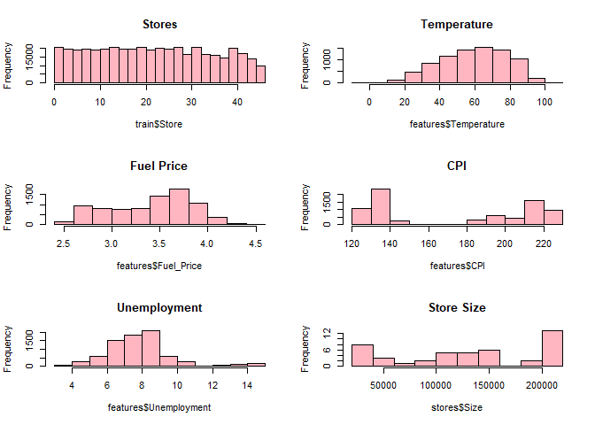

```r
par(mfrow=c(3,2))
hist(train$Store, col = 'light pink', main = "Stores")
hist(features$Temperature, col = 'light pink', main = "Temperature")
hist(features$Fuel_Price, col = 'light pink', main = "Fuel Price")
hist(features$CPI, col = 'light pink', main = "CPI")
hist(features$Unemployment, col = 'light pink', main = "Unemployment")
hist(stores$Size, col = 'light pink', main = "Store Size")
```

Temperature, Fuel Price and Unemployment are fairly normally distributed. Store Sizes have brackets on both ends indicating large number of large and small stores. The medium sized stores are very few in comparison in this dataset. We might need to do some transformation of this data

```r
#Merge store data with train data
tdata <- merge(x=train,y=stores,all.x = TRUE)
#merge features with train data
train<-merge(x=tdata, y= features, all.x = TRUE)
train_format <- data.frame(Store=factor(),Date=as.Date(character()),CPI = double(), Unemployment = double(), Weekly_Sales=double(),IsHoliday=logical(),Type=factor())
```

```r
#sum of weekly sales of all dept
sum_weekly_sales <- function(){
  for(n in 1:45){
    per_store <- train %>% filter(Store == n)
    each_date <- unique(train$Date)

    for(dates in seq_along(each_date)){
      curdate <- unique(train$Date)[[dates]]
      dataDates <- per_store %>% filter(Date==curdate)

      net_sales <- unlist(sum(dataDates$Weekly_Sales))
      nrow <- data.frame(Store=n,Date=curdate,Weekly_Sales=net_sales,CPI = dataDates$CPI[[1]], Unemployment = dataDates$Unemployment[[1]], IsHoliday=dataDates$IsHoliday[[1]],Type=dataDates$Type[[1]])
      train_format <- rbind(train_format,nrow)


    }
  }
  return(train_format)

}
```

### Sum of the weekly sales of all department-wide stores

```r
train_final <- sum_weekly_sales()
head(train_final)
```

```
##   Store       Date Weekly_Sales      CPI Unemployment IsHoliday Type
## 1     1 2010-02-05      1643691 211.0964        8.106     FALSE    A
## 2     1 2010-02-12      1641957 211.2422        8.106      TRUE    A
## 3     1 2010-02-19      1611968 211.2891        8.106     FALSE    A
## 4     1 2010-02-26      1409728 211.3196        8.106     FALSE    A
## 5     1 2010-03-05      1554807 211.3501        8.106     FALSE    A
## 6     1 2010-03-12      1439542 211.3806        8.106     FALSE    A
```

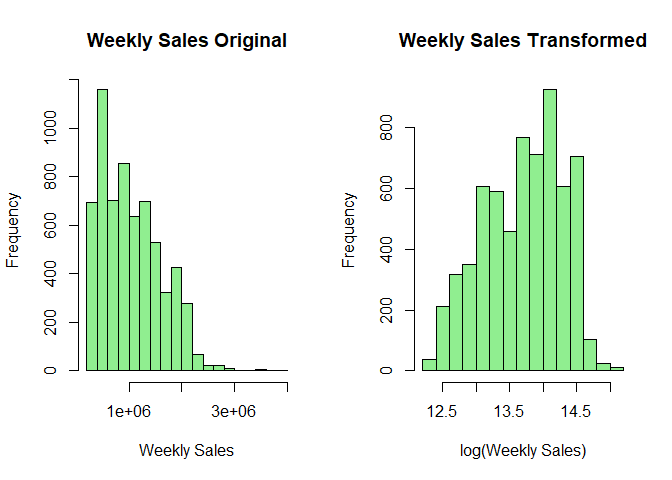

```r
par(mfrow = c(1,2))
hist(train_final$Weekly_Sales, col = 'light green', main = "Weekly Sales Original", xlab = "Weekly Sales")
hist(log(train_final$Weekly_Sales), col = 'light green', main = "Weekly Sales Transformed", xlab ='log(Weekly Sales)')
```

# **ARIMA MODEL**

ARIMA models aim to describe the autocorrelations in the data and are generally used to make forecasts rather than predicting sales in the past. The nature of the algorithm requires that the data are transformed into a time series format and that there are no missing observations (weeks). Thus, creating a train/test set for time-series problems becomes tricky because the time component has to be taken into account..

```r
#AUTO ARIMA
train.Store1 <- train_final %>% filter(Store == 1)
trainStore1.ts <- ts(train.Store1, frequency = 52, start = c(2010,5), end = c(2012,42))
train.train1 <- window(trainStore1.ts, start = c(2010,5), end = c(2011,52))
train.test1 <- window(trainStore1.ts, start = c(2012,1), end = c(2012,42))
trainArima1 <- auto.arima(train.train1[,3], approximation = TRUE)
trainArima1
```

```
## Series: train.train1[, 3]
## ARIMA(1,0,0) with non-zero mean
##
## Coefficients:
##          ar1        mean
##       0.2900  1542239.24
## s.e.  0.0953    22606.86
##
## sigma^2 estimated as 2.651e+10:  log likelihood=-1340.96
## AIC=2687.92   AICc=2688.17   BIC=2695.73
```

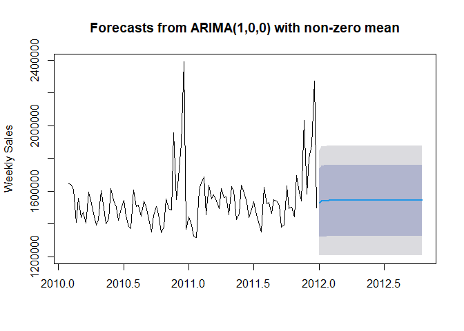

```r
trainArimaForecast1 <- forecast(trainArima1, h = 42)
plot(trainArimaForecast1, ylab = "Weekly Sales")
```

```r
train.test1[,3]
```

```
## Time Series:
## Start = c(2012, 1)
## End = c(2012, 42)
## Frequency = 52
##  [1] 1550370 1459601 1394394 1319326 1636340 1802477 1819870 1539388 1688421
## [10] 1675431 1677473 1511068 1649605 1899677 1621032 1521578 1468928 1684520
## [19] 1611096 1595902 1555445 1624478 1697231 1630607 1527846 1540421 1769854
## [28] 1527014 1497955 1439124 1631136 1592410 1597868 1494122 1582083 1661767
## [37] 1517429 1506126 1437059 1670786 1573073 1508069
```

```r
accuracy(trainArimaForecast1,train.test1[,3])
```

```
##                      ME     RMSE       MAE       MPE     MAPE     MASE
## Training set  -337.9939 161169.1 108032.81 -0.924122 6.696875 1.800870
## Test set     46491.4771 123049.4  94274.39  2.431138 5.784163 1.571522
##                     ACF1 Theil's U
## Training set -0.02083972        NA
## Test set      0.25820255 0.8834956
```

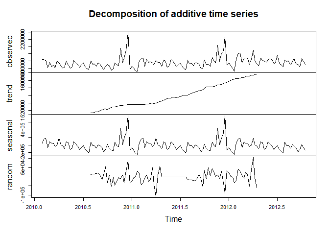

```r
#fit <- lm(Weekly_Sales ~.-Date-Type-CPI, data=train_final)
#INITIAL ANALYSIS
plot(decompose(trainStore1.ts[,3]))
```

```r
adf.test(trainStore1.ts[,3], k = 20)
```

```
##
##  Augmented Dickey-Fuller Test
##
## data:  trainStore1.ts[, 3]
## Dickey-Fuller = -2.5636, Lag order = 20, p-value = 0.3418
## alternative hypothesis: stationary
```

### TRAINING ON STORE NUMBER 45

```r
train.Store45 <- train_final %>% filter(Store == 45)
trainStore45.ts <- ts(train.Store45, frequency = 52, start = c(2010,5), end = c(2012,42))
train.train45 <- window(trainStore45.ts, start = c(2010,5), end = c(2011,52))
train.test45 <- window(trainStore45.ts, start = c(2012,1), end = c(2012,42))
trainArima45 <- auto.arima(train.train45[,3], approximation = TRUE)
summary(trainArima45)
```

```
## Series: train.train45[, 3]
## ARIMA(2,0,1) with non-zero mean
##
## Coefficients:
##           ar1     ar2     ma1      mean
##       -0.3935  0.4495  0.7418  799044.8
## s.e.   0.1418  0.0964  0.1321   24680.0
##
## sigma^2 estimated as 1.896e+10:  log likelihood=-1323.35
## AIC=2656.7   AICc=2657.34   BIC=2669.73
##
## Training set error measures:
##                     ME     RMSE      MAE       MPE     MAPE     MASE
## Training set -283.5613 134927.1 72873.31 -1.914762 8.244782 1.670852
##                     ACF1
## Training set 0.002799298
```

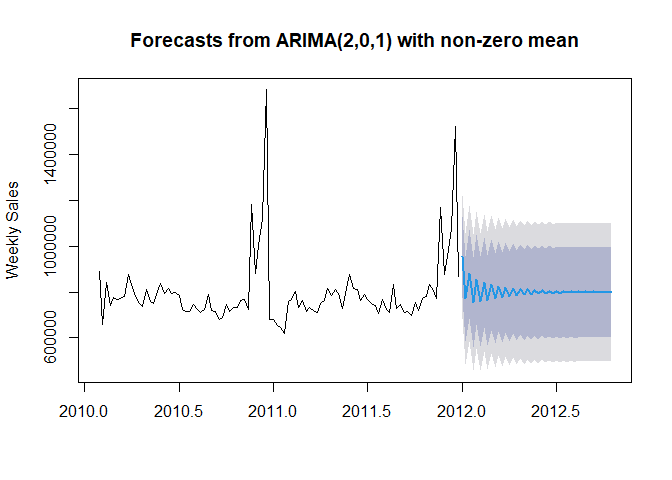

```r
trainArimaForecast45 <- forecast(trainArima45, h = 42)
plot(trainArimaForecast45, ylab = "Weekly Sales")
```

```r
accuracy(trainArimaForecast45,train.test45[,3])
```

```
##                       ME      RMSE      MAE       MPE     MAPE     MASE
## Training set   -283.5613 134927.14 72873.31 -1.914762 8.244782 1.670852
## Test set     -42706.9976  76234.53 59815.31 -6.121252 8.141597 1.371456
##                     ACF1 Theil's U
## Training set 0.002799298        NA
## Test set     0.387595789  1.372749
```

# **NNETAR MODEL**

some neural network model idk

```r
#NNETAR
train.Store1 <- train_final %>% filter(Store == 1)
trainStore1.ts <- ts(train.Store1, frequency = 52, start = c(2010,5), end = c(2012,42))
train.train1 <- window(trainStore1.ts, start = c(2010,5), end = c(2011,52))
train.test1 <- window(trainStore1.ts, start = c(2012,1), end = c(2012,42))
train1Net <- nnetar(train.train1[,3])
train1Net
```

```
## Series: train.train1[, 3]
## Model:  NNAR(5,1,4)[52]
## Call:   nnetar(y = train.train1[, 3])
##
## Average of 20 networks, each of which is
## a 6-4-1 network with 33 weights
## options were - linear output units
##
## sigma^2 estimated as 383220542
```

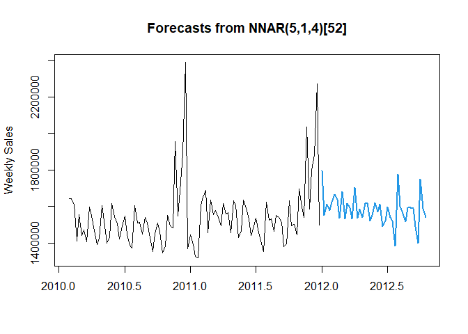

```r
train1Netfo <- forecast(train1Net, h = 42)
plot(train1Netfo, ylab ="Weekly Sales")
```

```r
accuracy(train1Netfo,train.test1[,3])
```

```
##                     ME      RMSE      MAE         MPE      MAPE      MASE
## Training set -114.0334  19576.02 12886.67 -0.04198175 0.8420245 0.2148165
## Test set     5729.1740 102184.38 75016.50  0.03056608 4.7236702 1.2504997
##                     ACF1 Theil's U
## Training set 0.005841219        NA
## Test set     0.312744532 0.7000407
```

```r
#testing NNAR on store 45
train.Store45 <- train_final %>% filter(Store == 45)
trainStore45.ts <- ts(train.Store45, frequency = 52, start = c(2010,5), end = c(2012,42))
train.train45 <- window(trainStore45.ts, start = c(2010,5), end = c(2011,52))
train.test45 <- window(trainStore45.ts, start = c(2012,1), end = c(2012,42))
train45Net <- nnetar(train.train45[,3])
train45Net
```

```
## Series: train.train45[, 3]
## Model:  NNAR(5,1,4)[52]
## Call:   nnetar(y = train.train45[, 3])
##
## Average of 20 networks, each of which is
## a 6-4-1 network with 33 weights
## options were - linear output units
##
## sigma^2 estimated as 280236186
```

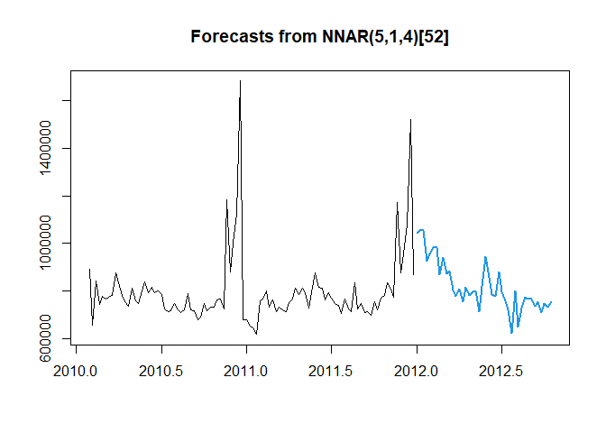

```r
train45Netfo <- forecast(train45Net, h = 42)
plot(train45Netfo)
```

```r
accuracy(train45Netfo,train.test1[,3])
```

```
##                        ME      RMSE       MAE         MPE      MAPE       MASE
## Training set     14.67071  16740.26  11249.27 -0.07475055  1.470939  0.2579253
## Test set     766578.60025 780309.30 766578.60 48.03282224 48.032822 17.5762508
##                    ACF1 Theil's U
## Training set -0.1519610        NA
## Test set      0.5693433  5.567698
```

# **TIME SERIES REGRESSION**

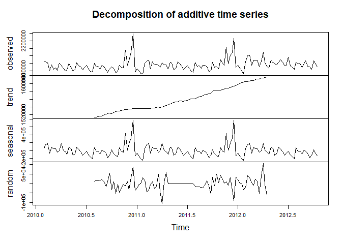

```r
#Time Series Regression
train.Store1 <- train_final %>% filter(Store == 1)
trainStore1.ts <- ts(train.Store1, frequency = 52, start = c(2010,5), end = c(2012,42))
plot(decompose(trainStore1.ts[,3]))
```

```r
train.train1 <- window(trainStore1.ts, start = c(2010,5), end = c(2011,52))
train.test1 <- window(trainStore1.ts, start = c(2012,1), end = c(2012,42))
store1.fit <- tslm(train.train1[,3] ~ trend + season)
summary(store1.fit)
```

```
##
## Call:
## tslm(formula = train.train1[, 3] ~ trend + season)
##
## Residuals:
##    Min     1Q Median     3Q    Max
## -81412 -16825      0  16825  81412
##
## Coefficients:
##              Estimate Std. Error t value Pr(>|t|)
## (Intercept) 1402268.8    44468.8  31.534  < 2e-16 ***
## trend           866.6      171.4   5.055 6.97e-06 ***
## season2      -54584.9    61756.6  -0.884 0.381264
## season3     -119060.1    61757.3  -1.928 0.059926 .
## season4     -130432.8    61758.5  -2.112 0.040031 *
## season5      199493.2    53615.3   3.721 0.000530 ***
## season6      219252.5    53603.6   4.090 0.000168 ***
## season7      222005.2    53592.3   4.142 0.000142 ***
## season8        4997.1    53581.6   0.093 0.926093
## season9      166401.6    53571.5   3.106 0.003210 **
## season10      66366.5    53561.9   1.239 0.221474
## season11      93800.3    53552.8   1.752 0.086375 .
## season12      41032.9    53544.3   0.766 0.447309
## season13     112416.6    53536.4   2.100 0.041140 *
## season14     146372.5    53528.9   2.734 0.008783 **
## season15      78640.6    53522.1   1.469 0.148411
## season16      42838.3    53515.8   0.800 0.427461
## season17       4029.4    53510.0   0.075 0.940294
## season18     179740.3    53504.8   3.359 0.001558 **
## season19     111714.1    53500.1   2.088 0.042233 *
## season20     -24725.9    53496.0  -0.462 0.646070
## season21       9525.6    53492.4   0.178 0.859430
## season22     184902.3    53489.4   3.457 0.001170 **
## season23     124488.8    53486.9   2.327 0.024298 *
## season24      75567.0    53485.0   1.413 0.164284
## season25     -12228.2    53483.6  -0.229 0.820145
## season26      46612.4    53482.8   0.872 0.387890
## season27      95729.6    53482.5   1.790 0.079910 .
## season28       6430.6    53482.8   0.120 0.904809
## season29     -55469.5    53483.6  -1.037 0.304982
```

[output cut: 14 more lines]

```
## season44     164979.9    53561.9   3.080 0.003452 **
## season45      84378.1    53571.5   1.575 0.121952
## season46      50436.2    53581.6   0.941 0.351366
## season47     532408.1    53592.3   9.934 3.96e-13 ***
## season48     103128.0    53603.6   1.924 0.060435 .
## season49     277350.8    53615.3   5.173 4.68e-06 ***
## season50     421441.7    53627.7   7.859 4.14e-10 ***
## season51     863538.9    53640.5  16.099  < 2e-16 ***
## season52     -34005.9    53654.0  -0.634 0.529283
## ---
## Signif. codes:  0 '***' 0.001 '**' 0.01 '*' 0.05 '.' 0.1 ' ' 1
##
## Residual standard error: 43670 on 47 degrees of freedom
## Multiple R-squared:  0.9684, Adjusted R-squared:  0.9335
## F-statistic: 27.74 on 52 and 47 DF,  p-value: < 2.2e-16
```

```r
accuracy(store1.fit)
```

```
##                        ME     RMSE      MAE         MPE     MAPE      MASE
## Training set 2.327702e-12 29937.49 23125.27 -0.03643174 1.480033 0.3854904
##                    ACF1
## Training set 0.04181091
```

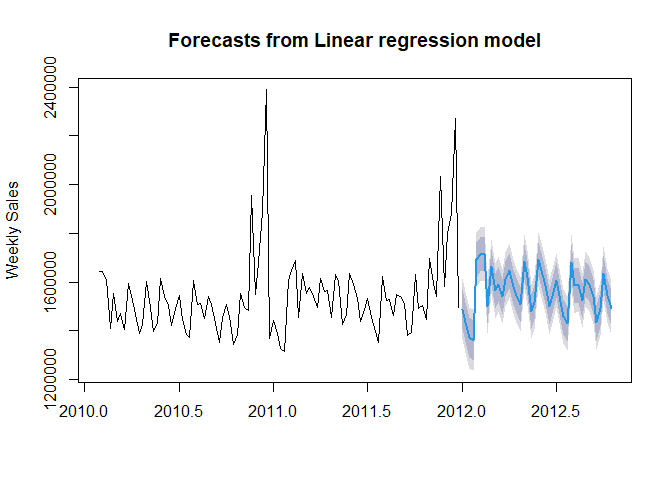

```r
trainTSLMfor1 <- forecast(store1.fit, h = 42)
plot(trainTSLMfor1, ylab = "Weekly Sales")
```

```r
accuracy(trainTSLMfor1, train.test1[,3])
```

```
##                        ME     RMSE      MAE         MPE     MAPE      MASE
## Training set 2.327702e-12 29937.49 23125.27 -0.03643174 1.480033 0.3854904
## Test set     2.771196e+04 68078.31 50221.82  1.58455018 3.059190 0.8371808
##                      ACF1 Theil's U
## Training set  0.041810906        NA
## Test set     -0.003670723 0.4766586
```

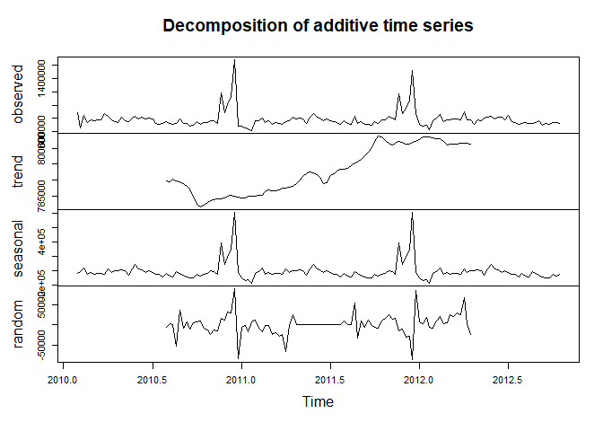

```r
#Decompose for store 45
train.Store45 <- train_final %>% filter(Store == 45)
trainStore45.ts <- ts(train.Store45, frequency = 52, start = c(2010,5), end = c(2012,42))
plot(decompose(trainStore45.ts[,3]))
```

```r
#COmpare store 1 and store 45
train.train45 <- window(trainStore45.ts, start = c(2010,5), end = c(2011,52))
train.test45 <- window(trainStore45.ts, start = c(2012,1), end = c(2012,42))
store45.fit <- tslm(train.train45[,3] ~ trend + season)
summary(store45.fit)
```

```
##
## Call:
## tslm(formula = train.train45[, 3] ~ trend + season)
##
## Residuals:
##    Min     1Q Median     3Q    Max
## -95090 -13797      0  13797  95090
##
## Coefficients:
##               Estimate Std. Error t value Pr(>|t|)
## (Intercept) 680190.385  45244.028  15.034  < 2e-16 ***
## trend            1.305    174.407   0.007 0.994060
## season2     -26236.705  62833.181  -0.418 0.678169
## season3     -35971.631  62833.907  -0.572 0.569720
## season4     -63050.686  62835.118  -1.003 0.320791
## season5     144840.289  54550.031   2.655 0.010787 *
## season6      31495.384  54538.041   0.577 0.566362
## season7     141530.483  54526.606   2.596 0.012559 *
## season8      57574.668  54515.727   1.056 0.296316
## season9      89684.937  54505.404   1.645 0.106553
## season10     59618.917  54495.637   1.094 0.279525
## season11     73458.667  54486.426   1.348 0.184056
## season12     70915.546  54477.772   1.302 0.199352
## season13    114594.786  54469.676   2.104 0.040772 *
## season14    111745.325  54462.136   2.052 0.045784 *
## season15     93507.305  54455.154   1.717 0.092537 .
## season16    101464.779  54448.730   1.863 0.068648 .
## season17     81672.294  54442.864   1.500 0.140264
## season18    130928.099  54437.556   2.405 0.020158 *
## season19     95791.743  54432.807   1.760 0.084946 .
## season20     57280.748  54428.615   1.052 0.297996
## season21    129129.322  54424.983   2.373 0.021807 *
## season22    177238.212  54421.909   3.257 0.002095 **
## season23    124297.842  54419.393   2.284 0.026929 *
## season24    132891.651  54417.437   2.442 0.018419 *
## season25     97328.726  54416.040   1.789 0.080125 .
## season26    115568.500  54415.201   2.124 0.038976 *
## season27     97635.705  54414.922   1.794 0.079202 .
## season28     55816.440  54415.201   1.026 0.310260
## season29     47856.219  54416.040   0.879 0.383631
```

[output cut: 14 more lines]

```
## season44    118445.098  54495.637   2.173 0.034816 *
## season45    106859.028  54505.404   1.961 0.055877 .
## season46     68516.657  54515.727   1.257 0.215028
## season47    496306.092  54526.606   9.102 6.09e-12 ***
## season48    197190.591  54538.041   3.616 0.000729 ***
## season49    299476.756  54550.031   5.490 1.58e-06 ***
## season50    420809.891  54562.576   7.712 6.86e-10 ***
## season51    922124.330  54575.675  16.896  < 2e-16 ***
## season52     93992.930  54589.328   1.722 0.091679 .
## ---
## Signif. codes:  0 '***' 0.001 '**' 0.01 '*' 0.05 '.' 0.1 ' ' 1
##
## Residual standard error: 44430 on 47 degrees of freedom
## Multiple R-squared:  0.9588, Adjusted R-squared:  0.9133
## F-statistic: 21.05 on 52 and 47 DF,  p-value: < 2.2e-16
```

```r
accuracy(store45.fit)
```

```
##                        ME    RMSE      MAE       MPE     MAPE MASE        ACF1
## Training set 4.655618e-12 30459.4 20934.94 -0.137012 2.583098 0.48 -0.02215545
```

```r
trainTSLMfor45 <- forecast(store45.fit, h = 42)
accuracy(trainTSLMfor45, train.test45[,3])
```

```
##                        ME     RMSE      MAE       MPE     MAPE      MASE
## Training set 4.655618e-12 30459.40 20934.94 -0.137012 2.583098 0.4800000
## Test set     1.021437e+04 37840.91 29466.29  1.226133 3.814764 0.6756083
##                     ACF1 Theil's U
## Training set -0.02215545        NA
## Test set     -0.07048090 0.7470766
```

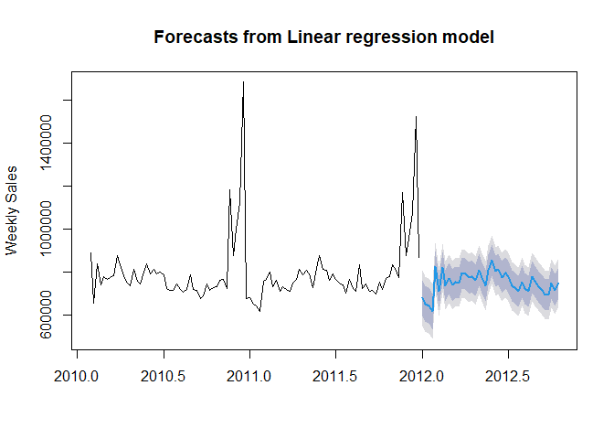

```r
plot(trainTSLMfor45, ylab = "Weekly Sales")
```

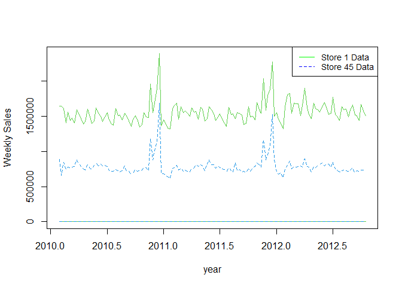

```r
ts.plot(trainStore1.ts,trainStore45.ts, gpars=list(xlab="year", ylab="Weekly Sales", col=c(3:4), lty = c(1,2)))
legend("topright", c("Store 1 Data", "Store 45 Data"), cex = 0.85, lty = c(1,2), col = c("green", "blue"))
```

# FINAL TIME SERIES MODEL FOR PREDICTION

```r
#FINAL MODEL PREDICTION
dates <- seq(as.Date("2012-11-02"),as.Date("2013-11-01"),7)

train.Store1 <- train_final %>% filter(Store == 1)
trainStore1.ts <- ts(train.Store1, frequency = 52, start = c(2010,5), end = c(2012,42))
store1.fit <- tslm(trainStore1.ts[,3] ~ trend + season)
trainTSLMfor1 <- forecast(store1.fit, h = 53)
df1 <- rep(1, len = 53)
predict1 <- as.numeric(trainTSLMfor1$mean)
nrow1 <- data.frame(Store=df1,Date=dates,Weekly_Sales=predict1)
```

```r
train.Store2 <- train_final %>% filter(Store == 2)
trainStore2.ts <- ts(train.Store2, frequency = 52, start = c(2010,5), end = c(2012,42))
store2.fit <- tslm(trainStore2.ts[,3] ~ trend + season)
trainTSLMfor2 <- forecast(store2.fit, h = 53)
trainTSLMfor2
```

```
##          Point Forecast   Lo 80   Hi 80   Lo 95   Hi 95
## 2012.808        1779796 1662812 1896779 1599766 1959826
## 2012.827        1943155 1826171 2060138 1763125 2123185
## 2012.846        1912539 1795556 2029523 1732509 2092569
## 2012.865        1923521 1806538 2040504 1743491 2103551
## 2012.885        2630234 2513250 2747217 2450204 2810264
## 2012.904        1979137 1862153 2096120 1799106 2159167
## 2012.923        2328408 2211425 2445392 2148378 2508438
## 2012.942        2514722 2397738 2631705 2334691 2694752
## 2012.962        3323959 3206975 3440942 3143929 3503989
## 2012.981        1806101 1689117 1923084 1626070 1986131
## 2013.000        1772556 1655572 1889539 1592525 1952586
## 2013.019        1738230 1621246 1855213 1558199 1918260
## 2013.038        1725347 1608364 1842331 1545317 1905377
## 2013.058        1671909 1554926 1788893 1491879 1851939
## 2013.077        1992239 1880971 2103506 1821005 2163473
## 2013.096        2128085 2016817 2239352 1956851 2299319
## 2013.115        2125702 2014434 2236969 1954468 2296936
## 2013.135        1845164 1733896 1956432 1673930 2016398
## 2013.154        1966752 1855485 2078020 1795518 2137986
## 2013.173        1927433 1816166 2038701 1756199 2098667
## 2013.192        1933264 1821996 2044531 1762030 2104498
## 2013.212        1760627 1649359 1871894 1589392 1931861
## 2013.231        1899640 1788372 2010908 1728406 2070874
## 2013.250        1968786 1857518 2080054 1797552 2140020
## 2013.269        1880792 1769524 1992059 1709558 2052026
## 2013.288        1843585 1732318 1954853 1672351 2014819
## 2013.308        1762403 1651135 1873671 1591169 1933637
## 2013.327        1926454 1815187 2037722 1755220 2097688
## 2013.346        1870622 1759355 1981890 1699388 2041856
## 2013.365        1853747 1742479 1965014 1682513 2024981
## 2013.385        1880906 1769638 1992174 1709672 2052140
## 2013.404        1973823 1862555 2085091 1802589 2145057
## 2013.423        1979996 1868729 2091264 1808762 2151230
## 2013.442        1964471 1853204 2075739 1793237 2135705
## 2013.462        1864556 1753288 1975823 1693321 2035790
## 2013.481        1908770 1797502 2020038 1737536 2080004
## 2013.500        1916884 1805617 2028152 1745650 2088118
## 2013.519        1812074 1700807 1923342 1640840 1983308
## 2013.538        1773427 1662159 1884695 1602193 1944661
## 2013.558        1739315 1628047 1850582 1568080 1910549
## 2013.577        1929933 1818665 2041201 1758699 2101167
## 2013.596        1850057 1738789 1961324 1678823 2021291
## 2013.615        1903842 1792574 2015110 1732608 2075076
## 2013.635        1845616 1734349 1956884 1674382 2016850
## 2013.654        1878631 1767363 1989898 1707396 2049865
## 2013.673        1820329 1709061 1931597 1649095 1991563
## 2013.692        1758410 1647142 1869678 1587176 1929644
## 2013.712        1732784 1621517 1844052 1561550 1904018
## 2013.731        1733129 1621861 1844396 1561895 1904363
## 2013.750        1886959 1775691 1998227 1715725 2058193
## 2013.769        1804688 1693420 1915955 1633454 1975922
## 2013.788        1798566 1687299 1909834 1627332 1969800
## 2013.808        1775643 1656828 1894458 1592794 1958492
```

```r
df2 <- rep(2, len = 53)
predict2 <- as.numeric(trainTSLMfor2$mean)
nrow2 <- data.frame(Store=df2,Date=dates,Weekly_Sales=predict2)
```

```r
train.Store3 <- train_final %>% filter(Store == 3)
trainStore3.ts <- ts(train.Store3, frequency = 52, start = c(2010,5), end = c(2012,42))
store3.fit <- tslm(trainStore3.ts[,3] ~ trend + season)
trainTSLMfor3 <- forecast(store3.fit, h = 53)
trainTSLMfor3
```

```
##          Point Forecast    Lo 80    Hi 80    Lo 95    Hi 95
## 2012.808       404712.9 375928.8 433496.9 360416.0 449009.7
## 2012.827       476956.1 448172.0 505740.1 432659.2 521253.0
## 2012.846       432846.3 404062.3 461630.4 388549.5 477143.2
## 2012.865       421338.8 392554.8 450122.9 377042.0 465635.7
## 2012.885       596893.2 568109.2 625677.3 552596.3 641190.1
## 2012.904       510112.7 481328.7 538896.8 465815.9 554409.6
## 2012.923       503854.1 475070.1 532638.2 459557.2 548151.0
## 2012.942       540100.2 511316.2 568884.3 495803.3 584397.1
## 2012.962       614252.5 585468.5 643036.6 569955.6 658549.4
## 2012.981       432262.5 403478.5 461046.6 387965.7 476559.4
## 2013.000       423856.5 395072.4 452640.5 379559.6 468153.3
## 2013.019       409896.6 381112.5 438680.6 365599.7 454193.4
## 2013.038       393994.4 365210.3 422778.4 349697.5 438291.2
## 2013.058       392838.9 364054.8 421622.9 348542.0 437135.7
## 2013.077       489228.7 461851.1 516606.4 447096.2 531361.3
## 2013.096       489044.8 461667.1 516422.5 446912.3 531177.4
## 2013.115       490867.4 463489.7 518245.1 448734.9 532999.9
## 2013.135       455309.4 427931.8 482687.1 413176.9 497442.0
## 2013.154       488208.6 460831.0 515586.3 446076.1 530341.2
## 2013.173       458900.9 431523.3 486278.6 416768.4 501033.5
## 2013.192       440600.2 413222.6 467977.9 398467.7 482732.8
## 2013.212       432375.7 404998.0 459753.3 390243.1 474508.2
## 2013.231       449308.7 421931.0 476686.4 407176.2 491441.2
## 2013.250       481921.5 454543.8 509299.2 439789.0 524054.0
## 2013.269       428206.8 400829.2 455584.5 386074.3 470339.4
## 2013.288       436415.2 409037.5 463792.9 394282.7 478547.7
## 2013.308       421952.2 394574.6 449329.9 379819.7 464084.8
## 2013.327       464955.5 437577.8 492333.1 422822.9 507088.0
## 2013.346       448414.3 421036.6 475791.9 406281.7 490546.8
## 2013.365       423022.0 395644.3 450399.6 380889.4 465154.5
## 2013.385       425242.6 397865.0 452620.3 383110.1 467375.2
## 2013.404       455444.0 428066.3 482821.7 413311.5 497576.5
## 2013.423       445193.1 417815.5 472570.8 403060.6 487325.7
## 2013.442       450720.6 423342.9 478098.3 408588.1 492853.1
## 2013.462       434984.0 407606.3 462361.7 392851.4 477116.5
## 2013.481       438555.5 411177.9 465933.2 396423.0 480688.1
## 2013.500       432717.9 405340.2 460095.6 390585.4 474850.4
## 2013.519       428561.0 401183.3 455938.7 386428.5 470693.5
## 2013.538       429497.8 402120.2 456875.5 387365.3 471630.4
## 2013.558       408450.3 381072.7 435828.0 366317.8 450582.9
## 2013.577       458398.0 431020.4 485775.7 416265.5 500530.6
## 2013.596       418124.2 390746.5 445501.9 375991.7 460256.8
## 2013.615       422983.6 395605.9 450361.3 380851.0 465116.1
## 2013.635       427846.0 400468.4 455223.7 385713.5 469978.6
## 2013.654       431296.1 403918.4 458673.7 389163.5 473428.6
## 2013.673       426808.3 399430.7 454186.0 384675.8 468940.9
## 2013.692       429623.4 402245.7 457001.0 387490.8 471755.9
## 2013.712       425951.6 398573.9 453329.2 383819.0 468084.1
## 2013.731       419887.3 392509.6 447265.0 377754.7 462019.8
## 2013.750       461531.4 434153.7 488909.1 419398.9 503663.9
## 2013.769       422419.4 395041.7 449797.1 380286.8 464551.9
## 2013.788       436990.7 409613.1 464368.4 394858.2 479123.3
## 2013.808       428477.3 399242.6 457712.1 383486.9 473467.8
```

```r
df3 <- rep(3, len = 53)
predict3 <- as.numeric(trainTSLMfor3$mean)
nrow3 <- data.frame(Store=df3,Date=dates,Weekly_Sales=predict3)
```

```r
train.Store4 <- train_final %>% filter(Store == 4)
trainStore4.ts <- ts(train.Store4, frequency = 52, start = c(2010,5), end = c(2012,42))
store4.fit <- tslm(trainStore4.ts[,3] ~ trend + season)
trainTSLMfor4 <- forecast(store4.fit, h = 53)
trainTSLMfor4
```

```
##          Point Forecast   Lo 80   Hi 80   Lo 95   Hi 95
## 2012.808        2249062 2147180 2350945 2092272 2405853
## 2012.827        2353733 2251850 2455615 2196942 2510523
## 2012.846        2307978 2206095 2409860 2151187 2464768
## 2012.865        2377444 2275562 2479326 2220653 2534235
## 2012.885        3103652 3001769 3205534 2946861 3260443
## 2012.904        2348331 2246448 2450213 2191540 2505121
## 2012.923        2612296 2510414 2714178 2455505 2769087
## 2012.942        2962293 2860411 3064176 2805502 3119084
## 2012.962        3808117 3706235 3910000 3651326 3964908
## 2012.981        2107553 2005671 2209436 1950763 2264344
## 2013.000        2161687 2059805 2263570 2004896 2318478
## 2013.019        2110156 2008273 2212038 1953365 2266946
## 2013.038        2152312 2050429 2254194 1995521 2309103
## 2013.058        2078047 1976164 2179929 1921256 2234837
## 2013.077        2417956 2321051 2514860 2268826 2567086
## 2013.096        2525693 2428789 2622598 2376563 2674823
## 2013.115        2540087 2443182 2636991 2390957 2689217
## 2013.135        2352250 2255345 2449154 2203120 2501380
## 2013.154        2369032 2272128 2465937 2219902 2518162
## 2013.173        2320952 2224048 2417857 2171822 2470082
## 2013.192        2351712 2254808 2448617 2202582 2500842
## 2013.212        2208187 2111282 2305091 2059057 2357317
## 2013.231        2265046 2168142 2361951 2115916 2414176
## 2013.250        2396625 2299721 2493530 2247495 2545755
## 2013.269        2247891 2150986 2344795 2098761 2397021
## 2013.288        2331293 2234389 2428198 2182163 2480423
## 2013.308        2195257 2098352 2292161 2046127 2344387
## 2013.327        2362514 2265609 2459418 2213384 2511644
## 2013.346        2277295 2180390 2374199 2128165 2426425
## 2013.365        2317598 2220694 2414503 2168468 2466728
## 2013.385        2274844 2177940 2371749 2125714 2423974
## 2013.404        2324764 2227860 2421669 2175634 2473894
## 2013.423        2338697 2241793 2435602 2189567 2487827
## 2013.442        2377134 2280229 2474038 2228004 2526264
## 2013.462        2292854 2195949 2389758 2143724 2441983
## 2013.481        2295833 2198928 2392737 2146703 2444963
## 2013.500        2309838 2212933 2406742 2160708 2458968
## 2013.519        2291330 2194426 2388235 2142200 2440460
## 2013.538        2295495 2198591 2392400 2146365 2444625
## 2013.558        2220396 2123492 2317301 2071266 2369526
## 2013.577        2356158 2259254 2453063 2207028 2505288
## 2013.596        2377450 2280546 2474355 2228320 2526580
## 2013.615        2446626 2349721 2543530 2297496 2595756
## 2013.635        2262800 2165895 2359704 2113670 2411930
## 2013.654        2307241 2210337 2404146 2158111 2456371
## 2013.673        2303443 2206538 2400347 2154313 2452573
## 2013.692        2306552 2209647 2403456 2157422 2455682
## 2013.712        2262598 2165693 2359502 2113468 2411728
## 2013.731        2208731 2111826 2305635 2059601 2357861
## 2013.750        2384777 2287873 2481682 2235647 2533907
## 2013.769        2300395 2203490 2397299 2151265 2449525
## 2013.788        2352961 2256057 2449865 2203831 2502091
## 2013.808        2386773 2283295 2490251 2227527 2546018
```

```r
df4 <- rep(4, len = 53)
predict4 <- as.numeric(trainTSLMfor4$mean)
nrow4 <- data.frame(Store=df4,Date=dates,Weekly_Sales=predict4)
```

```r
train.Store5 <- train_final %>% filter(Store == 5)
trainStore5.ts <- ts(train.Store5, frequency = 52, start = c(2010,5), end = c(2012,42))
store5.fit <- tslm(trainStore5.ts[,3] ~ trend + season)
trainTSLMfor5 <- forecast(store5.fit, h = 53)
trainTSLMfor5
```

```
##          Point Forecast    Lo 80    Hi 80    Lo 95    Hi 95
## 2012.808       319444.2 299734.3 339154.2 289111.8 349776.6
## 2012.827       366392.0 346682.1 386102.0 336059.6 396724.4
## 2012.846       333777.8 314067.8 353487.7 303445.4 364110.2
## 2012.865       329575.3 309865.4 349285.3 299242.9 359907.7
## 2012.885       525042.1 505332.1 544752.0 494709.7 555374.5
## 2012.904       387269.0 367559.0 406978.9 356936.6 417601.4
## 2012.923       387033.4 367323.4 406743.3 356701.0 417365.8
## 2012.942       400576.5 380866.5 420286.4 370244.1 430908.9
## 2012.962       489197.0 469487.0 508906.9 458864.6 519529.4
## 2012.981       350813.3 331103.3 370523.2 320480.9 381145.7
## 2013.000       326123.7 306413.8 345833.7 295791.3 356456.1
## 2013.019       302956.4 283246.4 322666.3 272624.0 333288.8
## 2013.038       308329.4 288619.5 328039.4 277997.0 338661.8
## 2013.058       314442.0 294732.1 334152.0 284109.7 344774.4
## 2013.077       362792.4 344045.5 381539.4 333942.1 391642.8
## 2013.096       360099.7 341352.8 378846.6 331249.3 388950.1
## 2013.115       374713.7 355966.8 393460.6 345863.3 403564.1
## 2013.135       328268.2 309521.3 347015.1 299417.8 357118.6
## 2013.154       361579.5 342832.6 380326.4 332729.2 390429.9
## 2013.173       348443.4 329696.5 367190.3 319593.1 377293.8
## 2013.192       346973.2 328226.3 365720.1 318122.8 375823.6
## 2013.212       332319.5 313572.5 351066.4 303469.1 361169.8
## 2013.231       361561.4 342814.5 380308.3 332711.1 390411.8
## 2013.250       381994.3 363247.3 400741.2 353143.9 410844.6
## 2013.269       358082.4 339335.5 376829.4 329232.1 386932.8
## 2013.288       351653.7 332906.8 370400.7 322803.4 380504.1
## 2013.308       346157.4 327410.4 364904.3 317307.0 375007.7
## 2013.327       375001.0 356254.1 393747.9 346150.6 403851.3
## 2013.346       343039.1 324292.2 361786.0 314188.7 371889.5
## 2013.365       348354.2 329607.2 367101.1 319503.8 377204.5
## 2013.385       352266.8 333519.8 371013.7 323416.4 381117.1
## 2013.404       378173.5 359426.6 396920.5 349323.2 407023.9
## 2013.423       350324.5 331577.6 369071.5 321474.2 379174.9
## 2013.442       351211.3 332464.4 369958.3 322361.0 380061.7
## 2013.462       343607.9 324860.9 362354.8 314757.5 372458.2
## 2013.481       356796.1 338049.1 375543.0 327945.7 385646.4
## 2013.500       350490.4 331743.5 369237.3 321640.0 379340.8
## 2013.519       329265.6 310518.7 348012.6 300415.3 358116.0
## 2013.538       332043.5 313296.6 350790.4 303193.1 360893.8
## 2013.558       319513.8 300766.9 338260.8 290663.5 348364.2
## 2013.577       350873.2 332126.3 369620.2 322022.9 379723.6
## 2013.596       330255.4 311508.5 349002.3 301405.0 359105.8
## 2013.615       337502.1 318755.2 356249.1 308651.8 366352.5
## 2013.635       342444.1 323697.2 361191.0 313593.7 371294.4
## 2013.654       363909.5 345162.6 382656.4 335059.1 392759.9
## 2013.673       361978.4 343231.5 380725.3 333128.0 390828.8
## 2013.692       322844.0 304097.1 341590.9 293993.6 351694.4
## 2013.712       333035.4 314288.5 351782.4 304185.1 361885.8
## 2013.731       331092.7 312345.8 349839.6 302242.4 359943.1
## 2013.750       350099.2 331352.3 368846.1 321248.8 378949.6
## 2013.769       333262.4 314515.5 352009.4 304412.1 362112.8
## 2013.788       337352.9 318605.9 356099.8 308502.5 366203.2
## 2013.808       337384.7 317366.2 357403.2 306577.4 368192.0
```

```r
df5 <- rep(5, len = 53)
predict5 <- as.numeric(trainTSLMfor5$mean)
nrow5 <- data.frame(Store=df5,Date=dates,Weekly_Sales=predict5)
```

```r
train.Store6 <- train_final %>% filter(Store == 6)
trainStore6.ts <- ts(train.Store6, frequency = 52, start = c(2010,5), end = c(2012,42))
store6.fit <- tslm(trainStore6.ts[,3] ~ trend + season)
trainTSLMfor6 <- forecast(store6.fit, h = 53)
trainTSLMfor6
```

```
##          Point Forecast   Lo 80   Hi 80   Lo 95   Hi 95
## 2012.808        1415442 1313830 1517055 1259067 1571818
## 2012.827        1527489 1425877 1629102 1371114 1683865
## 2012.846        1528915 1427302 1630527 1372539 1685290
## 2012.865        1534674 1433061 1636286 1378298 1691049
## 2012.885        2271690 2170078 2373303 2115315 2428065
## 2012.904        1695857 1594245 1797470 1539482 1852233
## 2012.923        1882119 1780507 1983732 1725744 2038495
## 2012.942        2075540 1973928 2177153 1919165 2231916
## 2012.962        2699162 2597550 2800775 2542787 2855538
## 2012.981        1544123 1442511 1645736 1387748 1700499
## 2013.000        1385949 1284336 1487561 1229573 1542324
## 2013.019        1338277 1236664 1439889 1181902 1494652
## 2013.038        1306812 1205200 1408425 1150437 1463188
## 2013.058        1314381 1212768 1415993 1158005 1470756
## 2013.077        1572057 1475410 1668705 1423322 1720792
## 2013.096        1588680 1492032 1685328 1439945 1737415
## 2013.115        1608035 1511387 1704682 1459300 1756770
## 2013.135        1457658 1361010 1554306 1308923 1606393
## 2013.154        1568862 1472214 1665509 1420127 1717596
## 2013.173        1558218 1461571 1654866 1409484 1706953
## 2013.192        1726226 1629578 1822873 1577491 1874961
## 2013.212        1485958 1389311 1582606 1337223 1634693
## 2013.231        1596925 1500278 1693573 1448190 1745660
## 2013.250        1698046 1601399 1794694 1549311 1846781
## 2013.269        1545757 1449109 1642404 1397022 1694492
## 2013.288        1562700 1466052 1659348 1413965 1711435
## 2013.308        1495261 1398613 1591909 1346526 1643996
## 2013.327        1573422 1476774 1670069 1424687 1722157
## 2013.346        1515518 1418870 1612165 1366783 1664253
## 2013.365        1493530 1396882 1590178 1344795 1642265
## 2013.385        1608158 1511511 1704806 1459424 1756893
## 2013.404        1765413 1668766 1862061 1616678 1914148
## 2013.423        1677716 1581068 1774364 1528981 1826451
## 2013.442        1664626 1567978 1761274 1515891 1813361
## 2013.462        1618184 1521536 1714832 1469449 1766919
## 2013.481        1718475 1621827 1815122 1569740 1867210
## 2013.500        1776094 1679447 1872742 1627359 1924829
## 2013.519        1575766 1479118 1672413 1427031 1724500
## 2013.538        1579447 1482799 1676095 1430712 1728182
## 2013.558        1527254 1430606 1623901 1378519 1675989
## 2013.577        1638111 1541463 1734759 1489376 1786846
## 2013.596        1557754 1461107 1654402 1409020 1706489
## 2013.615        1542919 1446271 1639567 1394184 1691654
## 2013.635        1474833 1378185 1571481 1326098 1623568
## 2013.654        1540739 1444091 1637386 1392004 1689474
## 2013.673        1522703 1426055 1619351 1373968 1671438
## 2013.692        1362448 1265800 1459096 1213713 1511183
## 2013.712        1363157 1266510 1459805 1214423 1511892
## 2013.731        1352461 1255814 1449109 1203727 1501196
## 2013.750        1470822 1374175 1567470 1322087 1619557
## 2013.769        1414244 1317596 1510891 1265509 1562979
## 2013.788        1413252 1316604 1509899 1264517 1561987
## 2013.808        1424148 1320944 1527351 1265324 1582971
```

```r
df6 <- rep(6, len = 53)
predict6 <- as.numeric(trainTSLMfor6$mean)
nrow6 <- data.frame(Store=df6,Date=dates,Weekly_Sales=predict6)
```

```r
train.Store7 <- train_final %>% filter(Store == 7)
trainStore7.ts <- ts(train.Store7, frequency = 52, start = c(2010,5), end = c(2012,42))
store7.fit <- tslm(trainStore7.ts[,3] ~ trend + season)
trainTSLMfor7 <- forecast(store7.fit, h = 53)
trainTSLMfor7
```

```
##          Point Forecast     Lo 80     Hi 80     Lo 95     Hi 95
## 2012.808       562666.9  517768.1  607565.8  493570.3  631763.5
## 2012.827       588774.8  543875.9  633673.7  519678.2  657871.4
## 2012.846       598050.5  553151.7  642949.4  528953.9  667147.1
## 2012.865       577428.0  532529.2  622326.9  508331.5  646524.6
## 2012.885       958383.1  913484.3 1003282.0  889286.6 1027479.7
## 2012.904       638610.3  593711.5  683509.2  569513.8  707706.9
## 2012.923       693038.3  648139.5  737937.2  623941.8  762134.9
## 2012.942       784566.1  739667.2  829464.9  715469.5  853662.6
## 2012.962      1118670.7 1073771.8 1163569.5 1049574.1 1187767.2
## 2012.981       838994.4  794095.5  883893.2  769897.8  908090.9
## 2013.000       753391.4  708492.5  798290.2  684294.8  822487.9
## 2013.019       636880.8  591981.9  681779.6  567784.2  705977.3
## 2013.038       616021.7  571122.9  660920.6  546925.2  685118.3
## 2013.058       593455.7  548556.8  638354.5  524359.1  662552.2
## 2013.077       633402.9  590697.8  676108.1  567682.4  699123.5
## 2013.096       637490.4  594785.3  680195.5  571769.8  703210.9
## 2013.115       655019.5  612314.4  697724.6  589299.0  720740.0
## 2013.135       636939.2  594234.1  679644.3  571218.6  702659.7
## 2013.154       619619.5  576914.3  662324.6  553898.9  685340.0
## 2013.173       627861.6  585156.5  670566.7  562141.0  693582.1
## 2013.192       714557.7  671852.5  757262.8  648837.1  780278.2
## 2013.212       651597.6  608892.5  694302.7  585877.1  717318.1
## 2013.231       640959.8  598254.7  683664.9  575239.2  706680.3
## 2013.250       623747.9  581042.8  666453.0  558027.4  689468.4
## 2013.269       537343.6  494638.5  580048.7  471623.1  603064.2
## 2013.288       531229.5  488524.4  573934.6  465509.0  596950.0
## 2013.308       505638.5  462933.3  548343.6  439917.9  571359.0
## 2013.327       510889.2  468184.0  553594.3  445168.6  576609.7
## 2013.346       504055.8  461350.7  546760.9  438335.3  569776.3
## 2013.365       517765.7  475060.6  560470.9  452045.2  583486.3
## 2013.385       565897.8  523192.7  608603.0  500177.3  631618.4
## 2013.404       638325.3  595620.2  681030.4  572604.8  704045.8
## 2013.423       675882.3  633177.2  718587.4  610161.8  741602.8
## 2013.442       674693.3  631988.1  717398.4  608972.7  740413.8
## 2013.462       715368.6  672663.5  758073.7  649648.1  781089.1
## 2013.481       749750.9  707045.8  792456.0  684030.4  815471.4
## 2013.500       808633.7  765928.6  851338.9  742913.2  874354.3
## 2013.519       719689.3  676984.1  762394.4  653968.7  785409.8
## 2013.538       736541.1  693835.9  779246.2  670820.5  802261.6
## 2013.558       736099.2  693394.0  778804.3  670378.6  801819.7
## 2013.577       761734.7  719029.6  804439.8  696014.2  827455.2
## 2013.596       736594.8  693889.7  779299.9  670874.3  802315.4
## 2013.615       711654.0  668948.9  754359.1  645933.5  777374.6
## 2013.635       686135.1  643430.0  728840.2  620414.6  751855.7
## 2013.654       658863.3  616158.1  701568.4  593142.7  724583.8
## 2013.673       670594.5  627889.4  713299.6  604873.9  736315.0
## 2013.692       618170.8  575465.7  660875.9  552450.3  683891.4
## 2013.712       606666.1  563960.9  649371.2  540945.5  672386.6
## 2013.731       576142.4  533437.2  618847.5  510421.8  641862.9
## 2013.750       592313.0  549607.9  635018.2  526592.5  658033.6
## 2013.769       577932.0  535226.9  620637.1  512211.4  643652.5
## 2013.788       604189.8  561484.7  646894.9  538469.3  669910.3
## 2013.808       606834.0  561232.1  652435.8  536655.6  677012.3
```

```r
df7 <- rep(7, len = 53)
predict7 <- as.numeric(trainTSLMfor7$mean)
nrow7 <- data.frame(Store=df7,Date=dates,Weekly_Sales=predict7)
```

```r
train.Store8 <- train_final %>% filter(Store == 8)
trainStore8.ts <- ts(train.Store8, frequency = 52, start = c(2010,5), end = c(2012,42))
store8.fit <- tslm(trainStore8.ts[,3] ~ trend + season)
trainTSLMfor8 <- forecast(store8.fit, h = 53)
trainTSLMfor8
```

```
##          Point Forecast     Lo 80     Hi 80     Lo 95     Hi 95
## 2012.808       893510.1  848004.2  939016.0  823479.3  963540.8
## 2012.827       977316.2  931810.4 1022822.1  907285.5 1047347.0
## 2012.846       954089.3  908583.4  999595.2  884058.5 1024120.0
## 2012.865       931095.7  885589.8  976601.6  861064.9 1001126.4
## 2012.885      1288204.1 1242698.2 1333710.0 1218173.3 1358234.8
## 2012.904      1009459.7  963953.9 1054965.6  939429.0 1079490.5
## 2012.923      1100267.8 1054761.9 1145773.7 1030237.1 1170298.6
## 2012.942      1209147.3 1163641.4 1254653.2 1139116.5 1279178.1
## 2012.962      1526723.1 1481217.2 1572229.0 1456692.4 1596753.9
## 2012.981       855854.9  810349.0  901360.8  785824.2  925885.7
## 2013.000       912364.8  866858.9  957870.7  842334.0  982395.5
## 2013.019       853429.8  807923.9  898935.7  783399.0  923460.5
## 2013.038       858087.1  812581.2  903593.0  788056.3  928117.8
## 2013.058       819993.1  774487.3  865499.0  749962.4  890023.9
## 2013.077      1011814.9  968532.4 1055097.4  945205.8 1078424.0
## 2013.096      1057150.5 1013868.0 1100433.0  990541.4 1123759.6
## 2013.115      1094801.4 1051518.9 1138083.9 1028192.3 1161410.5
## 2013.135       950849.7  907567.2  994132.2  884240.6 1017458.8
## 2013.154       976045.8  932763.3 1019328.3  909436.8 1042654.9
## 2013.173       959980.4  916697.9 1003262.9  893371.3 1026589.5
## 2013.192       939493.6  896211.1  982776.1  872884.5 1006102.7
## 2013.212       877944.3  834661.8  921226.8  811335.2  944553.4
## 2013.231       952766.9  909484.4  996049.4  886157.8 1019376.0
## 2013.250      1023926.2  980643.7 1067208.7  957317.1 1090535.3
## 2013.269       953429.2  910146.7  996711.7  886820.1 1020038.3
## 2013.288       939768.0  896485.5  983050.5  873158.9 1006377.1
## 2013.308       890746.0  847463.5  934028.5  824136.9  957355.0
## 2013.327       984870.9  941588.4 1028153.4  918261.8 1051480.0
## 2013.346       949444.1  906161.6  992726.6  882835.0 1016053.2
## 2013.365       909135.8  865853.3  952418.3  842526.7  975744.9
## 2013.385       926746.9  883464.4  970029.4  860137.8  993356.0
## 2013.404       989237.0  945954.5 1032519.5  922627.9 1055846.1
## 2013.423       966689.2  923406.7 1009971.7  900080.1 1033298.2
## 2013.442       955997.3  912714.8  999279.8  889388.2 1022606.4
## 2013.462       912784.1  869501.6  956066.6  846175.0  979393.2
## 2013.481       924472.5  881190.0  967755.0  857863.4  991081.6
## 2013.500       934187.5  890905.0  977470.0  867578.5 1000796.6
## 2013.519       916048.7  872766.2  959331.2  849439.6  982657.8
## 2013.538       887784.9  844502.4  931067.4  821175.8  954393.9
## 2013.558       863902.3  820619.8  907184.8  797293.3  930511.4
## 2013.577       947324.2  904041.7  990606.7  880715.1 1013933.2
## 2013.596       938187.7  894905.2  981470.2  871578.7 1004796.8
## 2013.615       940486.1  897203.6  983768.6  873877.0 1007095.2
## 2013.635       965611.8  922329.3 1008894.3  899002.7 1032220.9
## 2013.654       975221.2  931938.7 1018503.7  908612.1 1041830.3
## 2013.673       923682.0  880399.5  966964.5  857072.9  990291.0
## 2013.692       916783.8  873501.3  960066.3  850174.7  983392.8
## 2013.712       865689.3  822406.9  908971.8  799080.3  932298.4
## 2013.731       885660.5  842378.0  928943.0  819051.4  952269.6
## 2013.750       978621.5  935339.1 1021904.0  912012.5 1045230.6
## 2013.769       925449.8  882167.3  968732.3  858840.7  992058.9
## 2013.788       933938.5  890656.0  977221.0  867329.5 1000547.6
## 2013.808       920027.1  873808.8  966245.5  848899.9  991154.3
```

```r
df8 <- rep(8, len = 53)
predict8 <- as.numeric(trainTSLMfor8$mean)
nrow8 <- data.frame(Store=df8,Date=dates,Weekly_Sales=predict8)
```

```r
train.Store9 <- train_final %>% filter(Store == 9)
trainStore9.ts <- ts(train.Store9, frequency = 52, start = c(2010,5), end = c(2012,42))
store9.fit <- tslm(trainStore9.ts[,3] ~ trend + season)
trainTSLMfor9 <- forecast(store9.fit, h = 53)
trainTSLMfor9
```

```
##          Point Forecast    Lo 80    Hi 80    Lo 95    Hi 95
## 2012.808       576724.8 543844.2 609605.4 526123.6 627326.0
## 2012.827       605922.8 573042.2 638803.4 555321.6 656524.0
## 2012.846       605770.7 572890.1 638651.3 555169.5 656371.9
## 2012.865       579179.1 546298.5 612059.7 528577.9 629780.3
## 2012.885       839472.3 806591.7 872352.9 788871.1 890073.5
## 2012.904       643700.3 610819.7 676580.9 593099.1 694301.5
## 2012.923       672284.8 639404.2 705165.4 621683.6 722886.0
## 2012.942       743460.9 710580.3 776341.5 692859.7 794062.1
## 2012.962       937396.4 904515.8 970277.0 886795.2 987997.6
## 2012.981       552839.9 519959.3 585720.5 502238.7 603441.1
## 2013.000       553344.0 520463.4 586224.6 502742.8 603945.2
## 2013.019       514585.9 481705.3 547466.5 463984.7 565187.1
## 2013.038       515136.2 482255.6 548016.7 464535.0 565737.3
## 2013.058       521066.6 488186.0 553947.2 470465.4 571667.8
## 2013.077       612109.0 580834.9 643383.0 563980.1 660237.8
## 2013.096       636644.6 605370.5 667918.6 588515.8 684773.4
## 2013.115       657839.9 626565.8 689113.9 609711.0 705968.7
## 2013.135       580900.1 549626.1 612174.2 532771.3 629029.0
## 2013.154       620351.2 589077.1 651625.2 572222.3 668480.0
## 2013.173       593042.1 561768.1 624316.2 544913.3 641171.0
## 2013.192       581195.1 549921.1 612469.2 533066.3 629324.0
## 2013.212       575155.8 543881.8 606429.9 527027.0 623284.6
## 2013.231       611131.7 579857.6 642405.7 563002.8 659260.5
## 2013.250       653712.5 622438.4 684986.5 605583.6 701841.3
## 2013.269       594988.5 563714.5 626262.6 546859.7 643117.4
## 2013.288       591082.0 559807.9 622356.0 542953.1 639210.8
## 2013.308       588868.6 557594.5 620142.6 540739.7 636997.4
## 2013.327       616636.6 585362.6 647910.7 568507.8 664765.5
## 2013.346       605577.4 574303.4 636851.5 557448.6 653706.3
## 2013.365       596082.3 564808.2 627356.4 547953.5 644211.1
## 2013.385       617148.2 585874.2 648422.3 569019.4 665277.1
## 2013.404       649651.8 618377.8 680925.9 601523.0 697780.7
## 2013.423       615852.9 584578.8 647126.9 567724.0 663981.7
## 2013.442       609530.8 578256.7 640804.8 561401.9 657659.6
## 2013.462       600807.8 569533.8 632081.9 552679.0 648936.7
## 2013.481       600969.5 569695.4 632243.5 552840.6 649098.3
## 2013.500       597467.9 566193.9 628742.0 549339.1 645596.8
## 2013.519       571881.1 540607.1 603155.2 523752.3 620010.0
## 2013.538       553453.1 522179.0 584727.1 505324.2 601581.9
## 2013.558       542772.4 511498.4 574046.5 494643.6 590901.3
## 2013.577       601274.6 570000.5 632548.7 553145.8 649403.4
## 2013.596       577712.5 546438.4 608986.5 529583.6 625841.3
## 2013.615       589179.8 557905.8 620453.9 541051.0 637308.7
## 2013.635       604860.7 573586.6 636134.8 556731.9 652989.5
## 2013.654       608270.9 576996.8 639545.0 560142.1 656399.7
## 2013.673       590557.8 559283.8 621831.9 542429.0 638686.7
## 2013.692       559797.0 528523.0 591071.1 511668.2 607925.9
## 2013.712       561882.3 530608.3 593156.4 513753.5 610011.2
## 2013.731       570953.8 539679.8 602227.9 522825.0 619082.7
## 2013.750       619300.9 588026.8 650574.9 571172.0 667429.7
## 2013.769       578330.4 547056.4 609604.5 530201.6 626459.3
## 2013.788       585882.9 554608.8 617156.9 537754.0 634011.7
## 2013.808       608765.0 575369.6 642160.4 557371.6 660158.5
```

```r
df9 <- rep(9, len = 53)
predict9 <- as.numeric(trainTSLMfor9$mean)
nrow9 <- data.frame(Store=df9,Date=dates,Weekly_Sales=predict9)
```

```r
train.Store10 <- train_final %>% filter(Store == 10)
trainStore10.ts <- ts(train.Store10, frequency = 52, start = c(2010,5), end = c(2012,42))
store10.fit <- tslm(trainStore10.ts[,3] ~ trend + season)
trainTSLMfor10 <- forecast(store10.fit, h = 53)
trainTSLMfor10
```

```
##          Point Forecast   Lo 80   Hi 80   Lo 95   Hi 95
## 2012.808        1727956 1612117 1843794 1549688 1906224
## 2012.827        1839730 1723892 1955569 1661462 2017999
## 2012.846        1957641 1841803 2073480 1779373 2135910
## 2012.865        1880538 1764699 1996376 1702269 2058806
## 2012.885        2916478 2800639 3032316 2738209 3094746
## 2012.904        2131057 2015219 2246896 1952789 2309325
## 2012.923        2391956 2276117 2507794 2213687 2570224
## 2012.942        2654744 2538906 2770583 2476476 2833013
## 2012.962        3589927 3474089 3705766 3411659 3768196
## 2012.981        1790399 1674561 1906238 1612131 1968668
## 2013.000        1670261 1554423 1786100 1491993 1848529
## 2013.019        1682588 1566750 1798427 1504320 1860857
## 2013.038        1647965 1532126 1763803 1469696 1826233
## 2013.058        1645493 1529654 1761331 1467224 1823761
## 2013.077        1971373 1861194 2081552 1801815 2140931
## 2013.096        2131884 2021706 2242063 1962326 2301443
## 2013.115        2091566 1981387 2201745 1922008 2261124
## 2013.135        1966603 1856424 2076781 1797045 2136161
## 2013.154        1940362 1830183 2050540 1770804 2109920
## 2013.173        1892640 1782461 2002818 1723082 2062198
## 2013.192        1882682 1772503 1992860 1713123 2052240
## 2013.212        1810803 1700625 1920982 1641245 1980361
## 2013.231        1889255 1779077 1999434 1719697 2058814
## 2013.250        1986932 1876753 2097110 1817374 2156490
## 2013.269        1822772 1712594 1932951 1653214 1992331
## 2013.288        1832380 1722201 1942559 1662822 2001938
## 2013.308        1754316 1644138 1864495 1584758 1923875
## 2013.327        1823262 1713084 1933441 1653704 1992821
## 2013.346        1733006 1622827 1843185 1563448 1902564
## 2013.365        1749765 1639586 1859944 1580207 1919323
## 2013.385        1788059 1677881 1898238 1618501 1957618
## 2013.404        1792236 1682058 1902415 1622678 1961795
## 2013.423        1764566 1654387 1874744 1595008 1934124
## 2013.442        1784252 1674073 1894430 1614693 1953810
## 2013.462        1706980 1596801 1817159 1537422 1876538
## 2013.481        1730122 1619943 1840301 1560564 1899680
## 2013.500        1720374 1610195 1830553 1550816 1889932
## 2013.519        1751438 1641259 1861617 1581880 1920996
## 2013.538        1787202 1677023 1897381 1617644 1956760
## 2013.558        1760577 1650398 1870755 1591018 1930135
## 2013.577        1886866 1776687 1997044 1717307 2056424
## 2013.596        1882151 1771972 1992329 1712593 2051709
## 2013.615        1883819 1773641 1993998 1714261 2053378
## 2013.635        1702190 1592011 1812369 1532632 1871748
## 2013.654        1686942 1576763 1797120 1517384 1856500
## 2013.673        1661671 1551493 1771850 1492113 1831230
## 2013.692        1631147 1520968 1741325 1461588 1800705
## 2013.712        1632809 1522630 1742987 1463250 1802367
## 2013.731        1618028 1507849 1728207 1448470 1787586
## 2013.750        1735004 1624825 1845183 1565446 1904562
## 2013.769        1669371 1559192 1779550 1499813 1838929
## 2013.788        1702206 1592027 1812385 1532648 1871764
## 2013.808        1708893 1591241 1826545 1527833 1889952
```

```r
df10 <- rep(10, len = 53)
predict10 <- as.numeric(trainTSLMfor10$mean)
nrow10 <- data.frame(Store=df10,Date=dates,Weekly_Sales=predict10)
```

```r
train.Store11 <- train_final %>% filter(Store == 11)
trainStore11.ts <- ts(train.Store11, frequency = 52, start = c(2010,5), end = c(2012,42))
store11.fit <- tslm(trainStore11.ts[,3] ~ trend + season)
trainTSLMfor11 <- forecast(store11.fit, h = 53)
trainTSLMfor11
```

```
##          Point Forecast   Lo 80   Hi 80   Lo 95   Hi 95
## 2012.808        1295304 1212023 1378585 1167140 1423468
## 2012.827        1437967 1354687 1521248 1309804 1566131
## 2012.846        1366309 1283028 1449589 1238145 1494473
## 2012.865        1346163 1262882 1429444 1217999 1474327
## 2012.885        1845542 1762261 1928823 1717378 1973706
## 2012.904        1432367 1349086 1515647 1304203 1560530
## 2012.923        1648030 1564750 1731311 1519866 1776194
## 2012.942        1856385 1773104 1939665 1728221 1984548
## 2012.962        2302336 2219055 2385617 2174172 2430500
## 2012.981        1304488 1221207 1387768 1176324 1432652
## 2013.000        1273840 1190559 1357120 1145676 1402003
## 2013.019        1272037 1188757 1355318 1143873 1400201
## 2013.038        1239984 1156703 1323264 1111820 1368148
## 2013.058        1173991 1090711 1257272 1045828 1302155
## 2013.077        1499021 1419809 1578233 1377119 1620923
## 2013.096        1579328 1500117 1658540 1457427 1701230
## 2013.115        1599143 1519932 1678355 1477242 1721045
## 2013.135        1403218 1324006 1482429 1281316 1525120
## 2013.154        1478080 1398868 1557291 1356178 1599982
## 2013.173        1409867 1330655 1489078 1287965 1531768
## 2013.192        1455894 1376682 1535105 1333992 1577796
## 2013.212        1315257 1236046 1394469 1193355 1437159
## 2013.231        1391588 1312377 1470800 1269686 1513490
## 2013.250        1521270 1442059 1600482 1399368 1643172
## 2013.269        1426226 1347014 1505437 1304324 1548128
## 2013.288        1385673 1306461 1464884 1263771 1507575
## 2013.308        1334457 1255246 1413669 1212555 1456359
## 2013.327        1394604 1315392 1473815 1272702 1516505
## 2013.346        1338226 1259015 1417438 1216325 1460128
## 2013.365        1344444 1265232 1423656 1222542 1466346
## 2013.385        1316087 1236875 1395299 1194185 1437989
## 2013.404        1423777 1344565 1502989 1301875 1545679
## 2013.423        1412772 1333561 1491984 1290871 1534674
## 2013.442        1420560 1341349 1499772 1298659 1542462
## 2013.462        1347357 1268145 1426568 1225455 1469258
## 2013.481        1355626 1276414 1434837 1233724 1477527
## 2013.500        1415230 1336019 1494442 1293328 1537132
## 2013.519        1349057 1269846 1428269 1227156 1470959
## 2013.538        1349742 1270531 1428954 1227840 1471644
## 2013.558        1301763 1222551 1380975 1179861 1423665
## 2013.577        1447317 1368105 1526529 1325415 1569219
## 2013.596        1432426 1353214 1511637 1310524 1554328
## 2013.615        1501815 1422604 1581027 1379913 1623717
## 2013.635        1398421 1319209 1477632 1276519 1520322
## 2013.654        1381452 1302240 1460663 1259550 1503354
## 2013.673        1318410 1239198 1397621 1196508 1440311
## 2013.692        1307981 1228770 1387193 1186079 1429883
## 2013.712        1300596 1221384 1379808 1178694 1422498
## 2013.731        1256738 1177526 1335949 1134836 1378640
## 2013.750        1410771 1331560 1489983 1288870 1532673
## 2013.769        1314378 1235166 1393590 1192476 1436280
## 2013.788        1298929 1219718 1378141 1177028 1420831
## 2013.808        1323600 1239016 1408185 1193430 1453771
```

```r
df11 <- rep(11, len = 53)
predict11 <- as.numeric(trainTSLMfor11$mean)
nrow11 <- data.frame(Store=df11,Date=dates,Weekly_Sales=predict11)
```

```r
train.Store12 <- train_final %>% filter(Store == 12)
trainStore12.ts <- ts(train.Store12, frequency = 52, start = c(2010,5), end = c(2012,42))
store12.fit <- tslm(trainStore12.ts[,3] ~ trend + season)
trainTSLMfor12 <- forecast(store12.fit, h = 53)
trainTSLMfor12
```

```
##          Point Forecast     Lo 80     Hi 80     Lo 95     Hi 95
## 2012.808      1013604.8  955594.5 1071615.1  924330.6 1102879.0
## 2012.827      1031312.0  973301.7 1089322.3  942037.8 1120586.2
## 2012.846      1059277.6 1001267.4 1117287.9  970003.4 1148551.9
## 2012.865       973061.8  915051.5 1031072.0  883787.5 1062336.0
## 2012.885      1637143.2 1579132.9 1695153.4 1547868.9 1726417.4
## 2012.904      1110952.4 1052942.1 1168962.7 1021678.2 1200226.6
## 2012.923      1196284.5 1138274.3 1254294.8 1107010.3 1285558.8
## 2012.942      1334999.0 1276988.7 1393009.3 1245724.8 1424273.2
## 2012.962      1733425.2 1675414.9 1791435.5 1644151.0 1822699.4
## 2012.981      1042181.7  984171.5 1100192.0  952907.5 1131456.0
## 2013.000       968461.2  910450.9 1026471.5  879187.0 1057735.4
## 2013.019       879234.1  821223.8  937244.4  789959.9  968508.3
## 2013.038       869508.3  811498.0  927518.6  780234.1  958782.5
## 2013.058       921155.6  863145.3  979165.9  831881.4 1010429.9
## 2013.077      1122286.5 1067110.6 1177462.4 1037374.2 1207198.8
## 2013.096      1188530.9 1133355.0 1243706.8 1103618.6 1273443.2
## 2013.115      1208644.2 1153468.3 1263820.1 1123731.9 1293556.5
## 2013.135      1122944.2 1067768.3 1178120.1 1038031.9 1207856.5
## 2013.154      1157293.5 1102117.6 1212469.4 1072381.2 1242205.8
## 2013.173      1086150.8 1030974.9 1141326.7 1001238.5 1171063.1
## 2013.192      1077355.3 1022179.4 1132531.2  992443.0 1162267.6
## 2013.212      1047706.7  992530.8 1102882.6  962794.3 1132619.0
## 2013.231      1068215.0 1013039.1 1123390.9  983302.7 1153127.3
## 2013.250      1110114.5 1054938.6 1165290.5 1025202.2 1195026.9
## 2013.269      1064912.5 1009736.6 1120088.4  980000.2 1149824.8
## 2013.288      1059439.0 1004263.0 1114614.9  974526.6 1144351.3
## 2013.308      1038471.9  983296.0 1093647.8  953559.6 1123384.2
## 2013.327      1099935.1 1044759.2 1155111.1 1015022.8 1184847.5
## 2013.346      1049020.2  993844.3 1104196.1  964107.9 1133932.5
## 2013.365      1021657.5  966481.6 1076833.4  936745.2 1106569.9
## 2013.385      1024425.0  969249.0 1079600.9  939512.6 1109337.3
## 2013.404      1054336.1  999160.2 1109512.0  969423.8 1139248.4
## 2013.423      1087062.0 1031886.1 1142238.0 1002149.7 1171974.4
## 2013.442      1041416.2  986240.3 1096592.1  956503.9 1126328.5
## 2013.462      1032884.6  977708.6 1088060.5  947972.2 1117796.9
## 2013.481      1006350.8  951174.9 1061526.7  921438.5 1091263.1
## 2013.500      1021366.5  966190.6 1076542.4  936454.2 1106278.8
## 2013.519       991564.8  936388.9 1046740.7  906652.5 1076477.1
## 2013.538       979387.6  924211.7 1034563.6  894475.3 1064300.0
## 2013.558       961013.4  905837.5 1016189.3  876101.1 1045925.7
## 2013.577      1025644.6  970468.7 1080820.5  940732.2 1110556.9
## 2013.596      1010281.7  955105.7 1065457.6  925369.3 1095194.0
## 2013.615      1027414.9  972239.0 1082590.8  942502.6 1112327.2
## 2013.635      1077396.1 1022220.2 1132572.0  992483.8 1162308.4
## 2013.654      1117243.5 1062067.6 1172419.4 1032331.2 1202155.8
## 2013.673       981030.9  925855.0 1036206.8  896118.6 1065943.2
## 2013.692       930014.1  874838.2  985190.0  845101.8 1014926.4
## 2013.712       936108.1  880932.2  991284.1  851195.8 1021020.5
## 2013.731       919910.1  864734.2  975086.0  834997.8 1004822.4
## 2013.750      1003794.4  948618.5 1058970.3  918882.1 1088706.7
## 2013.769       962304.8  907128.9 1017480.7  877392.5 1047217.1
## 2013.788       973136.8  917960.9 1028312.7  888224.5 1058049.1
## 2013.808      1040601.0  981682.4 1099519.5  949929.0 1131272.9
```

```r
df12 <- rep(12, len = 53)
predict12 <- as.numeric(trainTSLMfor12$mean)
nrow12 <- data.frame(Store=df12,Date=dates,Weekly_Sales=predict12)
```

```r
train.Store13 <- train_final %>% filter(Store == 13)
trainStore13.ts <- ts(train.Store13, frequency = 52, start = c(2010,5), end = c(2012,42))
store13.fit <- tslm(trainStore13.ts[,3] ~ trend + season)
trainTSLMfor13 <- forecast(store13.fit, h = 53)
trainTSLMfor13
```

```
##          Point Forecast   Lo 80   Hi 80   Lo 95   Hi 95
## 2012.808        2022246 1907323 2137169 1845387 2199105
## 2012.827        2049574 1934651 2164497 1872715 2226433
## 2012.846        2129710 2014787 2244633 1952851 2306569
## 2012.865        2074790 1959867 2189713 1897931 2251650
## 2012.885        2919217 2804294 3034140 2742358 3096076
## 2012.904        2171279 2056357 2286202 1994420 2348139
## 2012.923        2566055 2451132 2680978 2389196 2742914
## 2012.942        2869928 2755006 2984851 2693069 3046788
## 2012.962        3680266 3565343 3795189 3503407 3857125
## 2012.981        1926106 1811183 2041029 1749247 2102965
## 2013.000        1909080 1794157 2024003 1732221 2085939
## 2013.019        1842571 1727648 1957494 1665712 2019430
## 2013.038        1894823 1779901 2009746 1717964 2071683
## 2013.058        1787755 1672832 1902678 1610896 1964614
## 2013.077        2052971 1943664 2162279 1884754 2221189
## 2013.096        2153461 2044153 2262769 1985243 2321679
## 2013.115        2201320 2092012 2310627 2033102 2369537
## 2013.135        1998426 1889119 2107734 1830208 2166644
## 2013.154        2073470 1964162 2182778 1905252 2241688
## 2013.173        2031764 1922456 2141072 1863546 2199982
## 2013.192        2057849 1948542 2167157 1889631 2226067
## 2013.212        2003263 1893955 2112571 1835045 2171481
## 2013.231        2123810 2014502 2233118 1955592 2292028
## 2013.250        2157709 2048401 2267017 1989491 2325927
## 2013.269        2081340 1972032 2190647 1913122 2249558
## 2013.288        2135021 2025713 2244329 1966803 2303239
## 2013.308        2022418 1913110 2131726 1854200 2190636
## 2013.327        2134527 2025219 2243834 1966309 2302745
## 2013.346        2115196 2005888 2224504 1946978 2283414
## 2013.365        2087403 1978095 2196711 1919185 2255621
## 2013.385        2067602 1958294 2176909 1899384 2235819
## 2013.404        2136486 2027178 2245793 1968268 2304704
## 2013.423        2211287 2101980 2320595 2043070 2379505
## 2013.442        2219275 2109967 2328583 2051057 2387493
## 2013.462        2163201 2053893 2272509 1994983 2331419
## 2013.481        2173247 2063939 2282555 2005029 2341465
## 2013.500        2164417 2055109 2273724 1996199 2332635
## 2013.519        2102507 1993200 2211815 1934289 2270725
## 2013.538        2121085 2011778 2230393 1952868 2289303
## 2013.558        2009610 1900302 2118918 1841392 2177828
## 2013.577        2168409 2059102 2277717 2000191 2336627
## 2013.596        2101560 1992252 2210868 1933342 2269778
## 2013.615        2199745 2090437 2309053 2031527 2367963
## 2013.635        2139569 2030261 2248877 1971351 2307787
## 2013.654        2118354 2009047 2227662 1950137 2286572
## 2013.673        2075529 1966222 2184837 1907311 2243747
## 2013.692        2016382 1907075 2125690 1848164 2184600
## 2013.712        1969064 1859756 2078372 1800846 2137282
## 2013.731        1981546 1872238 2090854 1813328 2149764
## 2013.750        2132267 2022960 2241575 1964049 2300485
## 2013.769        2065299 1955991 2174606 1897081 2233517
## 2013.788        2068077 1958769 2177385 1899859 2236295
## 2013.808        2091534 1974812 2208256 1911906 2271162
```

```r
df13 <- rep(13, len = 53)
predict13 <- as.numeric(trainTSLMfor13$mean)
nrow13 <- data.frame(Store=df13,Date=dates,Weekly_Sales=predict13)
```

```r
train.Store14 <- train_final %>% filter(Store == 14)
trainStore14.ts <- ts(train.Store14, frequency = 52, start = c(2010,5), end = c(2012,42))
store14.fit <- tslm(trainStore14.ts[,3] ~ trend + season)
trainTSLMfor14 <- forecast(store14.fit, h = 53)
trainTSLMfor14
```

```
##          Point Forecast   Lo 80   Hi 80   Lo 95   Hi 95
## 2012.808        1788191 1563632 2012751 1442609 2133774
## 2012.827        1893621 1669062 2118180 1548039 2239204
## 2012.846        1854246 1629687 2078805 1508664 2199829
## 2012.865        1736296 1511737 1960855 1390713 2081879
## 2012.885        2570915 2346356 2795474 2225332 2916498
## 2012.904        1968169 1743610 2192728 1622587 2313752
## 2012.923        2302935 2078375 2527494 1957352 2648517
## 2012.942        2445997 2221437 2670556 2100414 2791579
## 2012.962        3361262 3136703 3585821 3015679 3706845
## 2012.981        1536317 1311758 1760876 1190734 1881900
## 2013.000        1629330 1404771 1853889 1283747 1974912
## 2013.019        1465056 1240497 1689615 1119474 1810639
## 2013.038        1533535 1308976 1758094 1187953 1879118
## 2013.058        1371925 1147365 1596484 1026342 1717507
## 2013.077        1855436 1641849 2069024 1526739 2184134
## 2013.096        1610472 1396885 1824060 1281775 1939170
## 2013.115        1771225 1557638 1984813 1442528 2099923
## 2013.135        1638626 1425039 1852213 1309928 1967323
## 2013.154        1758101 1544514 1971688 1429403 2086798
## 2013.173        1725839 1512251 1939426 1397141 2054536
## 2013.192        1669763 1456176 1883350 1341065 1998460
## 2013.212        1630944 1417357 1844531 1302247 1959642
## 2013.231        1779770 1566183 1993358 1451073 2108468
## 2013.250        1914046 1700459 2127634 1585349 2242744
## 2013.269        1693065 1479478 1906653 1364368 2021763
## 2013.288        1779943 1566356 1993531 1451246 2108641
## 2013.308        1622180 1408593 1835767 1293482 1950877
## 2013.327        1828203 1614615 2041790 1499505 2156900
## 2013.346        1730390 1516803 1943977 1401692 2059087
## 2013.365        1689975 1476388 1903562 1361277 2018673
## 2013.385        1802751 1589164 2016338 1474053 2131449
## 2013.404        1854174 1640587 2067762 1525477 2182872
## 2013.423        1850390 1636802 2063977 1521692 2179087
## 2013.442        1768667 1555079 1982254 1439969 2097364
## 2013.462        1681823 1468236 1895410 1353126 2010521
## 2013.481        1690276 1476689 1903863 1361579 2018974
## 2013.500        1743759 1530171 1957346 1415061 2072456
## 2013.519        1565930 1352343 1779518 1237233 1894628
## 2013.538        1516338 1302751 1729925 1187640 1845035
## 2013.558        1491639 1278051 1705226 1162941 1820336
## 2013.577        1670753 1457165 1884340 1342055 1999450
## 2013.596        1566622 1353035 1780209 1237924 1895319
## 2013.615        1561328 1347740 1774915 1232630 1890025
## 2013.635        1661727 1448140 1875314 1333029 1990425
## 2013.654        1538778 1325191 1752365 1210081 1867476
## 2013.673        1789520 1575933 2003107 1460822 2118218
## 2013.692        1480836 1267249 1694424 1152139 1809534
## 2013.712        1462112 1248525 1675699 1133415 1790810
## 2013.731        1419247 1205660 1632835 1090550 1747945
## 2013.750        1642530 1428942 1856117 1313832 1971227
## 2013.769        1510719 1297131 1724306 1182021 1839416
## 2013.788        1535146 1321559 1748733 1206448 1863843
## 2013.808        1633114 1405039 1861189 1282121 1984108
```

```r
df14 <- rep(14, len = 53)
predict14 <- as.numeric(trainTSLMfor14$mean)
nrow14 <- data.frame(Store=df14,Date=dates,Weekly_Sales=predict14)
```

```r
train.Store15 <- train_final %>% filter(Store == 15)
trainStore15.ts <- ts(train.Store15, frequency = 52, start = c(2010,5), end = c(2012,42))
store15.fit <- tslm(trainStore15.ts[,3] ~ trend + season)
trainTSLMfor15 <- forecast(store15.fit, h = 53)
trainTSLMfor15
```

```
##          Point Forecast     Lo 80     Hi 80     Lo 95     Hi 95
## 2012.808       560361.9  511729.0  608994.8  485518.9  635205.0
## 2012.827       580344.6  531711.7  628977.5  505501.5  655187.6
## 2012.846       585584.6  536951.7  634217.5  510741.6  660427.7
## 2012.865       569318.5  520685.6  617951.4  494475.5  644161.5
## 2012.885      1059538.4 1010905.5 1108171.3  984695.3 1134381.4
## 2012.904       692871.7  644238.7  741504.6  618028.6  767714.7
## 2012.923       772219.6  723586.7  820852.5  697376.6  847062.7
## 2012.942       893410.2  844777.3  942043.1  818567.1  968253.2
## 2012.962      1241794.9 1193162.0 1290427.8 1166951.8 1316637.9
## 2012.981       539897.3  491264.4  588530.2  465054.3  614740.4
## 2013.000       479154.1  430521.2  527787.0  404311.0  553997.1
## 2013.019       433093.7  384460.8  481726.6  358250.6  507936.7
## 2013.038       456306.3  407673.4  504939.2  381463.3  531149.3
## 2013.058       439872.5  391239.6  488505.4  365029.4  514715.5
## 2013.077       532554.8  486298.1  578811.5  461368.5  603741.0
## 2013.096       586229.7  539973.0  632486.4  515043.5  657415.9
## 2013.115       591498.2  545241.4  637754.9  520311.9  662684.4
## 2013.135       512914.6  466657.9  559171.3  441728.4  584100.8
## 2013.154       528384.0  482127.3  574640.7  457197.8  599570.2
## 2013.173       517163.0  470906.3  563419.7  445976.8  588349.2
## 2013.192       527011.8  480755.0  573268.5  455825.5  598198.0
## 2013.212       516714.0  470457.3  562970.7  445527.8  587900.2
## 2013.231       561244.5  514987.7  607501.2  490058.2  632430.7
## 2013.250       582362.1  536105.4  628618.8  511175.9  653548.3
## 2013.269       557548.2  511291.5  603804.9  486362.0  628734.4
## 2013.288       566118.6  519861.9  612375.3  494932.4  637304.8
## 2013.308       508039.2  461782.5  554295.9  436853.0  579225.4
## 2013.327       578299.8  532043.1  624556.5  507113.5  649486.0
## 2013.346       556522.5  510265.8  602779.2  485336.3  627708.7
## 2013.365       558583.5  512326.7  604840.2  487397.2  629769.7
## 2013.385       646635.3  600378.6  692892.0  575449.1  717821.5
## 2013.404       639239.8  592983.1  685496.5  568053.6  710426.0
## 2013.423       579522.4  533265.7  625779.1  508336.2  650708.6
## 2013.442       598051.8  551795.1  644308.5  526865.6  669238.0
## 2013.462       627011.3  580754.6  673268.0  555825.1  698197.5
## 2013.481       624421.7  578165.0  670678.4  553235.5  695607.9
## 2013.500       623266.7  577010.0  669523.5  552080.5  694453.0
## 2013.519       571271.0  525014.3  617527.8  500084.8  642457.3
## 2013.538       554519.2  508262.4  600775.9  483332.9  625705.4
## 2013.558       544361.8  498105.0  590618.5  473175.5  615548.0
## 2013.577       567837.2  521580.4  614093.9  496650.9  639023.4
## 2013.596       556295.5  510038.8  602552.2  485109.3  627481.7
## 2013.615       560492.3  514235.6  606749.1  489306.1  631678.6
## 2013.635       575524.8  529268.1  621781.5  504338.6  646711.1
## 2013.654       587717.2  541460.5  633973.9  516531.0  658903.4
## 2013.673       567326.0  521069.3  613582.7  496139.7  638512.2
## 2013.692       506977.5  460720.7  553234.2  435791.2  578163.7
## 2013.712       497478.1  451221.4  543734.8  426291.9  568664.3
## 2013.731       502434.9  456178.2  548691.6  431248.6  573621.1
## 2013.750       536443.6  490186.8  582700.3  465257.3  607629.8
## 2013.769       510423.7  464167.0  556680.5  439237.5  581610.0
## 2013.788       541508.9  495252.2  587765.6  470322.7  612695.2
## 2013.808       537888.5  488494.2  587282.8  461873.7  613903.3
```

```r
df15 <- rep(15, len = 53)
predict15 <- as.numeric(trainTSLMfor15$mean)
nrow15 <- data.frame(Store=df15,Date=dates,Weekly_Sales=predict15)
```

```r
train.Store16 <- train_final %>% filter(Store == 16)
trainStore16.ts <- ts(train.Store16, frequency = 52, start = c(2010,5), end = c(2012,42))
store16.fit <- tslm(trainStore16.ts[,3] ~ trend + season)
trainTSLMfor16 <- forecast(store16.fit, h = 53)
trainTSLMfor16
```

```
##          Point Forecast    Lo 80     Hi 80    Lo 95     Hi 95
## 2012.808       516561.8 483391.4  549732.2 465514.6  567609.0
## 2012.827       495073.9 461903.5  528244.3 444026.7  546121.1
## 2012.846       499498.5 466328.1  532668.9 448451.3  550545.7
## 2012.865       485585.6 452415.2  518756.0 434538.4  536632.8
## 2012.885       698221.5 665051.1  731391.9 647174.3  749268.7
## 2012.904       537468.2 504297.8  570638.5 486421.0  588515.3
## 2012.923       588542.7 555372.3  621713.1 537495.5  639589.9
## 2012.942       680158.4 646988.0  713328.8 629111.2  731205.6
## 2012.962       993802.8 960632.4 1026973.2 942755.6 1044849.9
## 2012.981       636680.7 603510.3  669851.1 585633.5  687727.8
## 2013.000       585133.5 551963.1  618303.8 534086.3  636180.6
## 2013.019       505534.3 472363.9  538704.7 454487.1  556581.5
## 2013.038       484730.4 451560.0  517900.8 433683.2  535777.6
## 2013.058       467277.0 434106.6  500447.4 416229.8  518324.2
## 2013.077       498981.1 467431.4  530530.8 450428.1  547534.1
## 2013.096       492328.0 460778.3  523877.7 443774.9  540881.0
## 2013.115       506494.6 474944.9  538044.3 457941.5  555047.6
## 2013.135       492843.3 461293.6  524393.0 444290.2  541396.3
## 2013.154       485855.3 454305.5  517405.0 437302.2  534408.3
## 2013.173       487738.5 456188.8  519288.2 439185.5  536291.5
## 2013.192       528965.8 497416.1  560515.5 480412.7  577518.8
## 2013.212       502108.8 470559.1  533658.5 453555.8  550661.9
## 2013.231       499907.0 468357.3  531456.7 451353.9  548460.0
## 2013.250       476796.1 445246.4  508345.8 428243.1  525349.1
## 2013.269       459763.4 428213.7  491313.1 411210.3  508316.4
## 2013.288       413139.3 381589.6  444689.0 364586.3  461692.4
## 2013.308       408154.0 376604.3  439703.7 359601.0  456707.1
## 2013.327       439449.3 407899.6  470999.0 390896.2  488002.3
## 2013.346       452132.9 420583.2  483682.6 403579.8  500685.9
## 2013.365       476190.0 444640.3  507739.7 427636.9  524743.0
## 2013.385       502186.5 470636.8  533736.2 453633.5  550739.5
## 2013.404       548017.9 516468.2  579567.6 499464.9  596571.0
## 2013.423       601508.0 569958.3  633057.7 552955.0  650061.0
## 2013.442       585369.2 553819.5  616918.9 536816.2  633922.2
## 2013.462       587257.2 555707.4  618806.9 538704.1  635810.2
## 2013.481       617969.0 586419.3  649518.7 569416.0  666522.0
## 2013.500       651672.4 620122.7  683222.1 603119.4  700225.5
## 2013.519       602265.4 570715.7  633815.1 553712.4  650818.5
## 2013.538       599921.9 568372.2  631471.6 551368.9  648474.9
## 2013.558       582906.4 551356.7  614456.1 534353.4  631459.5
## 2013.577       609428.1 577878.4  640977.8 560875.0  657981.1
## 2013.596       575348.3 543798.6  606898.0 526795.3  623901.4
## 2013.615       554136.6 522586.9  585686.3 505583.5  602689.6
## 2013.635       584613.5 553063.8  616163.2 536060.4  633166.5
## 2013.654       579698.8 548149.1  611248.5 531145.7  628251.8
## 2013.673       571215.2 539665.4  602764.9 522662.1  619768.2
## 2013.692       550673.8 519124.1  582223.5 502120.8  599226.9
## 2013.712       530165.2 498615.5  561714.9 481612.2  578718.2
## 2013.731       482675.4 451125.7  514225.1 434122.4  531228.5
## 2013.750       487156.2 455606.5  518705.9 438603.1  535709.2
## 2013.769       502197.8 470648.1  533747.5 453644.7  550750.8
## 2013.788       580961.9 549412.2  612511.6 532408.9  629515.0
## 2013.808       527289.4 493599.7  560979.2 475443.0  579135.8
```

```r
df16 <- rep(16, len = 53)
predict16 <- as.numeric(trainTSLMfor16$mean)
nrow16 <- data.frame(Store=df16,Date=dates,Weekly_Sales=predict16)
```

```r
train.Store17 <- train_final %>% filter(Store == 17)
trainStore17.ts <- ts(train.Store17, frequency = 52, start = c(2010,5), end = c(2012,42))
store17.fit <- tslm(trainStore17.ts[,3] ~ trend + season)
trainTSLMfor17 <- forecast(store17.fit, h = 53)
trainTSLMfor17
```

```
##          Point Forecast     Lo 80     Hi 80     Lo 95     Hi 95
## 2012.808       977252.8  924024.3 1030481.3  895337.5 1059168.2
## 2012.827       951074.0  897845.5 1004302.5  869158.7 1032989.4
## 2012.846       963137.5  909909.1 1016366.0  881222.2 1045052.9
## 2012.865       908016.4  854787.9  961244.9  826101.1  989931.8
## 2012.885      1193602.5 1140374.0 1246831.0 1111687.1 1275517.8
## 2012.904      1013948.7  960720.2 1067177.2  932033.4 1095864.1
## 2012.923      1047527.2  994298.7 1100755.7  965611.9 1129442.6
## 2012.942      1136591.2 1083362.7 1189819.7 1054675.8 1218506.5
## 2012.962      1377219.8 1323991.3 1430448.3 1295304.5 1459135.2
## 2012.981       784562.9  731334.4  837791.4  702647.5  866478.2
## 2013.000      1218615.6 1165387.2 1271844.1 1136700.3 1300531.0
## 2013.019       894071.6  840843.1  947300.1  812156.3  975987.0
## 2013.038       860566.5  807338.0  913795.0  778651.1  942481.8
## 2013.058       830957.0  777728.5  884185.5  749041.6  912872.3
## 2013.077       927534.6  876906.8  978162.4  849621.6 1005447.6
## 2013.096       949147.0  898519.2  999774.7  871234.0 1027060.0
## 2013.115       966957.8  916330.0 1017585.6  889044.8 1044870.8
## 2013.135       890927.5  840299.7  941555.2  813014.5  968840.4
## 2013.154       922576.2  871948.5  973204.0  844663.2 1000489.2
## 2013.173       905300.3  854672.6  955928.1  827387.4  983213.3
## 2013.192       898573.2  847945.5  949201.0  820660.2  976486.2
## 2013.212       912746.5  862118.8  963374.3  834833.5  990659.5
## 2013.231       942987.1  892359.3  993614.9  865074.1 1020900.1
## 2013.250       960372.7  909745.0 1011000.5  882459.8 1038285.7
## 2013.269       924063.1  873435.4  974690.9  846150.1 1001976.1
## 2013.288      1156884.3 1106256.5 1207512.0 1078971.3 1234797.3
## 2013.308       950935.5  900307.7 1001563.2  873022.5 1028848.5
## 2013.327       989404.6  938776.9 1040032.4  911491.7 1067317.6
## 2013.346       980197.9  929570.2 1030825.7  902284.9 1058110.9
## 2013.365       983999.3  933371.6 1034627.1  906086.4 1061912.3
## 2013.385      1020622.6  969994.8 1071250.3  942709.6 1098535.6
## 2013.404      1007649.8  957022.1 1058277.6  929736.8 1085562.8
## 2013.423      1008848.3  958220.5 1059476.0  930935.3 1086761.2
## 2013.442      1016321.5  965693.7 1066949.3  938408.5 1094234.5
## 2013.462      1036012.6  985384.9 1086640.4  958099.6 1113925.6
## 2013.481      1064621.3 1013993.5 1115249.0  986708.3 1142534.3
## 2013.500      1036958.2  986330.4 1087585.9  959045.2 1114871.2
## 2013.519      1017392.4  966764.6 1068020.1  939479.4 1095305.3
## 2013.538      1016453.3  965825.5 1067081.0  938540.3 1094366.2
## 2013.558       971672.4  921044.6 1022300.1  893759.4 1049585.3
## 2013.577       950470.4  899842.7 1001098.2  872557.4 1028383.4
## 2013.596       907333.6  856705.9  957961.4  829420.6  985246.6
## 2013.615       912830.9  862203.2  963458.7  834917.9  990743.9
## 2013.635       958795.4  908167.7 1009423.2  880882.5 1036708.4
## 2013.654       953263.3  902635.5 1003891.0  875350.3 1031176.3
## 2013.673      1310177.9 1259550.1 1360805.6 1232264.9 1388090.9
## 2013.692      1101844.4 1051216.7 1152472.2 1023931.4 1179757.4
## 2013.712       999608.9  948981.2 1050236.7  921695.9 1077521.9
## 2013.731       994075.5  943447.7 1044703.2  916162.5 1071988.5
## 2013.750      1003488.7  952860.9 1054116.4  925575.7 1081401.7
## 2013.769       984776.7  934149.0 1035404.5  906863.7 1062689.7
## 2013.788       987314.2  936686.5 1037942.0  909401.2 1065227.2
## 2013.808      1029271.5  975209.6 1083333.3  946073.6 1112469.3
```

```r
df17 <- rep(17, len = 53)
predict17 <- as.numeric(trainTSLMfor17$mean)
nrow17 <- data.frame(Store=df17,Date=dates,Weekly_Sales=predict17)
```

```r
train.Store18 <- train_final %>% filter(Store == 18)
trainStore18.ts <- ts(train.Store18, frequency = 52, start = c(2010,5), end = c(2012,42))
store18.fit <- tslm(trainStore18.ts[,3] ~ trend + season)
trainTSLMfor18 <- forecast(store18.fit, h = 53)
trainTSLMfor18
```

```
##          Point Forecast     Lo 80     Hi 80     Lo 95     Hi 95
## 2012.808      1023070.3  890624.0 1155516.6  819243.6 1226897.0
## 2012.827      1045538.7  913092.4 1177985.0  841712.0 1249365.4
## 2012.846      1031087.6  898641.3 1163533.9  827260.9 1234914.2
## 2012.865      1001818.0  869371.7 1134264.3  797991.3 1205644.6
## 2012.885      1589425.9 1456979.6 1721872.2 1385599.2 1793252.5
## 2012.904      1149997.6 1017551.3 1282443.9  946170.9 1353824.2
## 2012.923      1342780.8 1210334.5 1475227.1 1138954.1 1546607.5
## 2012.942      1503138.2 1370691.9 1635584.5 1299311.5 1706964.8
## 2012.962      1905411.0 1772964.7 2037857.3 1701584.3 2109237.6
## 2012.981       899695.5  767249.1 1032141.8  695868.8 1103522.1
## 2013.000       906083.9  773637.6 1038530.2  702257.2 1109910.6
## 2013.019       784113.5  651667.2  916559.8  580286.8  987940.1
## 2013.038       864796.4  732350.1  997242.7  660969.7 1068623.0
## 2013.058       788023.2  655576.9  920469.5  584196.6  991849.9
## 2013.077      1037587.9  911612.8 1163562.9  843720.1 1231455.6
## 2013.096      1091130.9  965155.8 1217105.9  897263.1 1284998.6
## 2013.115      1054516.9  928541.8 1180491.9  860649.1 1248384.6
## 2013.135       971281.6  845306.5 1097256.6  777413.8 1165149.3
## 2013.154      1030690.3  904715.3 1156665.3  836822.5 1224558.0
## 2013.173      1009417.3  883442.3 1135392.3  815549.5 1203285.1
## 2013.192       952419.4  826444.4 1078394.5  758551.7 1146287.2
## 2013.212       956736.5  830761.5 1082711.5  762868.7 1150604.3
## 2013.231      1001051.7  875076.6 1127026.7  807183.9 1194919.4
## 2013.250      1065215.7  939240.6 1191190.7  871347.9 1259083.4
## 2013.269       974673.9  848698.9 1100648.9  780806.1 1168541.7
## 2013.288      1021983.4  896008.4 1147958.4  828115.6 1215851.2
## 2013.308       932529.9  806554.8 1058504.9  738662.1 1126397.6
## 2013.327      1046517.8  920542.8 1172492.9  852650.1 1240385.6
## 2013.346       982688.5  856713.4 1108663.5  788820.7 1176556.2
## 2013.365       981839.7  855864.7 1107814.8  787972.0 1175707.5
## 2013.385      1070595.4  944620.4 1196570.5  876727.7 1264463.2
## 2013.404      1123169.1  997194.1 1249144.1  929301.3 1317036.9
## 2013.423      1043307.9  917332.9 1169282.9  849440.2 1237175.7
## 2013.442      1029451.3  903476.3 1155426.3  835583.5 1223319.1
## 2013.462      1053220.8  927245.8 1179195.9  859353.1 1247088.6
## 2013.481      1081276.2  955301.2 1207251.3  887408.5 1275144.0
## 2013.500      1060094.7  934119.7 1186069.7  866226.9 1253962.5
## 2013.519       972352.8  846377.8 1098327.8  778485.1 1166220.6
## 2013.538       953185.7  827210.7 1079160.7  759317.9 1147053.5
## 2013.558       919685.1  793710.1 1045660.1  725817.3 1113552.9
## 2013.577      1007611.2  881636.2 1133586.2  813743.4 1201479.0
## 2013.596       927446.8  801471.8 1053421.9  733579.1 1121314.6
## 2013.615       974839.2  848864.1 1100814.2  780971.4 1168706.9
## 2013.635      1103297.6  977322.6 1229272.7  909429.9 1297165.4
## 2013.654       882407.6  756432.6 1008382.6  688539.8 1076275.4
## 2013.673       949371.6  823396.6 1075346.6  755503.8 1143239.4
## 2013.692       868677.5  742702.5  994652.5  674809.7 1062545.3
## 2013.712       859055.2  733080.2  985030.2  665187.4 1052923.0
## 2013.731       867008.2  741033.2  992983.2  673140.4 1060876.0
## 2013.750      1007073.8  881098.8 1133048.8  813206.0 1200941.6
## 2013.769       953024.6  827049.6 1078999.6  759156.8 1146892.4
## 2013.788       983627.5  857652.5 1109602.6  789759.8 1177495.3
## 2013.808       990044.1  855524.1 1124564.0  783026.2 1197062.0
```

```r
df18 <- rep(18, len = 53)
predict18 <- as.numeric(trainTSLMfor18$mean)
nrow18 <- data.frame(Store=df18,Date=dates,Weekly_Sales=predict18)
```

```r
train.Store19 <- train_final %>% filter(Store == 19)
trainStore19.ts <- ts(train.Store19, frequency = 52, start = c(2010,5), end = c(2012,42))
store19.fit <- tslm(trainStore19.ts[,3] ~ trend + season)
trainTSLMfor19 <- forecast(store19.fit, h = 53)
trainTSLMfor19
```

```
##          Point Forecast   Lo 80   Hi 80     Lo 95   Hi 95
## 2012.808        1350304 1259489 1441119 1210545.7 1490062
## 2012.827        1407544 1316729 1498359 1267785.7 1547302
## 2012.846        1445867 1355052 1536682 1306108.6 1585625
## 2012.865        1344424 1253609 1435239 1204665.6 1484182
## 2012.885        1933717 1842902 2024532 1793958.6 2073475
## 2012.904        1500058 1409243 1590872 1360299.4 1639816
## 2012.923        1706130 1615315 1796944 1566371.3 1845888
## 2012.942        1831783 1740968 1922598 1692024.5 1971541
## 2012.962        2528892 2438078 2619707 2389134.2 2668651
## 2012.981        1289867 1199052 1380682 1150108.7 1429625
## 2013.000        1195083 1104268 1285897 1055324.4 1334841
## 2013.019        1131411 1040596 1222226  991652.9 1271169
## 2013.038        1174746 1083931 1265561 1034987.5 1314504
## 2013.058        1231614 1140799 1322429 1091855.6 1371372
## 2013.077        1340783 1254405 1427161 1207853.3 1473713
## 2013.096        1421912 1335534 1508290 1288982.2 1554842
## 2013.115        1398935 1312557 1485312 1266005.1 1531865
## 2013.135        1273746 1187368 1360123 1140815.8 1406675
## 2013.154        1345743 1259365 1432121 1212813.3 1478673
## 2013.173        1325665 1239287 1412042 1192735.0 1458594
## 2013.192        1234200 1147822 1320578 1101270.2 1367130
## 2013.212        1278227 1191849 1364605 1145297.3 1411157
## 2013.231        1358299 1271922 1444677 1225369.6 1491229
## 2013.250        1446700 1360323 1533078 1313770.6 1579630
## 2013.269        1338795 1252417 1425172 1205865.0 1471725
## 2013.288        1341669 1255292 1428047 1208739.4 1474599
## 2013.308        1262346 1175969 1348724 1129416.5 1395276
## 2013.327        1407340 1320962 1493717 1274410.0 1540270
## 2013.346        1369391 1283014 1455769 1236461.5 1502321
## 2013.365        1299575 1213198 1385953 1166645.5 1432505
## 2013.385        1440605 1354227 1526982 1307675.0 1573534
## 2013.404        1408644 1322266 1495021 1275713.8 1541573
## 2013.423        1355706 1269328 1442084 1222776.2 1488636
## 2013.442        1371796 1285419 1458174 1238866.7 1504726
## 2013.462        1386127 1299750 1472505 1253197.4 1519057
## 2013.481        1396747 1310370 1483125 1263817.4 1529677
## 2013.500        1466330 1379952 1552707 1333400.1 1599260
## 2013.519        1308106 1221728 1394483 1175175.9 1441035
## 2013.538        1288558 1202180 1374936 1155628.3 1421488
## 2013.558        1237642 1151264 1324019 1104712.0 1370572
## 2013.577        1347330 1260953 1433708 1214400.7 1480260
## 2013.596        1328914 1242537 1415292 1195984.4 1461844
## 2013.615        1328372 1241994 1414749 1195442.0 1461302
## 2013.635        1483036 1396659 1569414 1350106.6 1615966
## 2013.654        1525010 1438632 1611387 1392079.8 1657939
## 2013.673        1484693 1398315 1571070 1351763.0 1617622
## 2013.692        1307305 1220927 1393682 1174375.1 1440235
## 2013.712        1252043 1165666 1338421 1119113.5 1384973
## 2013.731        1282450 1196073 1368828 1149520.5 1415380
## 2013.750        1365845 1279467 1452222 1232914.9 1498774
## 2013.769        1279957 1193579 1366335 1147027.2 1412887
## 2013.788        1283986 1197609 1370364 1151056.4 1416916
## 2013.808        1316777 1224540 1409014 1174830.6 1458723
```

```r
df19 <- rep(19, len = 53)
predict19 <- as.numeric(trainTSLMfor19$mean)
nrow19 <- data.frame(Store=df19,Date=dates,Weekly_Sales=predict19)
```

```r
train.Store20 <- train_final %>% filter(Store == 20)
trainStore20.ts <- ts(train.Store20, frequency = 52, start = c(2010,5), end = c(2012,42))
store20.fit <- tslm(trainStore20.ts[,3] ~ trend + season)
trainTSLMfor20 <- forecast(store20.fit, h = 53)
trainTSLMfor20
```

```
##          Point Forecast   Lo 80   Hi 80   Lo 95   Hi 95
## 2012.808        2041525 1885082 2197968 1800769 2282281
## 2012.827        2297118 2140675 2453561 2056362 2537874
## 2012.846        2291777 2135334 2448220 2051021 2532533
## 2012.865        2200403 2043960 2356846 1959647 2441159
## 2012.885        2921840 2765397 3078283 2681084 3162596
## 2012.904        2420320 2263877 2576763 2179564 2661077
## 2012.923        2712029 2555586 2868472 2471273 2952785
## 2012.942        2853911 2697468 3010354 2613155 3094667
## 2012.962        3723936 3567493 3880379 3483180 3964692
## 2012.981        1984398 1827955 2140841 1743642 2225154
## 2013.000        1966773 1810330 2123216 1726017 2207529
## 2013.019        1960834 1804391 2117277 1720078 2201590
## 2013.038        1900197 1743754 2056640 1659441 2140953
## 2013.058        1824168 1667725 1980611 1583412 2064924
## 2013.077        2402563 2253763 2551362 2173570 2631555
## 2013.096        2345033 2196234 2493833 2116041 2574026
## 2013.115        2326939 2178140 2475738 2097946 2555932
## 2013.135        2044755 1895956 2193555 1815762 2273748
## 2013.154        2221029 2072230 2369828 1992036 2450022
## 2013.173        2130933 1982134 2279732 1901940 2359926
## 2013.192        2066712 1917912 2215511 1837719 2295704
## 2013.212        1987839 1839040 2136638 1758846 2216832
## 2013.231        2219912 2071113 2368711 1990919 2448905
## 2013.250        2283913 2135114 2432712 2054920 2512906
## 2013.269        2113404 1964605 2262204 1884411 2342397
## 2013.288        2109593 1960793 2258392 1880600 2338585
## 2013.308        1979657 1830858 2128456 1750664 2208650
## 2013.327        2214393 2065593 2363192 1985400 2443385
## 2013.346        2163228 2014428 2312027 1934235 2392221
## 2013.365        2046000 1897201 2194800 1817008 2274993
## 2013.385        2125678 1976878 2274477 1896685 2354670
## 2013.404        2260206 2111407 2409005 2031213 2489199
## 2013.423        2239713 2090914 2388513 2010720 2468706
## 2013.442        2191294 2042494 2340093 1962301 2420287
## 2013.462        2078726 1929926 2227525 1849733 2307718
## 2013.481        2168140 2019341 2316939 1939147 2397133
## 2013.500        2280252 2131452 2429051 2051259 2509244
## 2013.519        2152678 2003879 2301477 1923685 2381671
## 2013.538        2024412 1875613 2173212 1795419 2253405
## 2013.558        1992508 1843708 2141307 1763515 2221500
## 2013.577        2148558 1999758 2297357 1919565 2377550
## 2013.596        2173047 2024247 2321846 1944054 2402040
## 2013.615        2087360 1938561 2236159 1858367 2316353
## 2013.635        2045638 1896839 2194437 1816645 2274631
## 2013.654        2192478 2043679 2341278 1963485 2421471
## 2013.673        2132551 1983752 2281350 1903558 2361544
## 2013.692        2075648 1926849 2224448 1846656 2304641
## 2013.712        1986007 1837208 2134806 1757014 2215000
## 2013.731        2046501 1897702 2195301 1817508 2275494
## 2013.750        2231470 2082671 2380269 2002477 2460463
## 2013.769        2125120 1976321 2273920 1896128 2354113
## 2013.788        2083062 1934263 2231861 1854069 2312055
## 2013.808        2083463 1924571 2242355 1838937 2327988
```

```r
df20 <- rep(20, len = 53)
predict20 <- as.numeric(trainTSLMfor20$mean)
nrow20 <- data.frame(Store=df20,Date=dates,Weekly_Sales=predict20)
```

```r
train.Store21 <- train_final %>% filter(Store == 21)
trainStore21.ts <- ts(train.Store21, frequency = 52, start = c(2010,5), end = c(2012,42))
store21.fit <- tslm(trainStore21.ts[,3] ~ trend + season)
trainTSLMfor21 <- forecast(store21.fit, h = 53)
trainTSLMfor21
```

```
##          Point Forecast     Lo 80     Hi 80     Lo 95     Hi 95
## 2012.808       710534.5  649308.2  771760.8  616311.0  804758.0
## 2012.827       718873.7  657647.4  780100.0  624650.3  813097.2
## 2012.846       721833.3  660607.0  783059.6  627609.8  816056.8
## 2012.865       721901.6  660675.4  783127.9  627678.2  816125.1
## 2012.885      1207696.2 1146469.9 1268922.5 1113472.7 1301919.6
## 2012.904       786447.6  725221.4  847673.9  692224.2  880671.1
## 2012.923       896069.5  834843.3  957295.8  801846.1  990293.0
## 2012.942      1062820.8 1001594.5 1124047.1  968597.4 1157044.3
## 2012.962      1461155.1 1399928.8 1522381.4 1366931.7 1555378.6
## 2012.981       713883.0  652656.7  775109.2  619659.5  808106.4
## 2013.000       609917.1  548690.8  671143.4  515693.7  704140.6
## 2013.019       616235.3  555009.1  677461.6  522011.9  710458.8
## 2013.038       632810.1  571583.8  694036.4  538586.7  727033.6
## 2013.058       605818.7  544592.4  667044.9  511595.2  700042.1
## 2013.077       658846.1  600611.3  717080.9  569226.3  748465.8
## 2013.096       750961.1  692726.3  809195.9  661341.4  840580.9
## 2013.115       829216.4  770981.6  887451.2  739596.7  918836.2
## 2013.135       722003.6  663768.8  780238.4  632383.9  811623.3
## 2013.154       736369.4  678134.6  794604.2  646749.6  825989.1
## 2013.173       710625.9  652391.1  768860.7  621006.2  800245.7
## 2013.192       729659.3  671424.5  787894.1  640039.6  819279.1
## 2013.212       690323.2  632088.4  748557.9  600703.4  779942.9
## 2013.231       703840.0  645605.2  762074.8  614220.2  793459.7
## 2013.250       719640.5  661405.7  777875.3  630020.8  809260.2
## 2013.269       718245.4  660010.6  776480.2  628625.7  807865.2
## 2013.288       718647.4  660412.6  776882.2  629027.6  808267.1
## 2013.308       679871.2  621636.4  738106.0  590251.5  769491.0
## 2013.327       687504.6  629269.8  745739.4  597884.8  777124.3
## 2013.346       676247.6  618012.8  734482.4  586627.8  765867.3
## 2013.365       699917.7  641682.9  758152.5  610297.9  789537.4
## 2013.385       707832.0  649597.2  766066.8  618212.2  797451.7
## 2013.404       725443.8  667209.0  783678.6  635824.1  815063.6
## 2013.423       729199.9  670965.1  787434.7  639580.2  818819.7
## 2013.442       745458.1  687223.3  803692.9  655838.4  835077.9
## 2013.462       726006.1  667771.3  784240.9  636386.4  815625.9
## 2013.481       704484.0  646249.2  762718.8  614864.2  794103.7
## 2013.500       680930.4  622695.6  739165.2  591310.6  770550.1
## 2013.519       684180.9  625946.1  742415.6  594561.1  773800.6
## 2013.538       714171.7  655936.9  772406.5  624552.0  803791.4
## 2013.558       681944.4  623709.6  740179.2  592324.6  771564.1
## 2013.577       705893.5  647658.7  764128.3  616273.8  795513.3
## 2013.596       723931.7  665696.9  782166.5  634312.0  813551.5
## 2013.615       785794.7  727559.9  844029.5  696175.0  875414.5
## 2013.635       793338.1  735103.3  851572.9  703718.4  882957.9
## 2013.654       699399.6  641164.8  757634.4  609779.9  789019.4
## 2013.673       623957.8  565723.0  682192.6  534338.1  713577.5
## 2013.692       622454.0  564219.2  680688.8  532834.2  712073.7
## 2013.712       640584.5  582349.7  698819.3  550964.7  730204.2
## 2013.731       625742.4  567507.6  683977.2  536122.6  715362.1
## 2013.750       632267.2  574032.4  690502.0  542647.4  721886.9
## 2013.769       639611.9  581377.1  697846.6  549992.1  729231.6
## 2013.788       660691.1  602456.3  718925.9  571071.4  750310.8
## 2013.808       694034.6  631849.7  756219.5  598335.9  789733.3
```

```r
df21 <- rep(21, len = 53)
predict21 <- as.numeric(trainTSLMfor21$mean)
nrow21 <- data.frame(Store=df21,Date=dates,Weekly_Sales=predict21)
```

```r
train.Store22 <- train_final %>% filter(Store == 22)
trainStore22.ts <- ts(train.Store22, frequency = 52, start = c(2010,5), end = c(2012,42))
store22.fit <- tslm(trainStore22.ts[,3] ~ trend + season)
trainTSLMfor22 <- forecast(store22.fit, h = 53)
trainTSLMfor22
```

```
##          Point Forecast     Lo 80     Hi 80     Lo 95     Hi 95
## 2012.808      1059733.6  985675.9 1133791.3  945763.4 1173703.8
## 2012.827      1053906.5  979848.8 1127964.2  939936.3 1167876.7
## 2012.846      1044894.1  970836.4 1118951.8  930923.9 1158864.3
## 2012.865       993912.6  919854.9 1067970.3  879942.4 1107882.8
## 2012.885      1547354.5 1473296.8 1621412.2 1433384.3 1661324.7
## 2012.904      1196242.5 1122184.8 1270300.2 1082272.3 1310212.7
## 2012.923      1335259.8 1261202.1 1409317.5 1221289.6 1449230.0
## 2012.942      1487592.8 1413535.1 1561650.5 1373622.6 1601563.0
## 2012.962      1909995.0 1835937.3 1984052.7 1796024.8 2023965.2
## 2012.981       875636.3  801578.7  949694.0  761666.2  989606.5
## 2013.000       881831.1  807773.4  955888.8  767860.9  995801.3
## 2013.019       828661.2  754603.5  902718.9  714691.0  942631.4
## 2013.038       873188.9  799131.2  947246.5  759218.7  987159.1
## 2013.058       790088.8  716031.1  864146.5  676118.6  904059.0
## 2013.077       975421.5  904982.3 1045860.8  867019.9 1083823.2
## 2013.096      1018308.1  947868.8 1088747.3  909906.4 1126709.7
## 2013.115       985960.1  915520.9 1056399.4  877558.5 1094361.8
## 2013.135       904221.5  833782.2  974660.7  795819.8 1012623.1
## 2013.154       990039.9  919600.6 1060479.1  881638.2 1098441.5
## 2013.173       963866.7  893427.5 1034306.0  855465.1 1072268.4
## 2013.192       949350.3  878911.0 1019789.5  840948.6 1057751.9
## 2013.212       975692.1  905252.9 1046131.4  867290.5 1084093.8
## 2013.231      1027799.3  957360.0 1098238.5  919397.6 1136200.9
## 2013.250      1062802.0  992362.7 1133241.2  954400.3 1171203.6
## 2013.269       979114.2  908674.9 1049553.4  870712.5 1087515.8
## 2013.288      1037139.3  966700.0 1107578.5  928737.6 1145540.9
## 2013.308       938351.8  867912.5 1008791.0  829950.1 1046753.4
## 2013.327      1026277.1  955837.8 1096716.3  917875.4 1134678.7
## 2013.346       987237.1  916797.8 1057676.3  878835.4 1095638.7
## 2013.365       975198.8  904759.5 1045638.0  866797.1 1083600.4
## 2013.385      1053768.2  983329.0 1124207.5  945366.6 1162169.9
## 2013.404      1104088.3 1033649.1 1174527.6  995686.7 1212490.0
## 2013.423      1057299.3  986860.0 1127738.5  948897.6 1165700.9
## 2013.442      1048422.5  977983.3 1118861.8  940020.9 1156824.2
## 2013.462      1069584.1  999144.9 1140023.4  961182.5 1177985.8
## 2013.481      1080110.6 1009671.3 1150549.8  971708.9 1188512.2
## 2013.500      1065396.5  994957.3 1135835.8  956994.9 1173798.2
## 2013.519       970135.5  899696.2 1040574.7  861733.8 1078537.1
## 2013.538       973158.3  902719.1 1043597.6  864756.7 1081559.9
## 2013.558       943387.4  872948.1 1013826.6  834985.7 1051789.0
## 2013.577       996505.2  926065.9 1066944.4  888103.5 1104906.8
## 2013.596       982462.7  912023.4 1052901.9  874061.0 1090864.3
## 2013.615       986674.0  916234.8 1057113.3  878272.4 1095075.7
## 2013.635      1104280.5 1033841.3 1174719.8  995878.9 1212682.2
## 2013.654       999422.7  928983.4 1069861.9  891021.0 1107824.3
## 2013.673       971312.1  900872.8 1041751.3  862910.4 1079713.7
## 2013.692       920818.1  850378.9  991257.4  812416.5 1029219.8
## 2013.712       904308.4  833869.1  974747.6  795906.7 1012710.0
## 2013.731       941493.1  871053.9 1011932.4  833091.5 1049894.8
## 2013.750      1002358.1  931918.8 1072797.3  893956.4 1110759.7
## 2013.769       963825.7  893386.5 1034265.0  855424.1 1072227.4
## 2013.788       969764.1  899324.8 1040203.3  861362.4 1078165.7
## 2013.808      1057850.0  982632.9 1133067.2  942095.5 1173604.6
```

```r
df22 <- rep(22, len = 53)
predict22 <- as.numeric(trainTSLMfor22$mean)
nrow22 <- data.frame(Store=df22,Date=dates,Weekly_Sales=predict22)
```

```r
train.Store23 <- train_final %>% filter(Store == 23)
trainStore23.ts <- ts(train.Store20, frequency = 52, start = c(2010,5), end = c(2012,42))
store23.fit <- tslm(trainStore23.ts[,3] ~ trend + season)
trainTSLMfor23 <- forecast(store23.fit, h = 53)
trainTSLMfor23
```

```
##          Point Forecast   Lo 80   Hi 80   Lo 95   Hi 95
## 2012.808        2041525 1885082 2197968 1800769 2282281
## 2012.827        2297118 2140675 2453561 2056362 2537874
## 2012.846        2291777 2135334 2448220 2051021 2532533
## 2012.865        2200403 2043960 2356846 1959647 2441159
## 2012.885        2921840 2765397 3078283 2681084 3162596
## 2012.904        2420320 2263877 2576763 2179564 2661077
## 2012.923        2712029 2555586 2868472 2471273 2952785
## 2012.942        2853911 2697468 3010354 2613155 3094667
## 2012.962        3723936 3567493 3880379 3483180 3964692
## 2012.981        1984398 1827955 2140841 1743642 2225154
## 2013.000        1966773 1810330 2123216 1726017 2207529
## 2013.019        1960834 1804391 2117277 1720078 2201590
## 2013.038        1900197 1743754 2056640 1659441 2140953
## 2013.058        1824168 1667725 1980611 1583412 2064924
## 2013.077        2402563 2253763 2551362 2173570 2631555
## 2013.096        2345033 2196234 2493833 2116041 2574026
## 2013.115        2326939 2178140 2475738 2097946 2555932
## 2013.135        2044755 1895956 2193555 1815762 2273748
## 2013.154        2221029 2072230 2369828 1992036 2450022
## 2013.173        2130933 1982134 2279732 1901940 2359926
## 2013.192        2066712 1917912 2215511 1837719 2295704
## 2013.212        1987839 1839040 2136638 1758846 2216832
## 2013.231        2219912 2071113 2368711 1990919 2448905
## 2013.250        2283913 2135114 2432712 2054920 2512906
## 2013.269        2113404 1964605 2262204 1884411 2342397
## 2013.288        2109593 1960793 2258392 1880600 2338585
## 2013.308        1979657 1830858 2128456 1750664 2208650
## 2013.327        2214393 2065593 2363192 1985400 2443385
## 2013.346        2163228 2014428 2312027 1934235 2392221
## 2013.365        2046000 1897201 2194800 1817008 2274993
## 2013.385        2125678 1976878 2274477 1896685 2354670
## 2013.404        2260206 2111407 2409005 2031213 2489199
## 2013.423        2239713 2090914 2388513 2010720 2468706
## 2013.442        2191294 2042494 2340093 1962301 2420287
## 2013.462        2078726 1929926 2227525 1849733 2307718
## 2013.481        2168140 2019341 2316939 1939147 2397133
## 2013.500        2280252 2131452 2429051 2051259 2509244
## 2013.519        2152678 2003879 2301477 1923685 2381671
## 2013.538        2024412 1875613 2173212 1795419 2253405
## 2013.558        1992508 1843708 2141307 1763515 2221500
## 2013.577        2148558 1999758 2297357 1919565 2377550
## 2013.596        2173047 2024247 2321846 1944054 2402040
## 2013.615        2087360 1938561 2236159 1858367 2316353
## 2013.635        2045638 1896839 2194437 1816645 2274631
## 2013.654        2192478 2043679 2341278 1963485 2421471
## 2013.673        2132551 1983752 2281350 1903558 2361544
## 2013.692        2075648 1926849 2224448 1846656 2304641
## 2013.712        1986007 1837208 2134806 1757014 2215000
## 2013.731        2046501 1897702 2195301 1817508 2275494
## 2013.750        2231470 2082671 2380269 2002477 2460463
## 2013.769        2125120 1976321 2273920 1896128 2354113
## 2013.788        2083062 1934263 2231861 1854069 2312055
## 2013.808        2083463 1924571 2242355 1838937 2327988
```

```r
df23 <- rep(23, len = 53)
predict23 <- as.numeric(trainTSLMfor23$mean)
nrow23 <- data.frame(Store=df23,Date=dates,Weekly_Sales=predict23)
```

```r
train.Store24 <- train_final %>% filter(Store == 24)
trainStore24.ts <- ts(train.Store24, frequency = 52, start = c(2010,5), end = c(2012,42))
store24.fit <- tslm(trainStore24.ts[,3] ~ trend + season)
trainTSLMfor24 <- forecast(store24.fit, h = 53)
trainTSLMfor24
```

```
##          Point Forecast     Lo 80   Hi 80     Lo 95   Hi 95
## 2012.808        1268296 1170051.8 1366541 1117104.0 1419489
## 2012.827        1327871 1229626.6 1426116 1176678.8 1479064
## 2012.846        1361240 1262995.2 1459485 1210047.4 1512432
## 2012.865        1279605 1181360.6 1377850 1128412.8 1430798
## 2012.885        1762518 1664273.5 1860763 1611325.7 1913711
## 2012.904        1366737 1268492.3 1464982 1215544.5 1517929
## 2012.923        1553576 1455331.6 1651821 1402383.8 1704769
## 2012.942        1636522 1538277.5 1734767 1485329.7 1787715
## 2012.962        2269442 2171197.4 2367687 2118249.6 2420634
## 2012.981        1278549 1180304.0 1376793 1127356.3 1429741
## 2013.000        1207374 1109129.2 1305619 1056181.4 1358566
## 2013.019        1153929 1055684.6 1252174 1002736.8 1305122
## 2013.038        1121844 1023599.6 1220089  970651.8 1273037
## 2013.058        1084368  986123.3 1182613  933175.5 1235560
## 2013.077        1277551 1184106.5 1370995 1133745.8 1421356
## 2013.096        1375952 1282507.9 1469397 1232147.1 1519758
## 2013.115        1346977 1253532.6 1440421 1203171.8 1490782
## 2013.135        1222042 1128597.4 1315486 1078236.6 1365847
## 2013.154        1314142 1220697.1 1407586 1170336.3 1457947
## 2013.173        1285814 1192369.8 1379259 1142009.1 1429620
## 2013.192        1199752 1106307.5 1293196 1055946.8 1343557
## 2013.212        1202592 1109147.9 1296037 1058787.1 1346398
## 2013.231        1280426 1186981.9 1373871 1136621.1 1424232
## 2013.250        1382344 1288899.7 1475789 1238539.0 1526149
## 2013.269        1256225 1162780.7 1349670 1112420.0 1400030
## 2013.288        1271435 1177990.4 1364879 1127629.7 1415240
## 2013.308        1207007 1113562.7 1300452 1063201.9 1350812
## 2013.327        1341645 1248200.7 1435090 1197839.9 1485450
## 2013.346        1327725 1234280.1 1421169 1183919.3 1471530
## 2013.365        1261874 1168429.8 1355319 1118069.0 1405679
## 2013.385        1387323 1293878.1 1480767 1243517.4 1531128
## 2013.404        1519426 1425981.2 1612870 1375620.5 1663231
## 2013.423        1374887 1281442.7 1468332 1231082.0 1518692
## 2013.442        1336007 1242562.8 1429452 1192202.0 1479812
## 2013.462        1369227 1275783.0 1462672 1225422.2 1513033
## 2013.481        1468968 1375523.1 1562412 1325162.4 1612773
## 2013.500        1615663 1522218.4 1709107 1471857.7 1759468
## 2013.519        1383387 1289942.2 1476831 1239581.5 1527192
## 2013.538        1351587 1258142.2 1445031 1207781.4 1495392
## 2013.558        1324959 1231514.9 1418404 1181154.2 1468765
## 2013.577        1423286 1329841.7 1516731 1279481.0 1567091
## 2013.596        1417722 1324277.2 1511166 1273916.4 1561527
## 2013.615        1364789 1271344.3 1458233 1220983.5 1508594
## 2013.635        1341735 1248291.0 1435180 1197930.2 1485541
## 2013.654        1292031 1198587.0 1385476 1148226.2 1435837
## 2013.673        1482712 1389267.8 1576157 1338907.1 1626518
## 2013.692        1237596 1144152.0 1331041 1093791.2 1381402
## 2013.712        1210666 1117221.1 1304110 1066860.3 1354471
## 2013.731        1229947 1136503.0 1323392 1086142.3 1373753
## 2013.750        1384543 1291098.3 1477987 1240737.5 1528348
## 2013.769        1339824 1246379.3 1433268 1196018.5 1483629
## 2013.788        1247634 1154189.5 1341078 1103828.7 1391439
## 2013.808        1263138 1163355.0 1362921 1109578.2 1416697
```

```r
df24 <- rep(24, len = 53)
predict24 <- as.numeric(trainTSLMfor24$mean)
nrow24 <- data.frame(Store=df24,Date=dates,Weekly_Sales=predict24)
```

```r
train.Store25 <- train_final %>% filter(Store == 25)
trainStore25.ts <- ts(train.Store25, frequency = 52, start = c(2010,5), end = c(2012,42))
store25.fit <- tslm(trainStore25.ts[,3] ~ trend + season)
trainTSLMfor25 <- forecast(store25.fit, h = 53)
trainTSLMfor25
```

```
##          Point Forecast     Lo 80     Hi 80     Lo 95     Hi 95
## 2012.808       700377.2  648613.0  752141.4  620715.2  780039.1
## 2012.827       708280.3  656516.0  760044.5  628618.3  787942.2
## 2012.846       717168.8  665404.5  768933.0  637506.8  796830.7
## 2012.865       724217.4  672453.1  775981.6  644555.4  803879.3
## 2012.885      1116652.2 1064888.0 1168416.4 1036990.2 1196314.1
## 2012.904       882870.0  831105.7  934634.2  803208.0  962531.9
## 2012.923       941513.8  889749.6  993278.0  861851.8 1021175.7
## 2012.942      1023531.2  971767.0 1075295.4  943869.3 1103193.2
## 2012.962      1293888.3 1242124.0 1345652.5 1214226.3 1373550.2
## 2012.981       654305.1  602540.9  706069.4  574643.2  733967.1
## 2013.000       598533.1  546768.8  650297.3  518871.1  678195.0
## 2013.019       594488.8  542724.5  646253.0  514826.8  674150.7
## 2013.038       582345.4  530581.2  634109.6  502683.5  662007.4
## 2013.058       595927.7  544163.5  647691.9  516265.7  675589.6
## 2013.077       654514.4  605279.4  703749.5  578744.7  730284.1
## 2013.096       620573.3  571338.3  669808.4  544803.6  696343.0
## 2013.115       656230.2  606995.1  705465.2  580460.5  731999.8
## 2013.135       605512.9  556277.9  654747.9  529743.2  681282.6
## 2013.154       651174.3  601939.2  700409.3  575404.6  726944.0
## 2013.173       635954.9  586719.8  685189.9  560185.2  711724.6
## 2013.192       635032.8  585797.8  684267.9  559263.1  710802.5
## 2013.212       663182.8  613947.7  712417.8  587413.1  738952.5
## 2013.231       709639.3  660404.2  758874.3  633869.6  785409.0
## 2013.250       718771.9  669536.9  768007.0  643002.2  794541.6
## 2013.269       684090.1  634855.1  733325.2  608320.4  759859.8
## 2013.288       705463.8  656228.7  754698.8  629694.1  781233.5
## 2013.308       671677.0  622442.0  720912.1  595907.3  747446.7
## 2013.327       694680.7  645445.6  743915.7  618911.0  770450.4
## 2013.346       708809.3  659574.3  758044.4  633039.7  784579.0
## 2013.365       700998.8  651763.8  750233.9  625229.1  776768.5
## 2013.385       765964.1  716729.0  815199.1  690194.4  841733.8
## 2013.404       733392.6  684157.6  782627.7  657622.9  809162.3
## 2013.423       737127.3  687892.2  786362.3  661357.6  812896.9
## 2013.442       751794.7  702559.6  801029.7  676025.0  827564.4
## 2013.462       720715.3  671480.3  769950.3  644945.6  796485.0
## 2013.481       729403.4  680168.4  778638.5  653633.7  805173.1
## 2013.500       725070.4  675835.3  774305.4  649300.7  800840.0
## 2013.519       708435.6  659200.5  757670.6  632665.9  784205.3
## 2013.538       675175.7  625940.7  724410.8  599406.1  750945.4
## 2013.558       671109.8  621874.8  720344.9  595340.1  746879.5
## 2013.577       697533.3  648298.2  746768.3  621763.6  773303.0
## 2013.596       689134.9  639899.8  738369.9  613365.2  764904.6
## 2013.615       715210.3  665975.3  764445.4  639440.7  790980.0
## 2013.635       732705.6  683470.6  781940.7  656935.9  808475.3
## 2013.654       701337.5  652102.5  750572.6  625567.8  777107.2
## 2013.673       668082.7  618847.6  717317.7  592313.0  743852.4
## 2013.692       639552.2  590317.2  688787.3  563782.6  715321.9
## 2013.712       632385.1  583150.0  681620.1  556615.4  708154.8
## 2013.731       661602.0  612366.9  710837.0  585832.3  737371.7
## 2013.750       683016.1  633781.0  732251.1  607246.4  758785.8
## 2013.769       654677.5  605442.4  703912.5  578907.8  730447.1
## 2013.788       680518.8  631283.7  729753.8  604749.1  756288.5
## 2013.808       700994.6  648420.0  753569.3  620085.5  781903.8
```

```r
df25 <- rep(25, len = 53)
predict25 <- as.numeric(trainTSLMfor25$mean)
nrow25 <- data.frame(Store=df25,Date=dates,Weekly_Sales=predict25)
```

```r
train.Store26 <- train_final %>% filter(Store == 26)
trainStore26.ts <- ts(train.Store26, frequency = 52, start = c(2010,5), end = c(2012,42))
store26.fit <- tslm(trainStore26.ts[,3] ~ trend + season)
trainTSLMfor26 <- forecast(store26.fit, h = 53)
trainTSLMfor26
```

```
##          Point Forecast     Lo 80     Hi 80     Lo 95     Hi 95
## 2012.808       955083.3  895932.1 1014234.5  864053.3 1046113.3
## 2012.827      1001007.5  941856.3 1060158.7  909977.5 1092037.5
## 2012.846      1045836.4  986685.2 1104987.6  954806.4 1136866.4
## 2012.865       945452.1  886300.9 1004603.3  854422.1 1036482.1
## 2012.885      1305996.7 1246845.5 1365147.9 1214966.7 1397026.7
## 2012.904      1035740.9  976589.7 1094892.1  944710.9 1126770.9
## 2012.923      1170719.6 1111568.4 1229870.8 1079689.6 1261749.6
## 2012.942      1222230.4 1163079.3 1281381.6 1131200.4 1313260.4
## 2012.962      1565998.6 1506847.4 1625149.8 1474968.6 1657028.6
## 2012.981       946471.2  887320.0 1005622.4  855441.2 1037501.2
## 2013.000       976273.3  917122.1 1035424.5  885243.3 1067303.3
## 2013.019       845734.3  786583.1  904885.5  754704.3  936764.3
## 2013.038       845712.2  786561.0  904863.4  754682.2  936742.2
## 2013.058       840192.4  781041.2  899343.6  749162.4  931222.4
## 2013.077       990254.6  933993.6 1046515.7  903672.3 1076837.0
## 2013.096      1064360.1 1008099.0 1120621.2  977777.8 1150942.4
## 2013.115      1010931.6  954670.5 1067192.7  924349.3 1097513.9
## 2013.135       923095.8  866834.7  979356.9  836513.5 1009678.1
## 2013.154       997544.6  941283.6 1053805.7  910962.3 1084127.0
## 2013.173      1008081.7  951820.6 1064342.8  921499.4 1094664.0
## 2013.192       931991.8  875730.8  988252.9  845409.5 1018574.1
## 2013.212       906883.2  850622.1  963144.3  820300.9  993465.5
## 2013.231       962259.6  905998.5 1018520.6  875677.2 1048841.9
## 2013.250      1070010.8 1013749.7 1126271.8  983428.4 1156593.1
## 2013.269       914721.4  858460.3  970982.5  828139.1 1001303.7
## 2013.288       937637.0  881375.9  993898.1  851054.7 1024219.3
## 2013.308       925200.9  868939.8  981461.9  838618.5 1011783.2
## 2013.327      1043836.9  987575.8 1100098.0  957254.6 1130419.2
## 2013.346      1020633.5  964372.5 1076894.6  934051.2 1107215.8
## 2013.365       996287.3  940026.2 1052548.4  909705.0 1082869.6
## 2013.385      1073188.4 1016927.4 1129449.5  986606.1 1159770.8
## 2013.404      1053063.2  996802.1 1109324.2  966480.9 1139645.5
## 2013.423      1119925.8 1063664.8 1176186.9 1033343.5 1206508.2
## 2013.442      1032620.3  976359.2 1088881.3  946037.9 1119202.6
## 2013.462      1038559.8  982298.7 1094820.9  951977.5 1125142.1
## 2013.481      1095148.1 1038887.1 1151409.2 1008565.8 1181730.5
## 2013.500      1174104.6 1117843.5 1230365.7 1087522.3 1260686.9
## 2013.519      1066171.9 1009910.8 1122433.0  979589.6 1152754.2
## 2013.538      1041596.3  985335.2 1097857.3  955013.9 1128178.6
## 2013.558      1042703.1  986442.0 1098964.2  956120.8 1129285.4
## 2013.577      1136492.2 1080231.2 1192753.3 1049909.9 1223074.6
## 2013.596      1102246.2 1045985.2 1158507.3 1015663.9 1188828.6
## 2013.615      1061041.4 1004780.3 1117302.4  974459.1 1147623.7
## 2013.635      1050107.9  993846.8 1106369.0  963525.6 1136690.2
## 2013.654      1072289.3 1016028.2 1128550.3  985707.0 1158871.6
## 2013.673      1093163.6 1036902.5 1149424.7 1006581.3 1179745.9
## 2013.692       982285.0  926023.9 1038546.0  895702.7 1068867.3
## 2013.712       946348.1  890087.1 1002609.2  859765.8 1032930.5
## 2013.731       977655.6  921394.5 1033916.7  891073.3 1064237.9
## 2013.750      1104092.1 1047831.0 1160353.1 1017509.8 1190674.4
## 2013.769      1018720.7  962459.6 1074981.8  932138.4 1105303.0
## 2013.788       984229.1  927968.1 1040490.2  897646.8 1070811.4
## 2013.808       969363.2  909285.9 1029440.5  876908.0 1061818.4
```

```r
df26 <- rep(26, len = 53)
predict26 <- as.numeric(trainTSLMfor26$mean)
nrow26 <- data.frame(Store=df26,Date=dates,Weekly_Sales=predict26)
```

```r
train.Store27 <- train_final %>% filter(Store == 27)
trainStore27.ts <- ts(train.Store27, frequency = 52, start = c(2010,5), end = c(2012,42))
store27.fit <- tslm(trainStore27.ts[,3] ~ trend + season)
trainTSLMfor27 <- forecast(store27.fit, h = 53)
trainTSLMfor27
```

```
##          Point Forecast   Lo 80   Hi 80   Lo 95   Hi 95
## 2012.808        1597936 1454741 1741131 1377568 1818305
## 2012.827        1551832 1408637 1695027 1331464 1772200
## 2012.846        1712642 1569447 1855837 1492273 1933010
## 2012.865        1612535 1469340 1755730 1392167 1832903
## 2012.885        2464428 2321233 2607623 2244060 2684796
## 2012.904        1743907 1600712 1887102 1523539 1964275
## 2012.923        1975472 1832277 2118667 1755104 2195841
## 2012.942        2176282 2033087 2319477 1955913 2396650
## 2012.962        2806863 2663668 2950058 2586495 3027232
## 2012.981        1444056 1300861 1587251 1223688 1664425
## 2013.000        1449996 1306801 1593191 1229628 1670364
## 2013.019        1410626 1267431 1553821 1190258 1630995
## 2013.038        1427853 1284658 1571048 1207485 1648221
## 2013.058        1240596 1097401 1383791 1020228 1460964
## 2013.077        1553242 1417044 1689441 1343641 1762843
## 2013.096        1542094 1405896 1678293 1332493 1751695
## 2013.115        1617916 1481717 1754114 1408315 1827517
## 2013.135        1440521 1304322 1576719 1230920 1650122
## 2013.154        1357425 1221226 1493623 1147823 1567026
## 2013.173        1579602 1443404 1715801 1370001 1789203
## 2013.192        1518080 1381882 1654279 1308479 1727682
## 2013.212        1535098 1398900 1671297 1325497 1744700
## 2013.231        1630468 1494270 1766667 1420867 1840070
## 2013.250        1712587 1576389 1848786 1502986 1922188
## 2013.269        1609391 1473192 1745589 1399790 1818992
## 2013.288        1668317 1532118 1804515 1458716 1877918
## 2013.308        1535516 1399318 1671715 1325915 1745117
## 2013.327        1652993 1516795 1789192 1443392 1862594
## 2013.346        1624469 1488271 1760668 1414868 1834070
## 2013.365        1620704 1484506 1756903 1411103 1830305
## 2013.385        1731730 1595531 1867928 1522128 1941331
## 2013.404        1873513 1737315 2009712 1663912 2083114
## 2013.423        1683191 1546993 1819390 1473590 1892792
## 2013.442        1689504 1553306 1825703 1479903 1899105
## 2013.462        1735018 1598820 1871217 1525417 1944619
## 2013.481        1803394 1667196 1939593 1593793 2012996
## 2013.500        1924844 1788646 2061043 1715243 2134446
## 2013.519        1663942 1527744 1800141 1454341 1873543
## 2013.538        1629045 1492846 1765243 1419444 1838646
## 2013.558        1593447 1457249 1729646 1383846 1803049
## 2013.577        1651409 1515211 1787608 1441808 1861010
## 2013.596        1645500 1509302 1781699 1435899 1855102
## 2013.615        1682404 1546206 1818603 1472803 1892006
## 2013.635        1759539 1623341 1895738 1549938 1969141
## 2013.654        1581618 1445419 1717817 1372017 1791219
## 2013.673        1753004 1616805 1889202 1543403 1962605
## 2013.692        1452149 1315950 1588348 1242548 1661750
## 2013.712        1451262 1315064 1587461 1241661 1660864
## 2013.731        1425646 1289447 1561844 1216045 1635247
## 2013.750        1521636 1385438 1657835 1312035 1731237
## 2013.769        1554737 1418539 1690936 1345136 1764338
## 2013.788        1532330 1396132 1668529 1322729 1741931
## 2013.808        1530118 1384681 1675555 1306300 1753937
```

```r
df27 <- rep(27, len = 53)
predict27 <- as.numeric(trainTSLMfor27$mean)
nrow27 <- data.frame(Store=df27,Date=dates,Weekly_Sales=predict27)
```

```r
train.Store28 <- train_final %>% filter(Store == 28)
trainStore28.ts <- ts(train.Store28, frequency = 52, start = c(2010,5), end = c(2012,42))
store28.fit <- tslm(trainStore28.ts[,3] ~ trend + season)
trainTSLMfor28 <- forecast(store28.fit, h = 53)
trainTSLMfor28
```

```
##          Point Forecast     Lo 80   Hi 80     Lo 95   Hi 95
## 2012.808        1223388 1099276.9 1347500 1032388.5 1414389
## 2012.827        1525330 1401218.6 1649442 1334330.2 1716330
## 2012.846        1320729 1196617.4 1444840 1129728.9 1511729
## 2012.865        1203370 1079258.1 1327481 1012369.7 1394370
## 2012.885        1919557 1795445.5 2043669 1728557.1 2110557
## 2012.904        1394195 1270083.0 1518306 1203194.5 1585195
## 2012.923        1452766 1328654.0 1576877 1261765.6 1643766
## 2012.942        1456370 1332258.8 1580482 1265370.3 1647370
## 2012.962        1897286 1773174.6 2021398 1706286.1 2088286
## 2012.981        1166469 1042357.2 1290580  975468.7 1357469
## 2013.000        1420645 1296533.9 1544757 1229645.5 1611646
## 2013.019        1115910  991798.1 1240021  924909.6 1306910
## 2013.038        1090776  966664.4 1214888  899776.0 1281776
## 2013.058        1116575  992463.7 1240687  925575.3 1307575
## 2013.077        1571178 1453130.5 1689226 1389510.1 1752846
## 2013.096        1491307 1373259.4 1609354 1309639.1 1672975
## 2013.115        1484106 1366058.4 1602153 1302438.1 1665774
## 2013.135        1374048 1256000.2 1492095 1192379.8 1555716
## 2013.154        1576199 1458151.7 1694247 1394531.4 1757867
## 2013.173        1444387 1326339.9 1562435 1262719.6 1626055
## 2013.192        1282931 1164883.6 1400979 1101263.3 1464599
## 2013.212        1202358 1084310.1 1320405 1020689.8 1384025
## 2013.231        1310869 1192821.4 1428916 1129201.1 1492537
## 2013.250        1433783 1315735.9 1551831 1252115.6 1615451
## 2013.269        1247912 1129864.7 1365960 1066244.4 1429580
## 2013.288        1222370 1104322.9 1340418 1040702.6 1404038
## 2013.308        1174827 1056779.1 1292874  993158.8 1356494
## 2013.327        1481366 1363318.3 1599413 1299697.9 1663034
## 2013.346        1236158 1118110.8 1354206 1054490.5 1417826
## 2013.365        1175734 1057686.3 1293781  994066.0 1357402
## 2013.385        1144177 1026129.7 1262225  962509.3 1325845
## 2013.404        1379208 1261160.2 1497255 1197539.9 1560876
## 2013.423        1358114 1240066.0 1476161 1176445.7 1539781
## 2013.442        1236856 1118808.6 1354904 1055188.3 1418524
## 2013.462        1188397 1070349.4 1306444 1006729.1 1370065
## 2013.481        1264244 1146196.3 1382291 1082576.0 1445912
## 2013.500        1415166 1297118.5 1533214 1233498.2 1596834
## 2013.519        1182436 1064389.0 1300484 1000768.7 1364104
## 2013.538        1155289 1037241.8 1273337  973621.5 1336957
## 2013.558        1114818  996770.8 1232866  933150.5 1296486
## 2013.577        1456059 1338011.6 1574107 1274391.3 1637727
## 2013.596        1217084 1099036.3 1335131 1035415.9 1398752
## 2013.615        1174934 1056886.0 1292981  993265.7 1356601
## 2013.635        1167353 1049305.8 1285401  985685.5 1349021
## 2013.654        1388029 1269981.1 1506076 1206360.8 1569696
## 2013.673        1323509 1205461.8 1441557 1141841.5 1505177
## 2013.692        1129457 1011409.2 1247504  947788.9 1311125
## 2013.712        1100309  982261.9 1218357  918641.6 1281977
## 2013.731        1132669 1014621.0 1250716  951000.7 1314336
## 2013.750        1433171 1315123.3 1551218 1251503.0 1614839
## 2013.769        1176423 1058375.7 1294471  994755.3 1358091
## 2013.788        1137400 1019352.7 1255448  955732.4 1319068
## 2013.808        1214169 1088114.6 1340224 1020178.9 1408160
```

```r
df28 <- rep(28, len = 53)
predict28 <- as.numeric(trainTSLMfor28$mean)
nrow28 <- data.frame(Store=df28,Date=dates,Weekly_Sales=predict28)
```

```r
train.Store29 <- train_final %>% filter(Store == 29)
trainStore29.ts <- ts(train.Store29, frequency = 52, start = c(2010,5), end = c(2012,42))
store29.fit <- tslm(trainStore29.ts[,3] ~ trend + season)
trainTSLMfor29 <- forecast(store29.fit, h = 53)
trainTSLMfor29
```

```
##          Point Forecast     Lo 80     Hi 80    Lo 95     Hi 95
## 2012.808       516506.1  468479.6  564532.6 442596.3  590415.9
## 2012.827       566286.4  518259.9  614312.9 492376.6  640196.2
## 2012.846       523442.7  475416.2  571469.2 449532.9  597352.5
## 2012.865       501804.9  453778.5  549831.4 427895.1  575714.7
## 2012.885       939634.1  891607.6  987660.6 865724.3 1013543.9
## 2012.904       606693.4  558666.9  654719.9 532783.6  680603.2
## 2012.923       668954.7  620928.2  716981.1 595044.9  742864.4
## 2012.942       789089.0  741062.5  837115.5 715179.2  862998.8
## 2012.962      1069199.1 1021172.6 1117225.6 995289.3 1143108.9
## 2012.981       504284.6  456258.1  552311.0 430374.8  578194.3
## 2013.000       458280.0  410253.5  506306.5 384370.2  532189.8
## 2013.019       431247.8  383221.3  479274.3 357338.0  505157.6
## 2013.038       441415.8  393389.3  489442.2 367506.0  515325.5
## 2013.058       398624.1  350597.6  446650.6 324714.3  472533.9
## 2013.077       505862.9  460183.0  551542.9 435564.3  576161.5
## 2013.096       535856.3  490176.4  581536.2 465557.7  606154.9
## 2013.115       542067.8  496387.8  587747.7 471769.2  612366.3
## 2013.135       480842.8  435162.9  526522.8 410544.2  551141.4
## 2013.154       517863.1  472183.2  563543.1 447564.5  588161.7
## 2013.173       499630.5  453950.5  545310.4 429331.9  569929.0
## 2013.192       487155.6  441475.7  532835.5 416857.0  557454.2
## 2013.212       510278.3  464598.4  555958.2 439979.7  580576.9
## 2013.231       520493.0  474813.0  566172.9 450194.4  590791.5
## 2013.250       563578.7  517898.8  609258.7 493280.1  633877.3
## 2013.269       509836.2  464156.3  555516.2 439537.7  580134.8
## 2013.288       533817.0  488137.1  579496.9 463518.4  604115.6
## 2013.308       491003.5  445323.5  536683.4 420704.9  561302.1
## 2013.327       529833.9  484154.0  575513.9 459535.3  600132.5
## 2013.346       526622.6  480942.7  572302.5 456324.0  596921.2
## 2013.365       506776.2  461096.2  552456.1 436477.6  577074.7
## 2013.385       553232.4  507552.4  598912.3 482933.8  623530.9
## 2013.404       581396.6  535716.6  627076.5 511098.0  651695.1
## 2013.423       544969.8  499289.8  590649.7 474671.2  615268.3
## 2013.442       543217.6  497537.7  588897.5 472919.0  613516.2
## 2013.462       564813.2  519133.2  610493.1 494514.6  635111.8
## 2013.481       562070.1  516390.2  607750.1 491771.5  632368.7
## 2013.500       557178.7  511498.7  602858.6 486880.1  627477.3
## 2013.519       504638.7  458958.7  550318.6 434340.1  574937.3
## 2013.538       500737.1  455057.2  546417.0 430438.5  571035.7
## 2013.558       480450.7  434770.8  526130.6 410152.1  550749.3
## 2013.577       503232.4  457552.4  548912.3 432933.8  573531.0
## 2013.596       488959.0  443279.1  534638.9 418660.4  559257.6
## 2013.615       476082.0  430402.0  521761.9 405783.4  546380.6
## 2013.635       583585.1  537905.2  629265.0 513286.5  653883.7
## 2013.654       534623.8  488943.8  580303.7 464325.2  604922.3
## 2013.673       506392.3  460712.4  552072.3 436093.8  576690.9
## 2013.692       464892.5  419212.6  510572.4 394593.9  535191.1
## 2013.712       470594.0  424914.1  516274.0 400295.4  540892.6
## 2013.731       464185.5  418505.6  509865.5 393886.9  534484.1
## 2013.750       515784.3  470104.4  561464.2 445485.7  586082.9
## 2013.769       484731.1  439051.1  530411.0 414432.5  555029.7
## 2013.788       502955.6  457275.6  548635.5 432657.0  573254.2
## 2013.808       513450.8  464672.4  562229.2 438383.9  588517.8
```

```r
df29 <- rep(29, len = 53)
predict29 <- as.numeric(trainTSLMfor29$mean)
nrow29 <- data.frame(Store=df29,Date=dates,Weekly_Sales=predict29)
```

```r
train.Store30 <- train_final %>% filter(Store == 30)
trainStore30.ts <- ts(train.Store30, frequency = 52, start = c(2010,5), end = c(2012,42))
store30.fit <- tslm(trainStore30.ts[,3] ~ trend + season)
trainTSLMfor30 <- forecast(store30.fit, h = 53)
trainTSLMfor30
```

```
##          Point Forecast    Lo 80    Hi 80    Lo 95    Hi 95
## 2012.808       418070.8 388880.2 447261.5 373148.3 462993.4
## 2012.827       444338.2 415147.5 473528.8 399415.6 489260.7
## 2012.846       406304.3 377113.7 435495.0 361381.8 451226.9
## 2012.865       415912.9 386722.2 445103.5 370990.3 460835.4
## 2012.885       443275.8 414085.2 472466.5 398353.3 488198.4
## 2012.904       395576.7 366386.1 424767.3 350654.1 440499.3
## 2012.923       418514.2 389323.5 447704.8 373591.6 463436.7
## 2012.942       429126.4 399935.7 458317.0 384203.8 474049.0
## 2012.962       491516.5 462325.8 520707.1 446593.9 536439.1
## 2012.981       373031.9 343841.3 402222.6 328109.4 417954.5
## 2013.000       439881.7 410691.1 469072.4 394959.2 484804.3
## 2013.019       442044.0 412853.4 471234.6 397121.4 486966.6
## 2013.038       424774.3 395583.7 453965.0 379851.7 469696.9
## 2013.058       415341.0 386150.4 444531.7 370418.5 460263.6
## 2013.077       444490.3 416725.9 472254.7 401762.7 487218.0
## 2013.096       454324.2 426559.8 482088.6 411596.5 497051.9
## 2013.115       419667.9 391903.5 447432.3 376940.2 462395.6
## 2013.135       424515.1 396750.7 452279.4 381787.4 467242.7
## 2013.154       432625.7 404861.3 460390.1 389898.1 475353.4
## 2013.173       432216.1 404451.8 459980.5 389488.5 474943.8
## 2013.192       409378.5 381614.1 437142.9 366650.8 452106.2
## 2013.212       415915.0 388150.7 443679.4 373187.4 458642.7
## 2013.231       429575.2 401810.8 457339.6 386847.5 472302.9
## 2013.250       434504.4 406740.0 462268.8 391776.7 477232.1
## 2013.269       423272.2 395507.8 451036.6 380544.5 465999.9
## 2013.288       438011.1 410246.7 465775.5 395283.4 480738.8
## 2013.308       418961.1 391196.7 446725.4 376233.4 461688.7
## 2013.327       431487.3 403722.9 459251.7 388759.6 474214.9
## 2013.346       421954.6 394190.3 449719.0 379227.0 464682.3
## 2013.365       431703.3 403938.9 459467.7 388975.6 474431.0
## 2013.385       428148.9 400384.5 455913.3 385421.2 470876.6
## 2013.404       420494.7 392730.3 448259.1 377767.0 463222.4
## 2013.423       416920.3 389155.9 444684.7 374192.6 459648.0
## 2013.442       421680.9 393916.5 449445.2 378953.2 464408.5
## 2013.462       415930.5 388166.1 443694.9 373202.8 458658.1
## 2013.481       415207.7 387443.3 442972.1 372480.0 457935.4
## 2013.500       413307.3 385542.9 441071.7 370579.7 456035.0
## 2013.519       406511.8 378747.4 434276.2 363784.1 449239.5
## 2013.538       411578.3 383813.9 439342.7 368850.6 454306.0
## 2013.558       406677.2 378912.8 434441.6 363949.6 449404.9
## 2013.577       413884.3 386120.0 441648.7 371156.7 456612.0
## 2013.596       410191.3 382426.9 437955.7 367463.6 452918.9
## 2013.615       409417.5 381653.1 437181.8 366689.8 452145.1
## 2013.635       400121.0 372356.6 427885.4 357393.3 442848.7
## 2013.654       404571.5 376807.1 432335.9 361843.9 447299.2
## 2013.673       400979.1 373214.7 428743.5 358251.4 443706.8
## 2013.692       408685.7 380921.3 436450.0 365958.0 451413.3
## 2013.712       409144.1 381379.7 436908.4 366416.4 451871.7
## 2013.731       400399.1 372634.7 428163.5 357671.4 443126.8
## 2013.750       423223.7 395459.3 450988.0 380496.0 465951.3
## 2013.769       414186.6 386422.3 441951.0 371459.0 456914.3
## 2013.788       423146.1 395381.7 450910.5 380418.4 465873.8
## 2013.808       408622.6 378975.0 438270.3 362996.7 454248.5
```

```r
df30 <- rep(30, len = 53)
predict30 <- as.numeric(trainTSLMfor30$mean)
nrow30 <- data.frame(Store=df30,Date=dates,Weekly_Sales=predict30)
```

```r
train.Store31 <- train_final %>% filter(Store == 31)
trainStore31.ts <- ts(train.Store31, frequency = 52, start = c(2010,5), end = c(2012,42))
store31.fit <- tslm(trainStore31.ts[,3] ~ trend + season)
trainTSLMfor31 <- forecast(store31.fit, h = 53)
trainTSLMfor31
```

```
##          Point Forecast   Lo 80   Hi 80   Lo 95   Hi 95
## 2012.808        1354619 1289239 1419998 1254004 1455234
## 2012.827        1427657 1362278 1493037 1327042 1528272
## 2012.846        1451009 1385630 1516388 1350394 1551624
## 2012.865        1454394 1389014 1519773 1353779 1555008
## 2012.885        1948705 1883325 2014084 1848090 2049320
## 2012.904        1415990 1350610 1481369 1315375 1516605
## 2012.923        1568469 1503089 1633848 1467854 1669084
## 2012.942        1715159 1649779 1780538 1614544 1815774
## 2012.962        2099786 2034407 2165166 1999171 2200401
## 2012.981        1328966 1263586 1394345 1228351 1429581
## 2013.000        1408837 1343457 1474216 1308222 1509451
## 2013.019        1416335 1350955 1481714 1315720 1516949
## 2013.038        1410563 1345183 1475942 1309948 1511178
## 2013.058        1309675 1244296 1375055 1209060 1410290
## 2013.077        1504282 1442097 1566467 1408583 1599981
## 2013.096        1606591 1544406 1668776 1510892 1702290
## 2013.115        1597390 1535205 1659576 1501692 1693089
## 2013.135        1437161 1374976 1499346 1341462 1532860
## 2013.154        1478127 1415942 1540312 1382428 1573826
## 2013.173        1473236 1411051 1535421 1377537 1568935
## 2013.192        1482818 1420633 1545004 1387120 1578517
## 2013.212        1387135 1324950 1449320 1291436 1482834
## 2013.231        1410084 1347899 1472269 1314385 1505783
## 2013.250        1505859 1443674 1568044 1410160 1601558
## 2013.269        1464221 1402036 1526406 1368522 1559920
## 2013.288        1452601 1390416 1514786 1356902 1548300
## 2013.308        1364866 1302681 1427051 1269167 1460565
## 2013.327        1456906 1394721 1519091 1361207 1552605
## 2013.346        1432417 1370232 1494602 1336718 1528116
## 2013.365        1458384 1396199 1520569 1362685 1554083
## 2013.385        1419237 1357052 1481422 1323539 1514936
## 2013.404        1490465 1428280 1552650 1394766 1586164
## 2013.423        1484862 1422677 1547047 1389163 1580561
## 2013.442        1499680 1437495 1561865 1403981 1595379
## 2013.462        1427486 1365301 1489671 1331787 1523185
## 2013.481        1413901 1351716 1476086 1318202 1509600
## 2013.500        1468410 1406225 1530595 1372711 1564109
## 2013.519        1444705 1382520 1506890 1349007 1540404
## 2013.538        1426426 1364241 1488611 1330727 1522125
## 2013.558        1350918 1288733 1413103 1255219 1446617
## 2013.577        1460159 1397974 1522344 1364460 1555858
## 2013.596        1455470 1393285 1517655 1359771 1551169
## 2013.615        1494401 1432216 1556586 1398702 1590100
## 2013.635        1444193 1382008 1506378 1348494 1539892
## 2013.654        1423458 1361273 1485643 1327760 1519157
## 2013.673        1417289 1355104 1479474 1321590 1512988
## 2013.692        1398060 1335875 1460245 1302361 1493758
## 2013.712        1386610 1324425 1448795 1290911 1482309
## 2013.731        1329168 1266983 1391353 1233469 1424867
## 2013.750        1433262 1371077 1495447 1337564 1528961
## 2013.769        1418071 1355886 1480256 1322372 1513770
## 2013.788        1419746 1357561 1481931 1324047 1515445
## 2013.808        1389437 1323034 1455840 1287246 1491627
```

```r
df31 <- rep(31, len = 53)
predict31 <- as.numeric(trainTSLMfor31$mean)
nrow31 <- data.frame(Store=df31,Date=dates,Weekly_Sales=predict31)
```

```r
train.Store32 <- train_final %>% filter(Store == 32)
trainStore32.ts <- ts(train.Store32, frequency = 52, start = c(2010,5), end = c(2012,42))
store32.fit <- tslm(trainStore32.ts[,3] ~ trend + season)
trainTSLMfor32 <- forecast(store32.fit, h = 53)
trainTSLMfor32
```

```
##          Point Forecast   Lo 80   Hi 80   Lo 95   Hi 95
## 2012.808        1205157 1156107 1254208 1129671 1280644
## 2012.827        1188734 1139684 1237785 1113248 1264221
## 2012.846        1216768 1167717 1265819 1141282 1292254
## 2012.865        1221083 1172032 1270134 1145597 1296569
## 2012.885        1714444 1665394 1763495 1638958 1789931
## 2012.904        1245225 1196174 1294276 1169739 1320712
## 2012.923        1451427 1402376 1500478 1375941 1526913
## 2012.942        1611789 1562738 1660840 1536303 1687275
## 2012.962        2009247 1960196 2058298 1933761 2084733
## 2012.981        1083808 1034757 1132859 1008322 1159294
## 2013.000        1128069 1079018 1177120 1052583 1203555
## 2013.019        1104795 1055744 1153845 1029308 1180281
## 2013.038        1134073 1085022 1183123 1058586 1209559
## 2013.058        1084232 1035181 1133283 1008746 1159718
## 2013.077        1178156 1131502 1224810 1106358 1249954
## 2013.096        1198972 1152317 1245626 1127174 1270770
## 2013.115        1243156 1196502 1289810 1171358 1314954
## 2013.135        1139798 1093143 1186452 1068000 1211596
## 2013.154        1182105 1135451 1228759 1110307 1253903
## 2013.173        1179628 1132974 1226282 1107830 1251426
## 2013.192        1172739 1126085 1219393 1100941 1244537
## 2013.212        1170314 1123660 1216968 1098516 1242112
## 2013.231        1170370 1123716 1217024 1098572 1242168
## 2013.250        1229670 1183016 1276324 1157872 1301468
## 2013.269        1198225 1151571 1244879 1126427 1270023
## 2013.288        1208017 1161363 1254672 1136219 1279815
## 2013.308        1173606 1126952 1220260 1101808 1245404
## 2013.327        1240801 1194147 1287456 1169003 1312599
## 2013.346        1208032 1161378 1254686 1136234 1279830
## 2013.365        1228671 1182017 1275325 1156873 1300469
## 2013.385        1277821 1231167 1324475 1206023 1349619
## 2013.404        1231373 1184718 1278027 1159575 1303171
## 2013.423        1299235 1252581 1345890 1227437 1371033
## 2013.442        1265517 1218863 1312171 1193719 1337315
## 2013.462        1235027 1188373 1281681 1163229 1306825
## 2013.481        1261871 1215217 1308526 1190073 1333669
## 2013.500        1207084 1160429 1253738 1135286 1278881
## 2013.519        1208393 1161739 1255047 1136595 1280191
## 2013.538        1227549 1180895 1274203 1155751 1299347
## 2013.558        1199936 1153282 1246591 1128138 1271734
## 2013.577        1249795 1203141 1296450 1177997 1321593
## 2013.596        1270603 1223949 1317257 1198805 1342401
## 2013.615        1297360 1250706 1344014 1225562 1369158
## 2013.635        1272206 1225552 1318861 1200409 1344004
## 2013.654        1217199 1170545 1263853 1145401 1288997
## 2013.673        1167709 1121055 1214363 1095911 1239507
## 2013.692        1187469 1140815 1234123 1115671 1259267
## 2013.712        1187420 1140766 1234074 1115622 1259218
## 2013.731        1175571 1128917 1222225 1103773 1247369
## 2013.750        1219092 1172437 1265746 1147294 1290890
## 2013.769        1222788 1176133 1269442 1150990 1294586
## 2013.788        1224101 1177447 1270756 1152303 1295899
## 2013.808        1241752 1191933 1291571 1165084 1318420
```

```r
df32 <- rep(32, len = 53)
predict32 <- as.numeric(trainTSLMfor32$mean)
nrow32 <- data.frame(Store=df32,Date=dates,Weekly_Sales=predict32)
```

```r
train.Store33 <- train_final %>% filter(Store == 33)
trainStore33.ts <- ts(train.Store33, frequency = 52, start = c(2010,5), end = c(2012,42))
store33.fit <- tslm(trainStore33.ts[,3] ~ trend + season)
trainTSLMfor33 <- forecast(store33.fit, h = 53)
trainTSLMfor33
```

```
##          Point Forecast    Lo 80    Hi 80    Lo 95    Hi 95
## 2012.808       219344.8 190726.0 247963.6 175302.2 263387.4
## 2012.827       238056.5 209437.7 266675.3 194013.9 282099.1
## 2012.846       269298.2 240679.3 297917.0 225255.6 313340.7
## 2012.865       234882.8 206264.0 263501.6 190840.2 278925.4
## 2012.885       244936.2 216317.4 273555.0 200893.6 288978.8
## 2012.904       211939.0 183320.1 240557.8 167896.4 255981.6
## 2012.923       258627.2 230008.4 287246.1 214584.7 302669.8
## 2012.942       246172.5 217553.7 274791.3 202129.9 290215.1
## 2012.962       249656.7 221037.8 278275.5 205614.1 293699.2
## 2012.981       214497.7 185878.9 243116.5 170455.1 258540.3
## 2013.000       252419.1 223800.3 281037.9 208376.5 296461.7
## 2013.019       266403.2 237784.3 295022.0 222360.6 310445.7
## 2013.038       241793.5 213174.7 270412.3 197750.9 285836.1
## 2013.058       230953.9 202335.0 259572.7 186911.3 274996.4
## 2013.077       250855.1 223634.6 278075.7 208964.5 292745.8
## 2013.096       280432.3 253211.8 307652.8 238541.6 322323.0
## 2013.115       267721.4 240500.8 294941.9 225830.7 309612.0
## 2013.135       252381.1 225160.6 279601.6 210490.4 294271.8
## 2013.154       257545.0 230324.5 284765.5 215654.3 299435.6
## 2013.173       286030.5 258810.0 313251.0 244139.8 327921.1
## 2013.192       265066.9 237846.4 292287.4 223176.2 306957.5
## 2013.212       245203.8 217983.3 272424.3 203313.1 287094.5
## 2013.231       248798.0 221577.5 276018.5 206907.3 290688.7
## 2013.250       286900.1 259679.6 314120.6 245009.5 328790.8
## 2013.269       294630.2 267409.7 321850.7 252739.5 336520.9
## 2013.288       253788.7 226568.2 281009.2 211898.0 295679.4
## 2013.308       253968.8 226748.3 281189.3 212078.2 295859.5
## 2013.327       280687.2 253466.7 307907.7 238796.5 322577.8
## 2013.346       298048.3 270827.8 325268.8 256157.6 339939.0
## 2013.365       266011.0 238790.5 293231.5 224120.3 307901.7
## 2013.385       256064.2 228843.7 283284.7 214173.5 297954.9
## 2013.404       259123.6 231903.1 286344.1 217232.9 301014.3
## 2013.423       280991.2 253770.7 308211.7 239100.5 322881.9
## 2013.442       262892.9 235672.4 290113.4 221002.2 304783.6
## 2013.462       249060.8 221840.3 276281.3 207170.1 290951.5
## 2013.481       242066.4 214845.9 269286.9 200175.7 283957.0
## 2013.500       275498.2 248277.7 302718.7 233607.5 317388.9
## 2013.519       273545.9 246325.4 300766.4 231655.2 315436.6
## 2013.538       244172.6 216952.1 271393.1 202282.0 286063.3
## 2013.558       234550.3 207329.8 261770.8 192659.6 276441.0
## 2013.577       250480.7 223260.2 277701.2 208590.0 292371.4
## 2013.596       275168.5 247948.0 302389.0 233277.8 317059.2
## 2013.615       243683.8 216463.3 270904.3 201793.1 285574.4
## 2013.635       232154.1 204933.6 259374.6 190263.4 274044.8
## 2013.654       233798.9 206578.4 261019.4 191908.2 275689.6
## 2013.673       276256.2 249035.7 303476.7 234365.5 318146.9
## 2013.692       257921.6 230701.1 285142.2 216031.0 299812.3
## 2013.712       235714.1 208493.6 262934.6 193823.4 277604.8
## 2013.731       228167.5 200947.0 255388.0 186276.8 270058.2
## 2013.750       260583.6 233363.1 287804.1 218692.9 302474.3
## 2013.769       267888.0 240667.5 295108.5 225997.3 309778.7
## 2013.788       236598.0 209377.5 263818.5 194707.3 278488.7
## 2013.808       217288.6 188221.7 246355.5 172556.4 262020.7
```

```r
df33 <- rep(33, len = 53)
predict33 <- as.numeric(trainTSLMfor33$mean)
nrow33 <- data.frame(Store=df33,Date=dates,Weekly_Sales=predict33)
```

```r
train.Store34 <- train_final %>% filter(Store == 34)
trainStore34.ts <- ts(train.Store34, frequency = 52, start = c(2010,5), end = c(2012,42))
store34.fit <- tslm(trainStore34.ts[,3] ~ trend + season)
trainTSLMfor34 <- forecast(store34.fit, h = 53)
trainTSLMfor34
```

```
##          Point Forecast     Lo 80     Hi 80     Lo 95     Hi 95
## 2012.808       979099.9  935485.8 1022714.0  911980.4 1046219.4
## 2012.827      1019378.1  975763.9 1062992.2  952258.6 1086497.5
## 2012.846      1022571.4  978957.2 1066185.5  955451.9 1089690.8
## 2012.865       988580.3  944966.2 1032194.5  921460.9 1055699.8
## 2012.885      1364457.2 1320843.1 1408071.4 1297337.8 1431576.7
## 2012.904      1032048.1  988434.0 1075662.2  964928.6 1099167.6
## 2012.923      1122373.4 1078759.3 1165987.6 1055254.0 1189492.9
## 2012.942      1226021.5 1182407.3 1269635.6 1158902.0 1293140.9
## 2012.962      1644123.1 1600508.9 1687737.2 1577003.6 1711242.5
## 2012.981       970732.0  927117.8 1014346.1  903612.5 1037851.4
## 2013.000       964166.9  920552.7 1007781.0  897047.4 1031286.3
## 2013.019       943103.7  899489.5  986717.8  875984.2 1010223.1
## 2013.038       937883.2  894269.0  981497.3  870763.7 1005002.6
## 2013.058       891505.0  847890.9  935119.2  824385.6  958624.5
## 2013.077      1005070.9  963587.8 1046554.1  941230.9 1068911.0
## 2013.096      1068535.8 1027052.7 1110019.0 1004695.8 1132375.9
## 2013.115      1105907.6 1064424.4 1147390.7 1042067.6 1169747.6
## 2013.135       985641.9  944158.7 1027125.1  921801.9 1049481.9
## 2013.154      1006718.1  965234.9 1048201.2  942878.0 1070558.1
## 2013.173       996425.6  954942.4 1037908.8  932585.6 1060265.6
## 2013.192      1017757.3  976274.1 1059240.5  953917.3 1081597.3
## 2013.212       965489.3  924006.1 1006972.5  901649.3 1029329.3
## 2013.231       983402.7  941919.5 1024885.8  919562.6 1047242.7
## 2013.250      1054956.1 1013472.9 1096439.3  991116.1 1118796.1
## 2013.269      1000070.3  958587.2 1041553.5  936230.3 1063910.4
## 2013.288      1029023.9  987540.8 1070507.1  965183.9 1092863.9
## 2013.308       947959.6  906476.5  989442.8  884119.6 1011799.7
## 2013.327      1019379.1  977895.9 1060862.3  955539.1 1083219.1
## 2013.346       999155.5  957672.3 1040638.7  935315.5 1062995.5
## 2013.365      1001664.0  960180.8 1043147.1  937823.9 1065504.0
## 2013.385      1015867.2  974384.1 1057350.4  952027.2 1079707.3
## 2013.404      1012721.0  971237.8 1054204.2  948881.0 1076561.0
## 2013.423      1015263.2  973780.0 1056746.3  951423.1 1079103.2
## 2013.442      1013299.8  971816.7 1054783.0  949459.8 1077139.9
## 2013.462       989188.0  947704.9 1030671.2  925348.0 1053028.0
## 2013.481       973663.4  932180.2 1015146.5  909823.3 1037503.4
## 2013.500       997899.0  956415.8 1039382.1  934058.9 1061739.0
## 2013.519       978838.1  937355.0 1020321.3  914998.1 1042678.1
## 2013.538       971300.3  929817.2 1012783.5  907460.3 1035140.4
## 2013.558       931002.1  889519.0  972485.3  867162.1  994842.2
## 2013.577      1016868.7  975385.5 1058351.9  953028.7 1080708.7
## 2013.596      1019889.1  978405.9 1061372.3  956049.1 1083729.1
## 2013.615      1035692.1  994208.9 1077175.2  971852.0 1099532.1
## 2013.635       933586.7  892103.5  975069.9  869746.7  997426.7
## 2013.654       990661.3  949178.1 1032144.5  926821.3 1054501.3
## 2013.673       995615.5  954132.3 1037098.7  931775.5 1059455.5
## 2013.692       971863.5  930380.4 1013346.7  908023.5 1035703.6
## 2013.712       953707.8  912224.6  995191.0  889867.8 1017547.8
## 2013.731       937956.7  896473.5  979439.9  874116.7 1001796.7
## 2013.750      1000786.9  959303.7 1042270.1  936946.9 1064626.9
## 2013.769       965596.6  924113.4 1007079.7  901756.5 1029436.6
## 2013.788      1000395.7  958912.5 1041878.8  936555.6 1064235.7
## 2013.808      1003713.9  959416.9 1048010.9  935543.6 1071884.2
```

```r
df34 <- rep(34, len = 53)
predict34 <- as.numeric(trainTSLMfor34$mean)
nrow34 <- data.frame(Store=df34,Date=dates,Weekly_Sales=predict34)
```

```r
train.Store35 <- train_final %>% filter(Store == 35)
trainStore35.ts <- ts(train.Store35, frequency = 52, start = c(2010,5), end = c(2012,42))
store35.fit <- tslm(trainStore35.ts[,3] ~ trend + season)
trainTSLMfor35 <- forecast(store35.fit, h = 53)
trainTSLMfor35
```

```
##          Point Forecast     Lo 80     Hi 80     Lo 95     Hi 95
## 2012.808       656661.1  468518.2  844804.0  367120.9  946201.4
## 2012.827       571963.7  383820.8  760106.5  282423.4  861503.9
## 2012.846       699097.2  510954.3  887240.1  409557.0  988637.5
## 2012.865       657258.9  469116.1  845401.8  367718.7  946799.2
## 2012.885      1581196.4 1393053.5 1769339.3 1291656.2 1870736.7
## 2012.904       766454.2  578311.3  954597.1  476913.9 1055994.4
## 2012.923       852124.3  663981.4 1040267.2  562584.1 1141664.6
## 2012.942      1038473.2  850330.4 1226616.1  748933.0 1328013.5
## 2012.962      1488077.0 1299934.1 1676219.9 1198536.7 1777617.2
## 2012.981       563843.0  375700.1  751985.9  274302.8  853383.3
## 2013.000       483850.6  295707.8  671993.5  194310.4  773390.9
## 2013.019       479754.7  291611.8  667897.5  190214.4  769294.9
## 2013.038       488227.8  300084.9  676370.7  198687.5  777768.0
## 2013.058       434358.1  246215.2  622501.0  144817.8  723898.4
## 2013.077       672832.8  493882.5  851783.1  397439.4  948226.2
## 2013.096       723753.2  544802.9  902703.4  448359.7  999146.6
## 2013.115       751313.3  572363.0  930263.5  475919.8 1026706.7
## 2013.135       653405.5  474455.2  832355.8  378012.1  928799.0
## 2013.154       691012.3  512062.0  869962.5  415618.8  966405.7
## 2013.173       690234.7  511284.4  869185.0  414841.2  965628.1
## 2013.192       668217.2  489266.9  847167.5  392823.8  943610.6
## 2013.212       631720.8  452770.5  810671.1  356327.4  907114.3
## 2013.231       663370.0  484419.7  842320.3  387976.6  938763.4
## 2013.250       721689.2  542738.9  900639.5  446295.8  997082.7
## 2013.269       653895.0  474944.7  832845.3  378501.6  929288.4
## 2013.288       680224.3  501274.0  859174.6  404830.9  955617.7
## 2013.308       641124.7  462174.4  820075.0  365731.3  916518.1
## 2013.327       694241.5  515291.2  873191.8  418848.1  969634.9
## 2013.346       675408.0  496457.7  854358.3  400014.6  950801.4
## 2013.365       655874.8  476924.5  834825.0  380481.3  931268.2
## 2013.385       730020.0  551069.7  908970.3  454626.6 1005413.5
## 2013.404       821149.3  642199.0 1000099.6  545755.9 1096542.7
## 2013.423       727454.9  548504.6  906405.2  452061.5 1002848.4
## 2013.442       722772.3  543822.0  901722.6  447378.9  998165.7
## 2013.462       761582.1  582631.8  940532.3  486188.6 1036975.5
## 2013.481       768607.1  589656.8  947557.4  493213.7 1044000.5
## 2013.500       791790.4  612840.1  970740.7  516397.0 1067183.8
## 2013.519       685810.2  506859.9  864760.5  410416.8  961203.7
## 2013.538       692192.2  513241.9  871142.4  416798.7  967585.6
## 2013.558       670463.0  491512.7  849413.3  395069.6  945856.4
## 2013.577       722209.1  543258.8  901159.4  446815.7  997602.5
## 2013.596       697425.0  518474.7  876375.3  422031.6  972818.4
## 2013.615       678464.7  499514.4  857415.0  403071.3  953858.1
## 2013.635       667804.0  488853.7  846754.3  392410.5  943197.4
## 2013.654       662277.7  483327.4  841228.0  386884.3  937671.1
## 2013.673       720788.9  541838.7  899739.2  445395.5  996182.4
## 2013.692       561737.1  382786.8  740687.4  286343.7  837130.5
## 2013.712       509860.7  330910.4  688811.0  234467.3  785254.1
## 2013.731       542749.6  363799.3  721699.9  267356.2  818143.0
## 2013.750       608574.7  429624.4  787525.0  333181.3  883968.1
## 2013.769       579428.7  400478.5  758379.0  304035.3  854822.2
## 2013.788       587241.9  408291.6  766192.2  311848.5  862635.3
## 2013.808       538895.6  347807.1  729984.2  244822.2  832969.1
```

```r
df35 <- rep(35, len = 53)
predict35 <- as.numeric(trainTSLMfor35$mean)
nrow35 <- data.frame(Store=df35,Date=dates,Weekly_Sales=predict35)
```

```r
train.Store36 <- train_final %>% filter(Store == 36)
trainStore36.ts <- ts(train.Store36, frequency = 52, start = c(2010,5), end = c(2012,42))
store36.fit <- tslm(trainStore36.ts[,3] ~ trend + season)
trainTSLMfor36 <- forecast(store36.fit, h = 53)
trainTSLMfor36
```

```
##          Point Forecast    Lo 80    Hi 80    Lo 95    Hi 95
## 2012.808       241372.2 216782.1 265962.3 203529.6 279214.8
## 2012.827       251571.9 226981.8 276162.0 213729.3 289414.5
## 2012.846       269100.0 244509.9 293690.1 231257.4 306942.6
## 2012.865       264207.0 239616.9 288797.1 226364.4 302049.6
## 2012.885       262799.7 238209.6 287389.7 224957.1 300642.3
## 2012.904       218756.5 194166.4 243346.5 180913.8 256599.1
## 2012.923       250369.9 225779.8 274959.9 212527.2 288212.5
## 2012.942       267807.5 243217.4 292397.5 229964.9 305650.1
## 2012.962       265626.2 241036.1 290216.3 227783.6 303468.8
## 2012.981       215316.1 190726.0 239906.2 177473.5 253158.7
## 2013.000       249012.0 224421.9 273602.1 211169.4 286854.6
## 2013.019       260185.2 235595.1 284775.3 222342.6 298027.8
## 2013.038       257007.3 232417.2 281597.4 219164.7 294849.9
## 2013.058       228757.7 204167.6 253347.8 190915.1 266600.3
## 2013.077       254614.6 231226.0 278003.3 218621.0 290608.3
## 2013.096       258199.8 234811.2 281588.4 222206.2 294193.4
## 2013.115       263855.1 240466.5 287243.7 227861.5 299848.8
## 2013.135       236287.3 212898.7 259675.9 200293.7 272280.9
## 2013.154       255324.2 231935.6 278712.8 219330.6 291317.8
## 2013.173       245136.2 221747.6 268524.8 209142.5 281129.8
## 2013.192       254467.5 231078.9 277856.2 218473.9 290461.2
## 2013.212       226945.2 203556.6 250333.8 190951.6 262938.8
## 2013.231       231194.1 207805.5 254582.8 195200.5 267187.8
## 2013.250       260187.7 236799.1 283576.4 224194.1 296181.4
## 2013.269       268628.9 245240.3 292017.5 232635.3 304622.5
## 2013.288       233466.5 210077.9 256855.1 197472.9 269460.1
## 2013.308       224930.3 201541.7 248318.9 188936.7 260923.9
## 2013.327       254344.5 230955.9 277733.1 218350.9 290338.1
## 2013.346       256787.1 233398.5 280175.7 220793.5 292780.7
## 2013.365       247898.4 224509.8 271287.0 211904.8 283892.0
## 2013.385       223198.8 199810.2 246587.4 187205.2 259192.4
## 2013.404       239530.3 216141.7 262918.9 203536.7 275524.0
## 2013.423       249319.7 225931.1 272708.4 213326.1 285313.4
## 2013.442       260426.5 237037.9 283815.1 224432.9 296420.1
## 2013.462       223031.1 199642.5 246419.8 187037.5 259024.8
## 2013.481       215948.7 192560.0 239337.3 179955.0 251942.3
## 2013.500       241183.2 217794.6 264571.9 205189.6 277176.9
## 2013.519       239574.5 216185.9 262963.1 203580.9 275568.1
## 2013.538       228138.3 204749.6 251526.9 192144.6 264131.9
## 2013.558       211416.3 188027.7 234805.0 175422.7 247410.0
## 2013.577       240414.4 217025.8 263803.0 204420.8 276408.1
## 2013.596       239121.9 215733.3 262510.5 203128.2 275115.5
## 2013.615       231205.8 207817.2 254594.4 195212.1 267199.4
## 2013.635       202451.0 179062.4 225839.6 166457.4 238444.7
## 2013.654       210670.3 187281.7 234058.9 174676.6 246663.9
## 2013.673       216317.7 192929.1 239706.3 180324.1 252311.4
## 2013.692       222496.2 199107.6 245884.8 186502.6 258489.8
## 2013.712       201116.9 177728.3 224505.5 165123.3 237110.6
## 2013.731       191850.1 168461.5 215238.8 155856.5 227843.8
## 2013.750       211806.7 188418.0 235195.3 175813.0 247800.3
## 2013.769       221138.2 197749.6 244526.8 185144.6 257131.8
## 2013.788       202914.1 179525.5 226302.7 166920.5 238907.7
## 2013.808       169337.6 144362.6 194312.7 130902.5 207772.7
```

```r
df36 <- rep(36, len = 53)
predict36 <- as.numeric(trainTSLMfor36$mean)
nrow36 <- data.frame(Store=df36,Date=dates,Weekly_Sales=predict36)
```

```r
train.Store37 <- train_final %>% filter(Store == 37)
trainStore37.ts <- ts(train.Store37, frequency = 52, start = c(2010,5), end = c(2012,42))
store37.fit <- tslm(trainStore37.ts[,3] ~ trend + season)
trainTSLMfor37 <- forecast(store37.fit, h = 53)
trainTSLMfor37
```

```
##          Point Forecast    Lo 80    Hi 80    Lo 95    Hi 95
## 2012.808       528094.1 510704.7 545483.4 501333.0 554855.2
## 2012.827       559977.9 542588.6 577367.3 533216.8 586739.1
## 2012.846       521581.2 504191.8 538970.5 494820.0 548342.3
## 2012.865       534983.0 517593.7 552372.4 508221.9 561744.2
## 2012.885       532560.8 515171.5 549950.1 505799.7 559321.9
## 2012.904       529838.9 512449.5 547228.2 503077.8 556600.0
## 2012.923       536389.4 519000.1 553778.8 509628.3 563150.6
## 2012.942       546268.9 528879.5 563658.2 519507.7 573030.0
## 2012.962       603474.1 586084.8 620863.5 576713.0 630235.2
## 2012.981       468003.1 450613.7 485392.4 441241.9 494764.2
## 2013.000       562577.2 545187.9 579966.6 535816.1 589338.3
## 2013.019       548092.6 530703.2 565481.9 521331.4 574853.7
## 2013.038       547363.9 529974.5 564753.2 520602.7 574125.0
## 2013.058       526067.9 508678.5 543457.2 499306.8 552829.0
## 2013.077       574653.3 558113.6 591193.0 549199.7 600106.9
## 2013.096       542700.7 526161.0 559240.4 517247.1 568154.3
## 2013.115       545662.7 529123.0 562202.4 520209.1 571116.3
## 2013.135       531921.5 515381.8 548461.2 506467.9 557375.1
## 2013.154       540360.3 523820.5 556900.0 514906.7 565813.8
## 2013.173       534418.9 517879.2 550958.6 508965.3 559872.5
## 2013.192       490601.9 474062.2 507141.6 465148.4 516055.5
## 2013.212       535821.6 519281.9 552361.3 510368.0 561275.2
## 2013.231       552399.0 535859.3 568938.7 526945.4 577852.6
## 2013.250       556857.7 540318.0 573397.4 531404.1 582311.3
## 2013.269       541329.2 524789.5 557868.9 515875.6 566782.8
## 2013.288       541877.0 525337.3 558416.7 516423.4 567330.6
## 2013.308       532756.7 516217.0 549296.4 507303.1 558210.3
## 2013.327       558251.1 541711.4 574790.8 532797.5 583704.7
## 2013.346       531248.1 514708.4 547787.8 505794.6 556701.7
## 2013.365       542533.6 525993.9 559073.3 517080.0 567987.2
## 2013.385       542882.5 526342.8 559422.2 517428.9 568336.1
## 2013.404       520027.3 503487.5 536567.0 494573.7 545480.8
## 2013.423       523065.6 506525.9 539605.3 497612.0 548519.2
## 2013.442       529386.9 512847.2 545926.6 503933.4 554840.5
## 2013.462       509140.7 492601.0 525680.4 483687.1 534594.3
## 2013.481       524105.8 507566.1 540645.5 498652.2 549559.4
## 2013.500       519902.7 503362.9 536442.4 494449.1 545356.2
## 2013.519       512866.3 496326.5 529406.0 487412.7 538319.8
## 2013.538       516660.0 500120.3 533199.7 491206.4 542113.5
## 2013.558       518690.2 502150.5 535230.0 493236.7 544143.8
## 2013.577       530005.7 513466.0 546545.4 504552.1 555459.3
## 2013.596       514659.5 498119.8 531199.2 489205.9 540113.1
## 2013.615       517385.4 500845.7 533925.1 491931.8 542838.9
## 2013.635       537154.4 520614.7 553694.1 511700.8 562608.0
## 2013.654       542611.0 526071.3 559150.7 517157.5 568064.6
## 2013.673       530700.5 514160.8 547240.2 505247.0 556154.1
## 2013.692       525979.6 509439.9 542519.3 500526.0 551433.2
## 2013.712       526945.7 510406.0 543485.4 501492.1 552399.3
## 2013.731       540975.6 524435.9 557515.3 515522.0 566429.2
## 2013.750       547372.2 530832.5 563911.9 521918.6 572825.8
## 2013.769       527688.8 511149.1 544228.5 502235.2 553142.3
## 2013.788       544624.2 528084.5 561163.9 519170.6 570077.8
## 2013.808       536209.7 518548.1 553871.3 509029.6 563389.8
```

```r
df37 <- rep(37, len = 53)
predict37 <- as.numeric(trainTSLMfor37$mean)
nrow37 <- data.frame(Store=df37,Date=dates,Weekly_Sales=predict37)
```

```r
train.Store38 <- train_final %>% filter(Store == 38)
trainStore38.ts <- ts(train.Store38, frequency = 52, start = c(2010,5), end = c(2012,42))
store38.fit <- tslm(trainStore38.ts[,3] ~ trend + season)
trainTSLMfor38 <- forecast(store38.fit, h = 53)
trainTSLMfor38
```

```
##          Point Forecast    Lo 80    Hi 80    Lo 95    Hi 95
## 2012.808       428587.5 401267.1 455908.0 386543.1 470632.0
## 2012.827       477628.2 450307.8 504948.7 435583.8 519672.7
## 2012.846       444340.2 417019.8 471660.7 402295.7 486384.7
## 2012.865       439006.7 411686.2 466327.1 396962.2 481051.2
## 2012.885       445995.0 418674.5 473315.4 403950.5 488039.4
## 2012.904       450296.8 422976.4 477617.3 408252.3 492341.3
## 2012.923       464391.6 437071.1 491712.0 422347.1 506436.0
## 2012.942       438070.6 410750.2 465391.1 396026.2 480115.1
## 2012.962       463120.2 435799.8 490440.6 421075.7 505164.7
## 2012.981       391996.2 364675.8 419316.7 349951.7 434040.7
## 2013.000       501122.0 473801.6 528442.4 459077.5 543166.5
## 2013.019       458407.9 431087.5 485728.4 416363.5 500452.4
## 2013.038       441865.1 414544.7 469185.6 399820.7 483909.6
## 2013.058       453927.9 426607.4 481248.3 411883.4 495972.3
## 2013.077       497794.0 471808.5 523779.6 457803.8 537784.2
## 2013.096       488169.1 462183.5 514154.7 448178.9 528159.3
## 2013.115       460730.4 434744.8 486715.9 420740.2 500720.6
## 2013.135       457566.4 431580.8 483552.0 417576.2 497556.6
## 2013.154       507872.4 481886.8 533858.0 467882.2 547862.6
## 2013.173       475848.7 449863.1 501834.3 435858.5 515838.9
## 2013.192       461927.7 435942.1 487913.3 421937.5 501917.9
## 2013.212       458229.6 432244.0 484215.2 418239.4 498219.8
## 2013.231       478179.9 452194.3 504165.4 438189.7 518170.0
## 2013.250       502627.6 476642.1 528613.2 462637.5 542617.8
## 2013.269       470368.6 444383.0 496354.1 430378.4 510358.8
## 2013.288       458174.2 432188.6 484159.7 418184.0 498164.4
## 2013.308       459001.0 433015.4 484986.6 419010.8 498991.2
## 2013.327       524144.1 498158.5 550129.7 484153.9 564134.3
## 2013.346       472633.1 446647.5 498618.6 432642.9 512623.3
## 2013.365       464458.4 438472.8 490443.9 424468.2 504448.6
## 2013.385       460332.7 434347.1 486318.3 420342.5 500322.9
## 2013.404       494474.4 468488.8 520460.0 454484.2 534464.6
## 2013.423       486511.5 460525.9 512497.1 446521.3 526501.7
## 2013.442       465847.8 439862.2 491833.4 425857.6 505838.0
## 2013.462       452298.9 426313.3 478284.4 412308.7 492289.1
## 2013.481       475994.1 450008.6 501979.7 436003.9 515984.3
## 2013.500       496489.4 470503.8 522475.0 456499.2 536479.6
## 2013.519       465442.9 439457.3 491428.5 425452.7 505433.1
## 2013.538       470138.6 444153.0 496124.2 430148.4 510128.8
## 2013.558       457842.9 431857.3 483828.5 417852.7 497833.1
## 2013.577       520116.5 494130.9 546102.1 480126.3 560106.7
## 2013.596       480255.8 454270.2 506241.4 440265.6 520246.0
## 2013.615       459354.5 433368.9 485340.0 419364.3 499344.7
## 2013.635       453600.6 427615.0 479586.2 413610.4 493590.8
## 2013.654       497929.2 471943.6 523914.8 457939.0 537919.4
## 2013.673       499702.2 473716.7 525687.8 459712.0 539692.4
## 2013.692       483406.3 457420.7 509391.9 443416.1 523396.5
## 2013.712       469901.2 443915.6 495886.8 429911.0 509891.4
## 2013.731       466792.3 440806.8 492777.9 426802.1 506782.5
## 2013.750       511366.4 485380.8 537352.0 471376.2 551356.6
## 2013.769       483442.4 457456.8 509428.0 443452.2 523432.6
## 2013.788       481796.8 455811.2 507782.4 441806.6 521787.0
## 2013.808       474393.0 446644.8 502141.1 431690.2 517095.7
```

```r
df38 <- rep(38, len = 53)
predict38 <- as.numeric(trainTSLMfor38$mean)
nrow38 <- data.frame(Store=df38,Date=dates,Weekly_Sales=predict38)
```

```r
train.Store39 <- train_final %>% filter(Store == 39)
trainStore39.ts <- ts(train.Store39, frequency = 52, start = c(2010,5), end = c(2012,42))
store39.fit <- tslm(trainStore39.ts[,3] ~ trend + season)
trainTSLMfor39 <- forecast(store39.fit, h = 53)
trainTSLMfor39
```

```
##          Point Forecast   Lo 80   Hi 80   Lo 95   Hi 95
## 2012.808        1569369 1477995 1660743 1428750 1709988
## 2012.827        1609321 1517947 1700695 1468703 1749940
## 2012.846        1559831 1468457 1651205 1419212 1700450
## 2012.865        1626181 1534808 1717555 1485563 1766800
## 2012.885        2429747 2338373 2521121 2289128 2570366
## 2012.904        1718056 1626682 1809430 1577437 1858675
## 2012.923        1891700 1800326 1983074 1751081 2032319
## 2012.942        2102651 2011277 2194025 1962032 2243270
## 2012.962        2710639 2619265 2802013 2570020 2851258
## 2012.981        1569229 1477855 1660603 1428610 1709848
## 2013.000        1537160 1445786 1628534 1396541 1677779
## 2013.019        1466815 1375441 1558189 1326197 1607434
## 2013.038        1504759 1413385 1596133 1364140 1645378
## 2013.058        1425153 1333779 1516527 1284534 1565772
## 2013.077        1571044 1484135 1657954 1437296 1704793
## 2013.096        1559908 1472998 1646817 1426160 1693656
## 2013.115        1606493 1519584 1693403 1472745 1740242
## 2013.135        1521394 1434484 1608303 1387645 1655142
## 2013.154        1592766 1505857 1679676 1459018 1726515
## 2013.173        1580495 1493586 1667405 1446747 1714243
## 2013.192        1638345 1551435 1725254 1504596 1772093
## 2013.212        1577212 1490302 1664121 1443463 1710960
## 2013.231        1674377 1587468 1761287 1540629 1808125
## 2013.250        1728381 1641471 1815290 1594632 1862129
## 2013.269        1638084 1551174 1724993 1504336 1771832
## 2013.288        1673125 1586216 1760035 1539377 1806874
## 2013.308        1614366 1527457 1701275 1480618 1748114
## 2013.327        1660488 1573579 1747398 1526740 1794237
## 2013.346        1588475 1501566 1675385 1454727 1722223
## 2013.365        1663391 1576481 1750300 1529642 1797139
## 2013.385        1703438 1616529 1790348 1569690 1837187
## 2013.404        1812348 1725438 1899257 1678599 1946096
## 2013.423        1726517 1639608 1813427 1592769 1860266
## 2013.442        1716606 1629696 1803515 1582857 1850354
## 2013.462        1639504 1552594 1726413 1505756 1773252
## 2013.481        1672459 1585550 1759369 1538711 1806208
## 2013.500        1715624 1628715 1802534 1581876 1849372
## 2013.519        1644648 1557738 1731557 1510899 1778396
## 2013.538        1685146 1598237 1772055 1551398 1818894
## 2013.558        1655017 1568107 1741926 1521269 1788765
## 2013.577        1759890 1672981 1846800 1626142 1893639
## 2013.596        1756667 1669758 1843577 1622919 1890416
## 2013.615        1854573 1767663 1941482 1720824 1988321
## 2013.635        1819566 1732656 1906475 1685817 1953314
## 2013.654        1754598 1667688 1841507 1620850 1888346
## 2013.673        1687145 1600236 1774055 1553397 1820894
## 2013.692        1605214 1518305 1692124 1471466 1738962
## 2013.712        1612131 1525221 1699040 1478382 1745879
## 2013.731        1589860 1502950 1676769 1456111 1723608
## 2013.750        1682501 1595592 1769411 1548753 1816250
## 2013.769        1620164 1533255 1707074 1486416 1753913
## 2013.788        1682164 1595254 1769073 1548415 1815912
## 2013.808        1693138 1600333 1785942 1550317 1835958
```

```r
df39 <- rep(39, len = 53)
predict39 <- as.numeric(trainTSLMfor39$mean)
nrow39 <- data.frame(Store=df39,Date=dates,Weekly_Sales=predict39)
```

```r
train.Store40 <- train_final %>% filter(Store == 40)
trainStore40.ts <- ts(train.Store40, frequency = 52, start = c(2010,5), end = c(2012,42))
store40.fit <- tslm(trainStore40.ts[,3] ~ trend + season)
trainTSLMfor40 <- forecast(store40.fit, h = 53)
trainTSLMfor40
```

```
##          Point Forecast     Lo 80     Hi 80     Lo 95     Hi 95
## 2012.808       934266.7  872545.3  995988.1  839281.3 1029252.2
## 2012.827      1015705.2  953983.8 1077426.7  920719.8 1110690.7
## 2012.846      1012493.5  950772.1 1074214.9  917508.1 1107479.0
## 2012.865       904835.8  843114.3  966557.2  809850.3  999821.2
## 2012.885      1223986.7 1162265.3 1285708.1 1129001.3 1318972.2
## 2012.904      1056038.7  994317.2 1117760.1  961053.2 1151024.1
## 2012.923      1160871.7 1099150.2 1222593.1 1065886.2 1255857.1
## 2012.942      1214762.6 1153041.1 1276484.0 1119777.1 1309748.0
## 2012.962      1651116.8 1589395.3 1712838.2 1556131.3 1746102.2
## 2012.981       885995.0  824273.6  947716.5  791009.6  980980.5
## 2013.000       950337.8  888616.4 1012059.3  855352.4 1045323.3
## 2013.019       801870.9  740149.5  863592.3  706885.4  896856.3
## 2013.038       813599.4  751878.0  875320.8  718613.9  908584.9
## 2013.058       798943.2  737221.7  860664.6  703957.7  893928.6
## 2013.077       996465.0  937759.3 1055170.8  906120.5 1086809.5
## 2013.096       996900.2  938194.4 1055605.9  906555.7 1087244.7
## 2013.115       988040.6  929334.9 1046746.3  897696.1 1078385.1
## 2013.135       925241.9  866536.2  983947.7  834897.4 1015586.4
## 2013.154       999530.7  940825.0 1058236.5  909186.2 1089875.2
## 2013.173       939159.7  880454.0  997865.4  848815.2 1029504.2
## 2013.192       920227.0  861521.3  978932.7  829882.5 1010571.5
## 2013.212       885368.0  826662.3  944073.8  795023.5  975712.5
## 2013.231       952891.4  894185.6 1011597.1  862546.9 1043235.9
## 2013.250      1034431.3  975725.6 1093137.1  944086.8 1124775.8
## 2013.269       906177.2  847471.5  964883.0  815832.7  996521.7
## 2013.288       936877.4  878171.6  995583.1  846532.9 1027221.9
## 2013.308       881031.7  822325.9  939737.4  790687.2  971376.2
## 2013.327      1041166.2  982460.4 1099871.9  950821.6 1131510.7
## 2013.346       960831.0  902125.3 1019536.8  870486.5 1051175.5
## 2013.365       930885.8  872180.1  989591.5  840541.3 1021230.3
## 2013.385      1025182.9  966477.1 1083888.6  934838.4 1115527.4
## 2013.404      1089739.4 1031033.7 1148445.2  999394.9 1180083.9
## 2013.423      1058311.6  999605.9 1117017.4  967967.1 1148656.1
## 2013.442      1008705.2  949999.4 1067410.9  918360.7 1099049.7
## 2013.462      1018232.7  959527.0 1076938.4  927888.2 1108577.2
## 2013.481      1076282.4 1017576.7 1134988.1  985937.9 1166626.9
## 2013.500      1150718.6 1092012.9 1209424.3 1060374.1 1241063.1
## 2013.519       998655.7  939950.0 1057361.5  908311.2 1089000.2
## 2013.538       991707.9  933002.1 1050413.6  901363.3 1082052.4
## 2013.558       980174.7  921468.9 1038880.4  889830.2 1070519.2
## 2013.577      1097699.4 1038993.6 1156405.1 1007354.9 1188043.9
## 2013.596       997020.8  938315.1 1055726.5  906676.3 1087365.3
## 2013.615       982886.3  924180.5 1041592.0  892541.8 1073230.8
## 2013.635       980298.3  921592.6 1039004.1  889953.8 1070642.9
## 2013.654      1008217.8  949512.1 1066923.6  917873.3 1098562.3
## 2013.673      1060196.2 1001490.4 1118901.9  969851.7 1150540.7
## 2013.692       917018.6  858312.9  975724.3  826674.1 1007363.1
## 2013.712       908121.0  849415.2  966826.7  817776.5  998465.5
## 2013.731       942414.0  883708.3 1001119.8  852069.5 1032758.5
## 2013.750      1071848.2 1013142.5 1130553.9  981503.7 1162192.7
## 2013.769       980265.1  921559.4 1038970.9  889920.6 1070609.6
## 2013.788       948769.4  890063.7 1007475.2  858424.9 1039113.9
## 2013.808       951539.6  888851.8 1014227.4  855067.0 1048012.2
```

```r
df40 <- rep(40, len = 53)
predict40 <- as.numeric(trainTSLMfor40$mean)
nrow40 <- data.frame(Store=df40,Date=dates,Weekly_Sales=predict40)
```

```r
train.Store41 <- train_final %>% filter(Store == 41)
trainStore41.ts <- ts(train.Store41, frequency = 52, start = c(2010,5), end = c(2012,42))
store41.fit <- tslm(trainStore41.ts[,3] ~ trend + season)
trainTSLMfor41 <- forecast(store41.fit, h = 53)
trainTSLMfor41
```

```
##          Point Forecast   Lo 80   Hi 80   Lo 95   Hi 95
## 2012.808        1353515 1289946 1417085 1255687 1451344
## 2012.827        1383638 1320069 1447207 1285809 1481467
## 2012.846        1382769 1319200 1446339 1284941 1480598
## 2012.865        1344993 1281424 1408562 1247164 1442822
## 2012.885        2030554 1966985 2094123 1932725 2128383
## 2012.904        1400133 1336564 1463702 1302304 1497962
## 2012.923        1635641 1572072 1699211 1537813 1733470
## 2012.942        1798993 1735424 1862562 1701164 1896822
## 2012.962        2388226 2324657 2451796 2290398 2486055
## 2012.981        1276759 1213190 1340328 1178930 1374588
## 2013.000        1324751 1261182 1388320 1226922 1422580
## 2013.019        1237545 1173976 1301114 1139716 1335374
## 2013.038        1246017 1182448 1309586 1148188 1343846
## 2013.058        1196776 1133207 1260345 1098947 1294605
## 2013.077        1350069 1289606 1410532 1257020 1443118
## 2013.096        1346644 1286181 1407107 1253595 1439693
## 2013.115        1387104 1326641 1447567 1294055 1480153
## 2013.135        1297333 1236870 1357796 1204284 1390382
## 2013.154        1369352 1308889 1429815 1276303 1462401
## 2013.173        1334110 1273647 1394573 1241061 1427159
## 2013.192        1299680 1239217 1360143 1206631 1392729
## 2013.212        1315519 1255055 1375982 1222470 1408568
## 2013.231        1387601 1327137 1448064 1294552 1480650
## 2013.250        1441357 1380894 1501820 1348308 1534406
## 2013.269        1378267 1317804 1438731 1285218 1471316
## 2013.288        1389355 1328892 1449818 1296306 1482404
## 2013.308        1355726 1295263 1416189 1262677 1448775
## 2013.327        1451964 1391501 1512427 1358915 1545013
## 2013.346        1438392 1377929 1498855 1345343 1531441
## 2013.365        1438239 1377776 1498702 1345190 1531288
## 2013.385        1508295 1447832 1568758 1415246 1601344
## 2013.404        1517657 1457194 1578120 1424608 1610706
## 2013.423        1513567 1453104 1574030 1420518 1606616
## 2013.442        1484042 1423579 1544505 1390993 1577091
## 2013.462        1460142 1399679 1520605 1367093 1553191
## 2013.481        1512551 1452088 1573015 1419502 1605600
## 2013.500        1515557 1455093 1576020 1422508 1608606
## 2013.519        1444527 1384064 1504990 1351478 1537576
## 2013.538        1469216 1408753 1529679 1376167 1562265
## 2013.558        1459873 1399409 1520336 1366823 1552922
## 2013.577        1585134 1524670 1645597 1492085 1678183
## 2013.596        1574213 1513750 1634676 1481164 1667262
## 2013.615        1634272 1573809 1694735 1541223 1727321
## 2013.635        1513921 1453458 1574384 1420872 1606970
## 2013.654        1481050 1420587 1541513 1388001 1574099
## 2013.673        1473734 1413271 1534197 1380685 1566783
## 2013.692        1396754 1336291 1457217 1303705 1489803
## 2013.712        1378679 1318216 1439142 1285630 1471728
## 2013.731        1384397 1323934 1444860 1291348 1477446
## 2013.750        1471838 1411374 1532301 1378789 1564887
## 2013.769        1455338 1394875 1515802 1362289 1548387
## 2013.788        1424191 1363728 1484654 1331142 1517240
## 2013.808        1449420 1384856 1513984 1350059 1548781
```

```r
df41 <- rep(41, len = 53)
predict41 <- as.numeric(trainTSLMfor41$mean)
nrow41 <- data.frame(Store=df41,Date=dates,Weekly_Sales=predict41)
```

```r
train.Store42 <- train_final %>% filter(Store == 42)
trainStore42.ts <- ts(train.Store42, frequency = 52, start = c(2010,5), end = c(2012,42))
store42.fit <- tslm(trainStore42.ts[,3] ~ trend + season)
trainTSLMfor42 <- forecast(store42.fit, h = 53)
trainTSLMfor42
```

```
##          Point Forecast    Lo 80    Hi 80    Lo 95    Hi 95
## 2012.808       533894.5 504480.1 563309.0 488627.5 579161.5
## 2012.827       619139.7 589725.2 648554.1 573872.6 664406.7
## 2012.846       653469.8 624055.3 682884.2 608202.8 698736.8
## 2012.865       583605.9 554191.4 613020.3 538338.9 628872.9
## 2012.885       587608.4 558193.9 617022.8 542341.4 632875.4
## 2012.904       543677.9 514263.5 573092.4 498410.9 588944.9
## 2012.923       639765.2 610350.8 669179.7 594498.2 685032.2
## 2012.942       605557.7 576143.2 634972.1 560290.6 650824.7
## 2012.962       602986.5 573572.1 632401.0 557719.5 648253.6
## 2012.981       479293.8 449879.3 508708.2 434026.8 524560.8
## 2013.000       652270.9 622856.5 681685.4 607003.9 697537.9
## 2013.019       676734.5 647320.1 706149.0 631467.5 722001.5
## 2013.038       594068.1 564653.7 623482.6 548801.1 639335.1
## 2013.058       556641.1 527226.6 586055.5 511374.1 601908.1
## 2013.077       623053.9 595076.7 651031.2 579998.6 666109.2
## 2013.096       676378.9 648401.6 704356.2 633323.6 719434.2
## 2013.115       607465.0 579487.7 635442.2 564409.7 650520.2
## 2013.135       577720.7 549743.5 605698.0 534665.4 620776.0
## 2013.154       620730.1 592752.8 648707.3 577674.8 663785.3
## 2013.173       668639.2 640662.0 696616.5 625584.0 711694.5
## 2013.192       615788.0 587810.8 643765.3 572732.7 658843.3
## 2013.212       570788.4 542811.1 598765.6 527733.1 613843.6
## 2013.231       569730.4 541753.1 597707.6 526675.1 612785.7
## 2013.250       668465.0 640487.8 696442.3 625409.8 711520.3
## 2013.269       645579.7 617602.4 673556.9 602524.4 688635.0
## 2013.288       576645.0 548667.8 604622.3 533589.7 619700.3
## 2013.308       550231.6 522254.4 578208.9 507176.4 593286.9
## 2013.327       651633.9 623656.7 679611.2 608578.7 694689.2
## 2013.346       653805.8 625828.5 681783.1 610750.5 696861.1
## 2013.365       590014.3 562037.0 617991.6 546959.0 633069.6
## 2013.385       557866.8 529889.5 585844.0 514811.5 600922.0
## 2013.404       591184.2 563206.9 619161.5 548128.9 634239.5
## 2013.423       672345.2 644367.9 700322.4 629289.9 715400.4
## 2013.442       610948.9 582971.7 638926.2 567893.7 654004.2
## 2013.462       558861.0 530883.7 586838.2 515805.7 601916.3
## 2013.481       557119.9 529142.7 585097.2 514064.6 600175.2
## 2013.500       644149.7 616172.5 672127.0 601094.5 687205.0
## 2013.519       643027.9 615050.6 671005.1 599972.6 686083.1
## 2013.538       561064.6 533087.4 589041.9 518009.4 604119.9
## 2013.558       538550.3 510573.1 566527.6 495495.0 581605.6
## 2013.577       625225.2 597247.9 653202.5 582169.9 668280.5
## 2013.596       637763.6 609786.4 665740.9 594708.4 680818.9
## 2013.615       584676.0 556698.7 612653.3 541620.7 627731.3
## 2013.635       551898.3 523921.0 579875.6 508843.0 594953.6
## 2013.654       572328.9 544351.7 600306.2 529273.6 615384.2
## 2013.673       655110.2 627133.0 683087.5 612055.0 698165.5
## 2013.692       616963.2 588986.0 644940.5 573908.0 660018.5
## 2013.712       566119.5 538142.2 594096.8 523064.2 609174.8
## 2013.731       549396.5 521419.3 577373.8 506341.2 592451.8
## 2013.750       664158.9 636181.6 692136.1 621103.6 707214.2
## 2013.769       645213.2 617236.0 673190.5 602158.0 688268.5
## 2013.788       583864.8 555887.5 611842.0 540809.5 626920.0
## 2013.808       558968.4 529093.4 588843.4 512992.7 604944.2
```

```r
df42 <- rep(42, len = 53)
predict42 <- as.numeric(trainTSLMfor42$mean)
nrow42 <- data.frame(Store=df42,Date=dates,Weekly_Sales=predict42)
```

```r
train.Store43 <- train_final %>% filter(Store == 43)
trainStore43.ts <- ts(train.Store43, frequency = 52, start = c(2010,5), end = c(2012,42))
store43.fit <- tslm(trainStore43.ts[,3] ~ trend + season)
trainTSLMfor43 <- forecast(store43.fit, h = 53)
trainTSLMfor43
```

```
##          Point Forecast    Lo 80    Hi 80    Lo 95    Hi 95
## 2012.808       563694.9 517182.0 610207.8 492114.4 635275.4
## 2012.827       596331.3 549818.4 642844.2 524750.8 667911.7
## 2012.846       578096.8 531583.9 624609.7 506516.4 649677.3
## 2012.865       581190.0 534677.1 627702.9 509609.5 652770.4
## 2012.885       624141.3 577628.4 670654.2 552560.8 695721.7
## 2012.904       543684.4 497171.5 590197.3 472103.9 615264.9
## 2012.923       580687.0 534174.1 627199.9 509106.5 652267.5
## 2012.942       612782.9 566270.0 659295.8 541202.4 684363.4
## 2012.962       638862.5 592349.6 685375.4 567282.0 710443.0
## 2012.981       492471.5 445958.7 538984.4 420891.1 564052.0
## 2013.000       613793.3 567280.4 660306.2 542212.8 685373.8
## 2013.019       611633.3 565120.4 658146.2 540052.9 683213.8
## 2013.038       582513.7 536000.8 629026.6 510933.2 654094.2
## 2013.058       547520.3 501007.4 594033.2 475939.8 619100.8
## 2013.077       605773.9 561533.6 650014.2 537690.8 673857.0
## 2013.096       623454.2 579213.9 667694.5 555371.1 691537.2
## 2013.115       611950.4 567710.1 656190.7 543867.3 680033.5
## 2013.135       571226.6 526986.3 615466.8 503143.5 639309.6
## 2013.154       619263.1 575022.8 663503.4 551180.0 687346.1
## 2013.173       600228.4 555988.1 644468.7 532145.3 668311.5
## 2013.192       618190.2 573949.9 662430.4 550107.1 686273.2
## 2013.212       569874.0 525633.7 614114.2 501790.9 637957.0
## 2013.231       591513.5 547273.3 635753.8 523430.5 659596.6
## 2013.250       630513.1 586272.8 674753.4 562430.0 698596.2
## 2013.269       622107.3 577867.1 666347.6 554024.3 690190.4
## 2013.288       601659.0 557418.7 645899.3 533575.9 669742.0
## 2013.308       574978.9 530738.6 619219.2 506895.9 643062.0
## 2013.327       622735.1 578494.9 666975.4 554652.1 690818.2
## 2013.346       635086.8 590846.5 679327.1 567003.7 703169.9
## 2013.365       619509.3 575269.0 663749.6 551426.2 687592.4
## 2013.385       565175.2 520934.9 609415.5 497092.2 633258.3
## 2013.404       602552.4 558312.1 646792.7 534469.3 670635.5
## 2013.423       619897.4 575657.1 664137.6 551814.3 687980.4
## 2013.442       630066.8 585826.5 674307.1 561983.8 698149.9
## 2013.462       577662.0 533421.7 621902.3 509578.9 645745.0
## 2013.481       578952.5 534712.2 623192.8 510869.5 647035.6
## 2013.500       635036.2 590795.9 679276.5 566953.1 703119.3
## 2013.519       615299.9 571059.6 659540.2 547216.8 683383.0
## 2013.538       577512.6 533272.3 621752.9 509429.6 645595.7
## 2013.558       539357.1 495116.8 583597.3 471274.0 607440.1
## 2013.577       602821.8 558581.5 647062.1 534738.8 670904.9
## 2013.596       614086.4 569846.1 658326.7 546003.3 682169.5
## 2013.615       635356.7 591116.4 679597.0 567273.6 703439.8
## 2013.635       568228.8 523988.5 612469.1 500145.7 636311.8
## 2013.654       588762.3 544522.0 633002.6 520679.3 656845.4
## 2013.673       641552.1 597311.8 685792.4 573469.0 709635.2
## 2013.692       619570.3 575330.0 663810.6 551487.3 687653.4
## 2013.712       575985.3 531745.0 620225.6 507902.3 644068.4
## 2013.731       559892.9 515652.6 604133.2 491809.8 627976.0
## 2013.750       629456.6 585216.4 673696.9 561373.6 697539.7
## 2013.769       599933.6 555693.3 644173.9 531850.5 668016.7
## 2013.788       596360.7 552120.4 640601.0 528277.6 664443.8
## 2013.808       545293.9 498052.8 592535.0 472592.7 617995.1
```

```r
df43 <- rep(43, len = 53)
predict43 <- as.numeric(trainTSLMfor43$mean)
nrow43 <- data.frame(Store=df43,Date=dates,Weekly_Sales=predict43)
```

```r
train.Store44 <- train_final %>% filter(Store == 44)
trainStore44.ts <- ts(train.Store44, frequency = 52, start = c(2010,5), end = c(2012,42))
store44.fit <- tslm(trainStore44.ts[,3] ~ trend + season)
trainTSLMfor44 <- forecast(store44.fit, h = 53)
trainTSLMfor44
```

```
##          Point Forecast    Lo 80    Hi 80    Lo 95    Hi 95
## 2012.808       332431.2 316841.8 348020.6 308440.1 356422.3
## 2012.827       324836.0 309246.6 340425.4 300844.9 348827.1
## 2012.846       333086.1 317496.7 348675.5 309095.0 357077.2
## 2012.865       333441.2 317851.8 349030.6 309450.1 357432.3
## 2012.885       344402.2 328812.8 359991.6 320411.1 368393.3
## 2012.904       310276.2 294686.8 325865.5 286285.1 334267.2
## 2012.923       327291.5 311702.1 342880.9 303300.4 351282.6
## 2012.942       330909.7 315320.3 346499.1 306918.6 354900.8
## 2012.962       406680.5 391091.1 422269.9 382689.4 430671.6
## 2012.981       288941.9 273352.5 304531.3 264950.8 312933.0
## 2013.000       342838.6 327249.2 358428.0 318847.5 366829.7
## 2013.019       338625.0 323035.7 354214.4 314634.0 362616.1
## 2013.038       332567.5 316978.1 348156.9 308576.4 356558.6
## 2013.058       328167.8 312578.4 343757.2 304176.7 352158.9
## 2013.077       348362.6 333534.9 363190.3 325543.7 371181.5
## 2013.096       354593.2 339765.5 369420.9 331774.3 377412.1
## 2013.115       337830.3 323002.6 352658.0 315011.4 360649.2
## 2013.135       337402.2 322574.5 352229.9 314583.3 360221.1
## 2013.154       346448.9 331621.2 361276.6 323630.0 369267.8
## 2013.173       334727.6 319900.0 349555.3 311908.7 357546.5
## 2013.192       342449.2 327621.5 357276.9 319630.3 365268.1
## 2013.212       334105.4 319277.7 348933.0 311286.5 356924.2
## 2013.231       340598.9 325771.2 355426.6 317780.0 363417.8
## 2013.250       337979.6 323151.9 352807.3 315160.7 360798.5
## 2013.269       341721.4 326893.7 356549.1 318902.5 364540.3
## 2013.288       341978.6 327150.9 356806.3 319159.7 364797.5
## 2013.308       342880.6 328052.9 357708.2 320061.7 365699.4
## 2013.327       351615.2 336787.5 366442.9 328796.3 374434.1
## 2013.346       359683.3 344855.7 374511.0 336864.4 382502.2
## 2013.365       349574.9 334747.2 364402.6 326756.0 372393.8
## 2013.385       362553.2 347725.5 377380.8 339734.3 385372.1
## 2013.404       352923.5 338095.8 367751.2 330104.6 375742.4
## 2013.423       363294.9 348467.2 378122.6 340476.0 386113.8
## 2013.442       358731.9 343904.2 373559.6 335913.0 381550.8
## 2013.462       355103.8 340276.2 369931.5 332285.0 377922.7
## 2013.481       366115.0 351287.3 380942.7 343296.1 388933.9
## 2013.500       359443.7 344616.0 374271.4 336624.8 382262.6
## 2013.519       355612.8 340785.1 370440.5 332793.9 378431.7
## 2013.538       359221.9 344394.3 374049.6 336403.1 382040.8
## 2013.558       339537.0 324709.3 354364.7 316718.1 362355.9
## 2013.577       360442.7 345615.0 375270.4 337623.8 383261.6
## 2013.596       353026.8 338199.1 367854.4 330207.9 375845.6
## 2013.615       349032.5 334204.8 363860.2 326213.6 371851.4
## 2013.635       366457.8 351630.1 381285.5 343638.9 389276.7
## 2013.654       362990.7 348163.0 377818.4 340171.8 385809.6
## 2013.673       354020.5 339192.8 368848.2 331201.6 376839.4
## 2013.692       358374.3 343546.6 373201.9 335555.4 381193.1
## 2013.712       356266.1 341438.4 371093.8 333447.2 379085.0
## 2013.731       366425.3 351597.6 381253.0 343606.4 389244.2
## 2013.750       357850.0 343022.3 372677.7 335031.1 380668.9
## 2013.769       347864.7 333037.0 362692.4 325045.8 370683.6
## 2013.788       347968.2 333140.5 362795.9 325149.3 370787.1
## 2013.808       356440.8 340607.4 372274.3 332074.1 380807.5
```

```r
df44 <- rep(44, len = 53)
predict44 <- as.numeric(trainTSLMfor44$mean)
nrow44 <- data.frame(Store=df44,Date=dates,Weekly_Sales=predict44)
```

```r
train.Store45 <- train_final %>% filter(Store == 45)
trainStore45.ts <- ts(train.Store45, frequency = 52, start = c(2010,5), end = c(2012,42))
store45.fit <- tslm(trainStore45.ts[,3] ~ trend + season)
trainTSLMfor45 <- forecast(store45.fit, h = 53)
df45 <- rep(45, len = 53)
predict45 <- as.numeric(trainTSLMfor45$mean)
nrow45 <- data.frame(Store=df45,Date=dates,Weekly_Sales=predict45)
```

### WRITING THE OUTPUT INTO A CSV FILE

```r
output_format <- rbind(nrow1,nrow2,nrow3,nrow4,nrow5,nrow6,
                nrow7,nrow8,nrow9,nrow10,nrow11,nrow12,nrow13,nrow14,nrow15,nrow16,nrow17,nrow18,
                       nrow19,nrow20,nrow21,nrow22,nrow23,nrow24,nrow25,nrow26,nrow27,nrow28,nrow29,nrow30,
                       nrow31,nrow32,nrow33,nrow34,nrow35,nrow36,nrow37,nrow38,nrow39,nrow40,nrow41,nrow42,nrow43,nrow44,nrow45)

write.csv(output_format, file = "output.csv")
predictedSales <- output_format
```

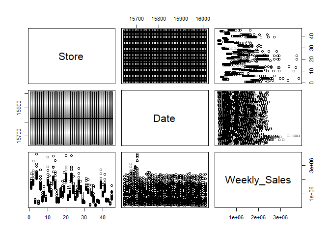

```r
plot(predictedSales)
```

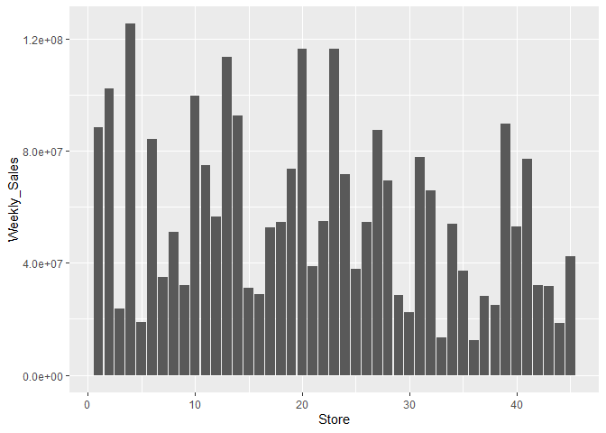

```r
p1 <- ggplot() +
    geom_col(aes(y = Weekly_Sales, x = Store), data = predictedSales)
p1
```

```r
mean(output_format$Weekly_Sales)
```

```
## [1] 1089006
```

# **CONCLUSION**

Store number 4 is predicted to have the highest amount of sales (3,808,117) on 2012-12-28 and store number 36 is predicted to have the least amount of sales (1,69,337.6 ) on 2013-11-01 and the average weekly sales of all stores from 2012-11-02 to 2013-11-01 is predicted to be 1,089,006.